# Capstone Project: Create a Customer Segmentation Report for Arvato Financial Services

## Introduction

In this project, you will analyze demographics data for customers of a mail-order sales company in Germany, comparing it against demographics information for the general population. You'll use unsupervised learning techniques to perform customer segmentation, identifying the parts of the population that best describe the core customer base of the company. Then, you'll apply what you've learned on a third dataset with demographics information for targets of a marketing campaign for the company, and use a model to predict which individuals are most likely to convert into becoming customers for the company. The data that you will use has been provided by our partners at Bertelsmann Arvato Analytics, and represents a real-life data science task.

If you completed the first term of this program, you will be familiar with the first part of this project, from the unsupervised learning project. The versions of those two datasets used in this project will include many more features and has not been pre-cleaned. You are also free to choose whatever approach you'd like to analyzing the data rather than follow pre-determined steps. In your work on this project, make sure that you carefully document your steps and decisions, since your main deliverable for this project will be a blog post reporting your findings.

```python
# import libraries here; add more as necessary
import numpy as np
import pandas as pd
import matplotlib.pyplot as plt
import seaborn as sns
import pickle
import time
from sklearn.preprocessing import Imputer, StandardScaler
from sklearn.decomposition import PCA
from sklearn.cluster import KMeans
from collections import Counter
from operator import itemgetter
from sklearn.metrics import roc_curve
from sklearn.model_selection import GridSearchCV
from sklearn.linear_model import LogisticRegression
from sklearn.ensemble import BaggingClassifier
from sklearn.ensemble import RandomForestClassifier
from sklearn.ensemble import AdaBoostClassifier
from sklearn.ensemble import GradientBoostingClassifier
from sklearn.svm import SVC

# magic word for producing visualizations in notebook
%matplotlib inline
```

## Part 0: Get to Know the Data

Each row of the demographics files represents a single person, but also includes information outside of individuals, including information about their household, building, and neighborhood. Use the information from the first two files to figure out how customers ("CUSTOMERS") are similar to or differ from the general population at large ("AZDIAS"), then use your analysis to make predictions on the other two files ("MAILOUT"), predicting which recipients are most likely to become a customer for the mail-order company.

The "CUSTOMERS" file contains three extra columns ('CUSTOMER_GROUP', 'ONLINE_PURCHASE', and 'PRODUCT_GROUP'), which provide broad information about the customers depicted in the file. The original "MAILOUT" file included one additional column, "RESPONSE", which indicated whether or not each recipient became a customer of the company. For the "TRAIN" subset, this column has been retained, but in the "TEST" subset it has been removed; it is against that withheld column that your final predictions will be assessed in the Kaggle competition.

Otherwise, all of the remaining columns are the same between the three data files. For more information about the columns depicted in the files, you can refer to two Excel spreadsheets provided in the workspace. One of them is a top-level list of attributes and descriptions, organized by informational category. The other is a detailed mapping of data values for each feature in alphabetical order.

In the below cell, we've provided some initial code to load in the first two datasets. Note for all of the `.csv` data files in this project that they're semicolon (`;`) delimited, so an additional argument in the [`read_csv()`](https://pandas.pydata.org/pandas-docs/stable/generated/pandas.read_csv.html) call has been included to read in the data properly. Also, considering the size of the datasets, it may take some time for them to load completely.

You'll notice when the data is loaded in that a warning message will immediately pop up. Before you really start digging into the modeling and analysis, you're going to need to perform some cleaning. Take some time to browse the structure of the data and look over the informational spreadsheets to understand the data values. Make some decisions on which features to keep, which features to drop, and if any revisions need to be made on data formats. It'll be a good idea to create a function with pre-processing steps, since you'll need to clean all of the datasets before you work with them.

### Step 0: Load the Data

```python
# load in the data
azdias = pd.read_csv('../../data/Term2/capstone/arvato_data/Udacity_AZDIAS_052018.csv', sep=';')
customers = pd.read_csv('../../data/Term2/capstone/arvato_data/Udacity_CUSTOMERS_052018.csv', sep=';')
```

```
/opt/conda/lib/python3.6/site-packages/IPython/core/interactiveshell.py:2785: DtypeWarning: Columns (18,19) have mixed types. Specify dtype option on import or set low_memory=False.
  interactivity=interactivity, compiler=compiler, result=result)
```

```python
# copy the data frame
azdias_clean = azdias.copy()
```

```python
# view the first 5th rows
azdias_clean.head()
```

|  | LNR | AGER_TYP | AKT_DAT_KL | ALTER_HH | ALTER_KIND1 | ALTER_KIND2 | ALTER_KIND3 | ALTER_KIND4 | ALTERSKATEGORIE_FEIN | ANZ_HAUSHALTE_AKTIV | ... | VHN | VK_DHT4A | VK_DISTANZ | VK_ZG11 | W_KEIT_KIND_HH | WOHNDAUER_2008 | WOHNLAGE | ZABEOTYP | ANREDE_KZ | ALTERSKATEGORIE_GROB |
| --- | --- | --- | --- | --- | --- | --- | --- | --- | --- | --- | --- | --- | --- | --- | --- | --- | --- | --- | --- | --- | --- |
| 0 | 910215 | -1 | NaN | NaN | NaN | NaN | NaN | NaN | NaN | NaN | ... | NaN | NaN | NaN | NaN | NaN | NaN | NaN | 3 | 1 | 2 |
| 1 | 910220 | -1 | 9.0 | 0.0 | NaN | NaN | NaN | NaN | 21.0 | 11.0 | ... | 4.0 | 8.0 | 11.0 | 10.0 | 3.0 | 9.0 | 4.0 | 5 | 2 | 1 |
| 2 | 910225 | -1 | 9.0 | 17.0 | NaN | NaN | NaN | NaN | 17.0 | 10.0 | ... | 2.0 | 9.0 | 9.0 | 6.0 | 3.0 | 9.0 | 2.0 | 5 | 2 | 3 |
| 3 | 910226 | 2 | 1.0 | 13.0 | NaN | NaN | NaN | NaN | 13.0 | 1.0 | ... | 0.0 | 7.0 | 10.0 | 11.0 | NaN | 9.0 | 7.0 | 3 | 2 | 4 |
| 4 | 910241 | -1 | 1.0 | 20.0 | NaN | NaN | NaN | NaN | 14.0 | 3.0 | ... | 2.0 | 3.0 | 5.0 | 4.0 | 2.0 | 9.0 | 3.0 | 4 | 1 | 3 |

5 rows × 366 columns

```python
# number of azdias rows' and columns'
azdias_clean.shape
```

```
(891221, 366)
```

```python
# Generate descriptive statistics that summarize the azdias dataframe
azdias_clean.describe()
```

|  | LNR | AGER_TYP | AKT_DAT_KL | ALTER_HH | ALTER_KIND1 | ALTER_KIND2 | ALTER_KIND3 | ALTER_KIND4 | ALTERSKATEGORIE_FEIN | ANZ_HAUSHALTE_AKTIV | ... | VHN | VK_DHT4A | VK_DISTANZ | VK_ZG11 | W_KEIT_KIND_HH | WOHNDAUER_2008 | WOHNLAGE | ZABEOTYP | ANREDE_KZ | ALTERSKATEGORIE_GROB |
| --- | --- | --- | --- | --- | --- | --- | --- | --- | --- | --- | --- | --- | --- | --- | --- | --- | --- | --- | --- | --- | --- |
| count | 8.912210e+05 | 891221.000000 | 817722.000000 | 817722.000000 | 81058.000000 | 29499.000000 | 6170.000000 | 1205.000000 | 628274.000000 | 798073.000000 | ... | 770025.000000 | 815304.000000 | 815304.000000 | 815304.000000 | 783619.000000 | 817722.000000 | 798073.000000 | 891221.000000 | 891221.000000 | 891221.000000 |
| mean | 6.372630e+05 | -0.358435 | 4.421928 | 10.864126 | 11.745392 | 13.402658 | 14.476013 | 15.089627 | 13.700717 | 8.287263 | ... | 2.417322 | 6.001214 | 7.532130 | 5.945972 | 3.933406 | 7.908791 | 4.052836 | 3.362438 | 1.522098 | 2.777398 |
| std | 2.572735e+05 | 1.198724 | 3.638805 | 7.639683 | 4.097660 | 3.243300 | 2.712427 | 2.452932 | 5.079849 | 15.628087 | ... | 1.166572 | 2.856091 | 3.247789 | 2.771464 | 1.964701 | 1.923137 | 1.949539 | 1.352704 | 0.499512 | 1.068775 |
| min | 1.916530e+05 | -1.000000 | 1.000000 | 0.000000 | 2.000000 | 2.000000 | 4.000000 | 7.000000 | 0.000000 | 0.000000 | ... | 0.000000 | 1.000000 | 1.000000 | 1.000000 | 0.000000 | 1.000000 | 0.000000 | 1.000000 | 1.000000 | 1.000000 |
| 25% | 4.144580e+05 | -1.000000 | 1.000000 | 0.000000 | 8.000000 | 11.000000 | 13.000000 | 14.000000 | 11.000000 | 1.000000 | ... | 2.000000 | 3.000000 | 5.000000 | 4.000000 | 2.000000 | 8.000000 | 3.000000 | 3.000000 | 1.000000 | 2.000000 |
| 50% | 6.372630e+05 | -1.000000 | 3.000000 | 13.000000 | 12.000000 | 14.000000 | 15.000000 | 15.000000 | 14.000000 | 4.000000 | ... | 2.000000 | 6.000000 | 8.000000 | 6.000000 | 4.000000 | 9.000000 | 3.000000 | 3.000000 | 2.000000 | 3.000000 |
| 75% | 8.600680e+05 | -1.000000 | 9.000000 | 17.000000 | 15.000000 | 16.000000 | 17.000000 | 17.000000 | 17.000000 | 9.000000 | ... | 3.000000 | 9.000000 | 10.000000 | 8.000000 | 6.000000 | 9.000000 | 5.000000 | 4.000000 | 2.000000 | 4.000000 |
| max | 1.082873e+06 | 3.000000 | 9.000000 | 21.000000 | 18.000000 | 18.000000 | 18.000000 | 18.000000 | 25.000000 | 595.000000 | ... | 4.000000 | 11.000000 | 13.000000 | 11.000000 | 6.000000 | 9.000000 | 8.000000 | 6.000000 | 2.000000 | 9.000000 |

8 rows × 360 columns

```python
# print the data types for each column
azdias_clean.dtypes
```

```
LNR                             int64
AGER_TYP                        int64
AKT_DAT_KL                    float64
ALTER_HH                      float64
ALTER_KIND1                   float64
ALTER_KIND2                   float64
ALTER_KIND3                   float64
ALTER_KIND4                   float64
ALTERSKATEGORIE_FEIN          float64
ANZ_HAUSHALTE_AKTIV           float64
ANZ_HH_TITEL                  float64
ANZ_KINDER                    float64
ANZ_PERSONEN                  float64
ANZ_STATISTISCHE_HAUSHALTE    float64
ANZ_TITEL                     float64
ARBEIT                        float64
BALLRAUM                      float64
CAMEO_DEU_2015                 object
CAMEO_DEUG_2015                object
CAMEO_INTL_2015                object
CJT_GESAMTTYP                 float64
CJT_KATALOGNUTZER             float64
CJT_TYP_1                     float64
CJT_TYP_2                     float64
CJT_TYP_3                     float64
CJT_TYP_4                     float64
CJT_TYP_5                     float64
CJT_TYP_6                     float64
D19_BANKEN_ANZ_12               int64
D19_BANKEN_ANZ_24               int64
                               ...
SEMIO_KRIT                      int64
SEMIO_KULT                      int64
SEMIO_LUST                      int64
SEMIO_MAT                       int64
SEMIO_PFLICHT                   int64
SEMIO_RAT                       int64
SEMIO_REL                       int64
SEMIO_SOZ                       int64
SEMIO_TRADV                     int64
SEMIO_VERT                      int64
SHOPPER_TYP                     int64
SOHO_KZ                       float64
STRUKTURTYP                   float64
TITEL_KZ                      float64
UMFELD_ALT                    float64
UMFELD_JUNG                   float64
UNGLEICHENN_FLAG              float64
VERDICHTUNGSRAUM              float64
VERS_TYP                        int64
VHA                           float64
VHN                           float64
VK_DHT4A                      float64
VK_DISTANZ                    float64
VK_ZG11                       float64
W_KEIT_KIND_HH                float64
WOHNDAUER_2008                float64
WOHNLAGE                      float64
ZABEOTYP                        int64
ANREDE_KZ                       int64
ALTERSKATEGORIE_GROB            int64
Length: 366, dtype: object
```

```python
# Convert ints to floats
def convert_int_to_float(df):
    for col in df.columns:
        if df[col].dtype == np.int64:
            df[col] = df[col].astype(np.float64)
    return df

azdias_clean = convert_int_to_float(azdias_clean)
```

## Step 1: Preprocessing

### Step 1.1: Assess Missing Data

The 'DIAS Attributes - Values 2017.xlsx' file contains a summary of properties for each demographics data column. we will use this file to help us make cleaning decisions during this stage of the project. First of all, we should assess the demographics data in terms of missing data.

```python
# Load the feature information
feat_info = pd.read_excel('./DIAS Attributes - Values 2017.xlsx')
feat_info
```

|  | Unnamed: 0 | Attribute | Description | Value | Meaning |
| --- | --- | --- | --- | --- | --- |
| 0 | NaN | AGER_TYP | best-ager typology | -1 | unknown |
| 1 | NaN | NaN | NaN | 0 | no classification possible |
| 2 | NaN | NaN | NaN | 1 | passive elderly |
| 3 | NaN | NaN | NaN | 2 | cultural elderly |
| 4 | NaN | NaN | NaN | 3 | experience-driven elderly |
| 5 | NaN | ALTERSKATEGORIE_GROB | age classification through prename analysis | -1, 0 | unknown |
| 6 | NaN | NaN | NaN | 1 | < 30 years |
| 7 | NaN | NaN | NaN | 2 | 30 - 45 years |
| 8 | NaN | NaN | NaN | 3 | 46 - 60 years |
| 9 | NaN | NaN | NaN | 4 | > 60 years |
| 10 | NaN | NaN | NaN | 9 | uniformly distributed |
| 11 | NaN | ALTER_HH | main age within the household | 0 | unknown / no main age detectable |
| 12 | NaN | NaN | NaN | 1 | 01.01.1895 bis 31.12.1899 |
| 13 | NaN | NaN | NaN | 2 | 01.01.1900 bis 31.12.1904 |
| 14 | NaN | NaN | NaN | 3 | 01.01.1905 bis 31.12.1909 |
| 15 | NaN | NaN | NaN | 4 | 01.01.1910 bis 31.12.1914 |
| 16 | NaN | NaN | NaN | 5 | 01.01.1915 bis 31.12.1919 |
| 17 | NaN | NaN | NaN | 6 | 01.01.1920 bis 31.12.1924 |
| 18 | NaN | NaN | NaN | 7 | 01.01.1925 bis 31.12.1929 |
| 19 | NaN | NaN | NaN | 8 | 01.01.1930 bis 31.12.1934 |
| 20 | NaN | NaN | NaN | 9 | 01.01.1935 bis 31.12.1939 |
| 21 | NaN | NaN | NaN | 10 | 01.01.1940 bis 31.12.1944 |
| 22 | NaN | NaN | NaN | 11 | 01.01.1945 bis 31.12.1949 |
| 23 | NaN | NaN | NaN | 12 | 01.01.1950 bis 31.12.1954 |
| 24 | NaN | NaN | NaN | 13 | 01.01.1955 bis 31.12.1959 |
| 25 | NaN | NaN | NaN | 14 | 01.01.1960 bis 31.12.1964 |
| 26 | NaN | NaN | NaN | 15 | 01.01.1965 bis 31.12.1969 |
| 27 | NaN | NaN | NaN | 16 | 01.01.1970 bis 31.12.1974 |
| 28 | NaN | NaN | NaN | 17 | 01.01.1975 bis 31.12.1979 |
| 29 | NaN | NaN | NaN | 18 | 01.01.1980 bis 31.12.1984 |
| ... | ... | ... | ... | ... | ... |
| 2228 | NaN | NaN | NaN | 9 | length of residence more than 10 years |
| 2229 | NaN | WOHNLAGE | residential-area | -1 | unknown |
| 2230 | NaN | NaN | NaN | 0 | no score calculated |
| 2231 | NaN | NaN | NaN | 1 | very good neighbourhood |
| 2232 | NaN | NaN | NaN | 2 | good neighbourhood |
| 2233 | NaN | NaN | NaN | 3 | average neighbourhood |
| 2234 | NaN | NaN | NaN | 4 | poor neighbourhood |
| 2235 | NaN | NaN | NaN | 5 | very poor neighbourhood |
| 2236 | NaN | NaN | NaN | 7 | rural neighbourhood |
| 2237 | NaN | NaN | NaN | 8 | new building in rural neighbourhood |
| 2238 | NaN | WACHSTUMSGEBIET_NB | growing area (population growth in the last 5 ... | -1, 0 | unknown |
| 2239 | NaN | NaN | NaN | 1 | very high influx |
| 2240 | NaN | NaN | NaN | 2 | high influx |
| 2241 | NaN | NaN | NaN | 3 | middle influx |
| 2242 | NaN | NaN | NaN | 4 | low influx |
| 2243 | NaN | NaN | NaN | 5 | development area |
| 2244 | NaN | W_KEIT_KIND_HH | likelihood of a child present in this household | -1, 0 | unknown |
| 2245 | NaN | NaN | NaN | 1 | most likely |
| 2246 | NaN | NaN | NaN | 2 | very likely |
| 2247 | NaN | NaN | NaN | 3 | likely |
| 2248 | NaN | NaN | NaN | 4 | average |
| 2249 | NaN | NaN | NaN | 5 | unlikely |
| 2250 | NaN | NaN | NaN | 6 | very unlikely |
| 2251 | NaN | ZABEOTYP | typification of energy consumers | -1, 9 | unknown |
| 2252 | NaN | NaN | NaN | 1 | green |
| 2253 | NaN | NaN | NaN | 2 | smart |
| 2254 | NaN | NaN | NaN | 3 | fair supplied |
| 2255 | NaN | NaN | NaN | 4 | price driven |
| 2256 | NaN | NaN | NaN | 5 | seeking orientation |
| 2257 | NaN | NaN | NaN | 6 | indifferent |

2258 rows × 5 columns

#### Step 1.1.1: Convert Missing Value Codes to NaNs

The fourth column of the feature attributes summary (loaded in above as `attributes_value`) documents the codes for all possible values for each coulmn with its meaning. We want missings and unknowns values for each column. While the file encodes this as a number sometimes and sometimes two number seperated be comma `,` (e.g. `-1,0`), this will get read in as a string object. we'll need to do a little bit of parsing to make use of it to identify and clean the data. Convert data that matches a 'missing' or 'unknown' value code into a numpy NaN value. we might want to see how much data takes on a 'missing' or 'unknown' code, and how much data is naturally missing, as a point of interest.

```python
# drop unknown column
feat_info.drop(['Unnamed: 0','Description'],axis=1, inplace=True)
feat_info
```

|  | Attribute | Value | Meaning |
| --- | --- | --- | --- |
| 0 | AGER_TYP | -1 | unknown |
| 1 | NaN | 0 | no classification possible |
| 2 | NaN | 1 | passive elderly |
| 3 | NaN | 2 | cultural elderly |
| 4 | NaN | 3 | experience-driven elderly |
| 5 | ALTERSKATEGORIE_GROB | -1, 0 | unknown |
| 6 | NaN | 1 | < 30 years |
| 7 | NaN | 2 | 30 - 45 years |
| 8 | NaN | 3 | 46 - 60 years |
| 9 | NaN | 4 | > 60 years |
| 10 | NaN | 9 | uniformly distributed |
| 11 | ALTER_HH | 0 | unknown / no main age detectable |
| 12 | NaN | 1 | 01.01.1895 bis 31.12.1899 |
| 13 | NaN | 2 | 01.01.1900 bis 31.12.1904 |
| 14 | NaN | 3 | 01.01.1905 bis 31.12.1909 |
| 15 | NaN | 4 | 01.01.1910 bis 31.12.1914 |
| 16 | NaN | 5 | 01.01.1915 bis 31.12.1919 |
| 17 | NaN | 6 | 01.01.1920 bis 31.12.1924 |
| 18 | NaN | 7 | 01.01.1925 bis 31.12.1929 |
| 19 | NaN | 8 | 01.01.1930 bis 31.12.1934 |
| 20 | NaN | 9 | 01.01.1935 bis 31.12.1939 |
| 21 | NaN | 10 | 01.01.1940 bis 31.12.1944 |
| 22 | NaN | 11 | 01.01.1945 bis 31.12.1949 |
| 23 | NaN | 12 | 01.01.1950 bis 31.12.1954 |
| 24 | NaN | 13 | 01.01.1955 bis 31.12.1959 |
| 25 | NaN | 14 | 01.01.1960 bis 31.12.1964 |
| 26 | NaN | 15 | 01.01.1965 bis 31.12.1969 |
| 27 | NaN | 16 | 01.01.1970 bis 31.12.1974 |
| 28 | NaN | 17 | 01.01.1975 bis 31.12.1979 |
| 29 | NaN | 18 | 01.01.1980 bis 31.12.1984 |
| ... | ... | ... | ... |
| 2228 | NaN | 9 | length of residence more than 10 years |
| 2229 | WOHNLAGE | -1 | unknown |
| 2230 | NaN | 0 | no score calculated |
| 2231 | NaN | 1 | very good neighbourhood |
| 2232 | NaN | 2 | good neighbourhood |
| 2233 | NaN | 3 | average neighbourhood |
| 2234 | NaN | 4 | poor neighbourhood |
| 2235 | NaN | 5 | very poor neighbourhood |
| 2236 | NaN | 7 | rural neighbourhood |
| 2237 | NaN | 8 | new building in rural neighbourhood |
| 2238 | WACHSTUMSGEBIET_NB | -1, 0 | unknown |
| 2239 | NaN | 1 | very high influx |
| 2240 | NaN | 2 | high influx |
| 2241 | NaN | 3 | middle influx |
| 2242 | NaN | 4 | low influx |
| 2243 | NaN | 5 | development area |
| 2244 | W_KEIT_KIND_HH | -1, 0 | unknown |
| 2245 | NaN | 1 | most likely |
| 2246 | NaN | 2 | very likely |
| 2247 | NaN | 3 | likely |
| 2248 | NaN | 4 | average |
| 2249 | NaN | 5 | unlikely |
| 2250 | NaN | 6 | very unlikely |
| 2251 | ZABEOTYP | -1, 9 | unknown |
| 2252 | NaN | 1 | green |
| 2253 | NaN | 2 | smart |
| 2254 | NaN | 3 | fair supplied |
| 2255 | NaN | 4 | price driven |
| 2256 | NaN | 5 | seeking orientation |
| 2257 | NaN | 6 | indifferent |

2258 rows × 3 columns

```python
# replace NaNs by using preceding technique
feat_info['Attribute'].fillna(method='ffill', inplace=True)
feat_info
```

|  | Attribute | Value | Meaning |
| --- | --- | --- | --- |
| 0 | AGER_TYP | -1 | unknown |
| 1 | AGER_TYP | 0 | no classification possible |
| 2 | AGER_TYP | 1 | passive elderly |
| 3 | AGER_TYP | 2 | cultural elderly |
| 4 | AGER_TYP | 3 | experience-driven elderly |
| 5 | ALTERSKATEGORIE_GROB | -1, 0 | unknown |
| 6 | ALTERSKATEGORIE_GROB | 1 | < 30 years |
| 7 | ALTERSKATEGORIE_GROB | 2 | 30 - 45 years |
| 8 | ALTERSKATEGORIE_GROB | 3 | 46 - 60 years |
| 9 | ALTERSKATEGORIE_GROB | 4 | > 60 years |
| 10 | ALTERSKATEGORIE_GROB | 9 | uniformly distributed |
| 11 | ALTER_HH | 0 | unknown / no main age detectable |
| 12 | ALTER_HH | 1 | 01.01.1895 bis 31.12.1899 |
| 13 | ALTER_HH | 2 | 01.01.1900 bis 31.12.1904 |
| 14 | ALTER_HH | 3 | 01.01.1905 bis 31.12.1909 |
| 15 | ALTER_HH | 4 | 01.01.1910 bis 31.12.1914 |
| 16 | ALTER_HH | 5 | 01.01.1915 bis 31.12.1919 |
| 17 | ALTER_HH | 6 | 01.01.1920 bis 31.12.1924 |
| 18 | ALTER_HH | 7 | 01.01.1925 bis 31.12.1929 |
| 19 | ALTER_HH | 8 | 01.01.1930 bis 31.12.1934 |
| 20 | ALTER_HH | 9 | 01.01.1935 bis 31.12.1939 |
| 21 | ALTER_HH | 10 | 01.01.1940 bis 31.12.1944 |
| 22 | ALTER_HH | 11 | 01.01.1945 bis 31.12.1949 |
| 23 | ALTER_HH | 12 | 01.01.1950 bis 31.12.1954 |
| 24 | ALTER_HH | 13 | 01.01.1955 bis 31.12.1959 |
| 25 | ALTER_HH | 14 | 01.01.1960 bis 31.12.1964 |
| 26 | ALTER_HH | 15 | 01.01.1965 bis 31.12.1969 |
| 27 | ALTER_HH | 16 | 01.01.1970 bis 31.12.1974 |
| 28 | ALTER_HH | 17 | 01.01.1975 bis 31.12.1979 |
| 29 | ALTER_HH | 18 | 01.01.1980 bis 31.12.1984 |
| ... | ... | ... | ... |
| 2228 | WOHNDAUER_2008 | 9 | length of residence more than 10 years |
| 2229 | WOHNLAGE | -1 | unknown |
| 2230 | WOHNLAGE | 0 | no score calculated |
| 2231 | WOHNLAGE | 1 | very good neighbourhood |
| 2232 | WOHNLAGE | 2 | good neighbourhood |
| 2233 | WOHNLAGE | 3 | average neighbourhood |
| 2234 | WOHNLAGE | 4 | poor neighbourhood |
| 2235 | WOHNLAGE | 5 | very poor neighbourhood |
| 2236 | WOHNLAGE | 7 | rural neighbourhood |
| 2237 | WOHNLAGE | 8 | new building in rural neighbourhood |
| 2238 | WACHSTUMSGEBIET_NB | -1, 0 | unknown |
| 2239 | WACHSTUMSGEBIET_NB | 1 | very high influx |
| 2240 | WACHSTUMSGEBIET_NB | 2 | high influx |
| 2241 | WACHSTUMSGEBIET_NB | 3 | middle influx |
| 2242 | WACHSTUMSGEBIET_NB | 4 | low influx |
| 2243 | WACHSTUMSGEBIET_NB | 5 | development area |
| 2244 | W_KEIT_KIND_HH | -1, 0 | unknown |
| 2245 | W_KEIT_KIND_HH | 1 | most likely |
| 2246 | W_KEIT_KIND_HH | 2 | very likely |
| 2247 | W_KEIT_KIND_HH | 3 | likely |
| 2248 | W_KEIT_KIND_HH | 4 | average |
| 2249 | W_KEIT_KIND_HH | 5 | unlikely |
| 2250 | W_KEIT_KIND_HH | 6 | very unlikely |
| 2251 | ZABEOTYP | -1, 9 | unknown |
| 2252 | ZABEOTYP | 1 | green |
| 2253 | ZABEOTYP | 2 | smart |
| 2254 | ZABEOTYP | 3 | fair supplied |
| 2255 | ZABEOTYP | 4 | price driven |
| 2256 | ZABEOTYP | 5 | seeking orientation |
| 2257 | ZABEOTYP | 6 | indifferent |

2258 rows × 3 columns

```python
# finding missings, Unknown and no values
def search(df, *words):
    """
    Return a sub-DataFrame of those rows whose Meaning column match all the words.
    """
    return df[np.logical_or.reduce([df['Meaning'].str.contains(word, na=False) for word in words])]

feat_info = search(feat_info, 'unknown', 'no ')
print(feat_info.Meaning.tolist())
```

```
['unknown', 'no classification possible', 'unknown', 'unknown / no main age detectable', 'unknown', 'unknown', 'unknown', 'no company in the building', 'unknown', 'unknown', 'unknown', 'no transactions known', 'no transactions known', 'no transactions known', 'no transaction known', 'no transaction …
```

```python
feat_info
```

|  | Attribute | Value | Meaning |
| --- | --- | --- | --- |
| 0 | AGER_TYP | -1 | unknown |
| 1 | AGER_TYP | 0 | no classification possible |
| 5 | ALTERSKATEGORIE_GROB | -1, 0 | unknown |
| 11 | ALTER_HH | 0 | unknown / no main age detectable |
| 33 | ANREDE_KZ | -1, 0 | unknown |
| 40 | BALLRAUM | -1 | unknown |
| 48 | BIP_FLAG | -1 | unknown |
| 49 | BIP_FLAG | 0 | no company in the building |
| 51 | CAMEO_DEUG_2015 | -1 | unknown |
| 105 | CAMEO_DEUINTL_2015 | -1 | unknown |
| 131 | CJT_GESAMTTYP | 0 | unknown |
| 138 | D19_BANKEN_ANZ_12 | 0 | no transactions known |
| 145 | D19_BANKEN_ANZ_24 | 0 | no transactions known |
| 161 | D19_BANKEN_DATUM | 10 | no transactions known |
| 162 | D19_BANKEN_DIREKT_RZ | 0 | no transaction known |
| 170 | D19_BANKEN_GROSS_RZ | 0 | no transaction known |
| 178 | D19_BANKEN_LOKAL_RZ | 0 | no transaction known |
| 195 | D19_BANKEN_OFFLINE_DATUM | 10 | no transactions known |
| 205 | D19_BANKEN_ONLINE_DATUM | 10 | no transactions known |
| 206 | D19_BANKEN_ONLINE_QUOTE_12 | 0 | no Online-transactions within the last 12 months |
| 217 | D19_BANKEN_REST_RZ | 0 | no transaction known |
| 225 | D19_BEKLEIDUNG_GEH_RZ | 0 | no transaction known |
| 233 | D19_BEKLEIDUNG_REST_RZ | 0 | no transaction known |
| 241 | D19_BILDUNG_RZ | 0 | no transaction known |
| 249 | D19_BIO_OEKO_RZ | 0 | no transaction known |
| 257 | D19_BUCH_RZ | 0 | no transaction known |
| 265 | D19_DIGIT_SERV_RZ | 0 | no transaction known |
| 273 | D19_DROGERIEARTIKEL_RZ | 0 | no transaction known |
| 281 | D19_ENERGIE_RZ | 0 | no transaction known |
| 289 | D19_FREIZEIT_RZ | 0 | no transaction known |
| ... | ... | ... | ... |
| 2048 | PLZ8_HHZ | -1 | unknown |
| 2054 | PRAEGENDE_JUGENDJAHRE | -1, 0 | unknown |
| 2070 | REGIOTYP | -1, 0 | unknown |
| 2083 | RELAT_AB | -1, 9 | unknown |
| 2084 | RETOURTYP_BK_S | 0 | unknown |
| 2090 | SEMIO_DOM | -1, 9 | unknown |
| 2098 | SEMIO_ERL | -1, 9 | unknown |
| 2106 | SEMIO_FAM | -1, 9 | unknown |
| 2114 | SEMIO_KAEM | -1, 9 | unknown |
| 2122 | SEMIO_KRIT | -1, 9 | unknown |
| 2130 | SEMIO_KULT | -1, 9 | unknown |
| 2138 | SEMIO_LUST | -1, 9 | unknown |
| 2146 | SEMIO_MAT | -1, 9 | unknown |
| 2154 | SEMIO_PFLICHT | -1, 9 | unknown |
| 2162 | SEMIO_RAT | -1, 9 | unknown |
| 2170 | SEMIO_REL | -1, 9 | unknown |
| 2178 | SEMIO_SOZ | -1, 9 | unknown |
| 2186 | SEMIO_TRADV | -1, 9 | unknown |
| 2194 | SEMIO_VERT | -1, 9 | unknown |
| 2202 | SHOPPER_TYP | -1 | unknown |
| 2207 | SOHO_FLAG | -1 | unknown |
| 2208 | SOHO_FLAG | 0 | no small office/home office |
| 2210 | TITEL_KZ | -1, 0 | unknown |
| 2216 | VERS_TYP | -1 | unknown |
| 2219 | WOHNDAUER_2008 | -1, 0 | unknown |
| 2229 | WOHNLAGE | -1 | unknown |
| 2230 | WOHNLAGE | 0 | no score calculated |
| 2238 | WACHSTUMSGEBIET_NB | -1, 0 | unknown |
| 2244 | W_KEIT_KIND_HH | -1, 0 | unknown |
| 2251 | ZABEOTYP | -1, 9 | unknown |

302 rows × 3 columns

```python
# Combine all the values for the same attribute in one list
unknown = feat_info['Value'].groupby([feat_info.Attribute]).apply(list).reset_index()
```

```python
unknown
```

|  | Attribute | Value |
| --- | --- | --- |
| 0 | AGER_TYP | [-1, 0] |
| 1 | ALTERSKATEGORIE_GROB | [-1, 0] |
| 2 | ALTER_HH | [0] |
| 3 | ANREDE_KZ | [-1, 0] |
| 4 | BALLRAUM | [-1] |
| 5 | BIP_FLAG | [-1, 0] |
| 6 | CAMEO_DEUG_2015 | [-1] |
| 7 | CAMEO_DEUINTL_2015 | [-1] |
| 8 | CJT_GESAMTTYP | [0] |
| 9 | D19_BANKEN_ANZ_12 | [0] |
| 10 | D19_BANKEN_ANZ_24 | [0] |
| 11 | D19_BANKEN_DATUM | [10] |
| 12 | D19_BANKEN_DIREKT_RZ | [0] |
| 13 | D19_BANKEN_GROSS_RZ | [0] |
| 14 | D19_BANKEN_LOKAL_RZ | [0] |
| 15 | D19_BANKEN_OFFLINE_DATUM | [10] |
| 16 | D19_BANKEN_ONLINE_DATUM | [10] |
| 17 | D19_BANKEN_ONLINE_QUOTE_12 | [0] |
| 18 | D19_BANKEN_REST_RZ | [0] |
| 19 | D19_BEKLEIDUNG_GEH_RZ | [0] |
| 20 | D19_BEKLEIDUNG_REST_RZ | [0] |
| 21 | D19_BILDUNG_RZ | [0] |
| 22 | D19_BIO_OEKO_RZ | [0] |
| 23 | D19_BUCH_RZ | [0] |
| 24 | D19_DIGIT_SERV_RZ | [0] |
| 25 | D19_DROGERIEARTIKEL_RZ | [0] |
| 26 | D19_ENERGIE_RZ | [0] |
| 27 | D19_FREIZEIT_RZ | [0] |
| 28 | D19_GARTEN_RZ | [0] |
| 29 | D19_GESAMT_ANZ_12 | [0] |
| ... | ... | ... |
| 262 | PLZ8_ANTG4 | [-1] |
| 263 | PLZ8_GBZ | [-1] |
| 264 | PLZ8_HHZ | [-1] |
| 265 | PRAEGENDE_JUGENDJAHRE | [-1, 0] |
| 266 | REGIOTYP | [-1, 0] |
| 267 | RELAT_AB | [-1, 9] |
| 268 | RETOURTYP_BK_S | [0] |
| 269 | SEMIO_DOM | [-1, 9] |
| 270 | SEMIO_ERL | [-1, 9] |
| 271 | SEMIO_FAM | [-1, 9] |
| 272 | SEMIO_KAEM | [-1, 9] |
| 273 | SEMIO_KRIT | [-1, 9] |
| 274 | SEMIO_KULT | [-1, 9] |
| 275 | SEMIO_LUST | [-1, 9] |
| 276 | SEMIO_MAT | [-1, 9] |
| 277 | SEMIO_PFLICHT | [-1, 9] |
| 278 | SEMIO_RAT | [-1, 9] |
| 279 | SEMIO_REL | [-1, 9] |
| 280 | SEMIO_SOZ | [-1, 9] |
| 281 | SEMIO_TRADV | [-1, 9] |
| 282 | SEMIO_VERT | [-1, 9] |
| 283 | SHOPPER_TYP | [-1] |
| 284 | SOHO_FLAG | [-1, 0] |
| 285 | TITEL_KZ | [-1, 0] |
| 286 | VERS_TYP | [-1] |
| 287 | WACHSTUMSGEBIET_NB | [-1, 0] |
| 288 | WOHNDAUER_2008 | [-1, 0] |
| 289 | WOHNLAGE | [-1, 0] |
| 290 | W_KEIT_KIND_HH | [-1, 0] |
| 291 | ZABEOTYP | [-1, 9] |

292 rows × 2 columns

```python
# convert missing or unknown data values to NaNs.
def convert_unknown_to_NaN(df, unknown):
    feat_names = unknown.Attribute.tolist()
    for col in range(df.shape[1]):
        col_name=df.columns[col]
        if col_name in feat_names:
            nan_list=unknown.loc[unknown['Attribute'] == col_name, 'Value'].iloc[0]
            na_idx = df.loc[:, col_name].isin(nan_list)
            df.loc[na_idx, col_name] = np.NaN

    return df
azdias_clean = convert_unknown_to_NaN(azdias_clean, unknown)
```

```python
azdias_clean
```

|  | LNR | AGER_TYP | AKT_DAT_KL | ALTER_HH | ALTER_KIND1 | ALTER_KIND2 | ALTER_KIND3 | ALTER_KIND4 | ALTERSKATEGORIE_FEIN | ANZ_HAUSHALTE_AKTIV | ... | VHN | VK_DHT4A | VK_DISTANZ | VK_ZG11 | W_KEIT_KIND_HH | WOHNDAUER_2008 | WOHNLAGE | ZABEOTYP | ANREDE_KZ | ALTERSKATEGORIE_GROB |
| --- | --- | --- | --- | --- | --- | --- | --- | --- | --- | --- | --- | --- | --- | --- | --- | --- | --- | --- | --- | --- | --- |
| 0 | 910215.0 | NaN | NaN | NaN | NaN | NaN | NaN | NaN | NaN | NaN | ... | NaN | NaN | NaN | NaN | NaN | NaN | NaN | 3.0 | 1.0 | 2.0 |
| 1 | 910220.0 | NaN | 9.0 | NaN | NaN | NaN | NaN | NaN | 21.0 | 11.0 | ... | 4.0 | 8.0 | 11.0 | 10.0 | 3.0 | 9.0 | 4.0 | 5.0 | 2.0 | 1.0 |
| 2 | 910225.0 | NaN | 9.0 | 17.0 | NaN | NaN | NaN | NaN | 17.0 | 10.0 | ... | 2.0 | 9.0 | 9.0 | 6.0 | 3.0 | 9.0 | 2.0 | 5.0 | 2.0 | 3.0 |
| 3 | 910226.0 | 2.0 | 1.0 | 13.0 | NaN | NaN | NaN | NaN | 13.0 | 1.0 | ... | 0.0 | 7.0 | 10.0 | 11.0 | NaN | 9.0 | 7.0 | 3.0 | 2.0 | 4.0 |
| 4 | 910241.0 | NaN | 1.0 | 20.0 | NaN | NaN | NaN | NaN | 14.0 | 3.0 | ... | 2.0 | 3.0 | 5.0 | 4.0 | 2.0 | 9.0 | 3.0 | 4.0 | 1.0 | 3.0 |
| 5 | 910244.0 | 3.0 | 1.0 | 10.0 | NaN | NaN | NaN | NaN | 10.0 | 5.0 | ... | 2.0 | 10.0 | 7.0 | 4.0 | 6.0 | 9.0 | 7.0 | 4.0 | 2.0 | 1.0 |
| 6 | 910248.0 | NaN | 9.0 | NaN | NaN | NaN | NaN | NaN | NaN | 4.0 | ... | 2.0 | 7.0 | 10.0 | 10.0 | 3.0 | 9.0 | 5.0 | 4.0 | 2.0 | 2.0 |
| 7 | 910261.0 | NaN | 1.0 | 14.0 | NaN | NaN | NaN | NaN | 14.0 | 6.0 | ... | 2.0 | 10.0 | 12.0 | 9.0 | 5.0 | 9.0 | 1.0 | 1.0 | 1.0 | 1.0 |
| 8 | 645145.0 | NaN | 9.0 | 16.0 | NaN | NaN | NaN | NaN | 16.0 | 2.0 | ... | 4.0 | 8.0 | 11.0 | 8.0 | 5.0 | 8.0 | 1.0 | 6.0 | 1.0 | 3.0 |
| 9 | 645153.0 | NaN | 5.0 | 17.0 | NaN | NaN | NaN | NaN | 17.0 | 9.0 | ... | 4.0 | 1.0 | 1.0 | 1.0 | 4.0 | 3.0 | 7.0 | 4.0 | 2.0 | 3.0 |
| 10 | 645165.0 | NaN | 1.0 | 10.0 | NaN | NaN | NaN | NaN | 10.0 | 6.0 | ... | 4.0 | 8.0 | 11.0 | 10.0 | 6.0 | 9.0 | 5.0 | 3.0 | 2.0 | 3.0 |
| 11 | 645169.0 | NaN | NaN | NaN | NaN | NaN | NaN | NaN | NaN | NaN | ... | NaN | NaN | NaN | NaN | NaN | NaN | NaN | 3.0 | 1.0 | 2.0 |
| 12 | 612558.0 | NaN | 5.0 | 21.0 | NaN | NaN | NaN | NaN | 14.0 | 1.0 | ... | 4.0 | 3.0 | 5.0 | 3.0 | 6.0 | 4.0 | 3.0 | 1.0 | 1.0 | 3.0 |
| 13 | 612561.0 | NaN | 8.0 | 20.0 | NaN | NaN | NaN | NaN | 20.0 | 2.0 | ... | NaN | 3.0 | 6.0 | 8.0 | 6.0 | 3.0 | 5.0 | 5.0 | 2.0 | 1.0 |
| 14 | 612565.0 | NaN | NaN | NaN | NaN | NaN | NaN | NaN | NaN | NaN | ... | NaN | NaN | NaN | NaN | NaN | NaN | NaN | 3.0 | 1.0 | 3.0 |
| 15 | 612569.0 | 1.0 | 9.0 | 11.0 | NaN | NaN | NaN | NaN | 11.0 | 1.0 | ... | 4.0 | 6.0 | 6.0 | 3.0 | 6.0 | 4.0 | 3.0 | 3.0 | 2.0 | 4.0 |
| 16 | 612574.0 | NaN | 1.0 | 19.0 | NaN | NaN | NaN | NaN | 19.0 | 0.0 | ... | 1.0 | 6.0 | 9.0 | 8.0 | NaN | 3.0 | 7.0 | 5.0 | 2.0 | 1.0 |
| 17 | 612577.0 | NaN | NaN | NaN | NaN | NaN | NaN | NaN | NaN | NaN | ... | NaN | NaN | NaN | NaN | NaN | NaN | NaN | 3.0 | 1.0 | 2.0 |
| 18 | 612586.0 | NaN | 9.0 | NaN | NaN | NaN | NaN | NaN | NaN | 2.0 | ... | 0.0 | 8.0 | 11.0 | 10.0 | 0.0 | 5.0 | 2.0 | 4.0 | 2.0 | 2.0 |
| 19 | 612592.0 | NaN | 9.0 | NaN | NaN | NaN | NaN | NaN | NaN | 1.0 | ... | 4.0 | 8.0 | 9.0 | 6.0 | 5.0 | 6.0 | 1.0 | 2.0 | 1.0 | 3.0 |
| 20 | 612594.0 | NaN | 7.0 | NaN | NaN | NaN | NaN | NaN | NaN | 1.0 | ... | NaN | 8.0 | 11.0 | 10.0 | 3.0 | 4.0 | 5.0 | 3.0 | 2.0 | 2.0 |
| 21 | 612595.0 | NaN | 9.0 | NaN | NaN | NaN | NaN | NaN | NaN | 2.0 | ... | 2.0 | 9.0 | 11.0 | 8.0 | 5.0 | 9.0 | 4.0 | 4.0 | 1.0 | 2.0 |
| 22 | 612606.0 | NaN | 8.0 | NaN | NaN | NaN | NaN | NaN | NaN | 14.0 | ... | 4.0 | 6.0 | 9.0 | 7.0 | 6.0 | 4.0 | 4.0 | 4.0 | 1.0 | 1.0 |
| 23 | 612609.0 | NaN | 6.0 | 16.0 | NaN | NaN | NaN | NaN | NaN | 1.0 | ... | 2.0 | 3.0 | 6.0 | 8.0 | 3.0 | 2.0 | 3.0 | 4.0 | 1.0 | 3.0 |
| 24 | 703164.0 | NaN | NaN | NaN | NaN | NaN | NaN | NaN | NaN | NaN | ... | NaN | NaN | NaN | NaN | NaN | NaN | NaN | 3.0 | 2.0 | 3.0 |
| 25 | 703182.0 | NaN | 1.0 | 20.0 | NaN | NaN | NaN | NaN | 20.0 | 1.0 | ... | 2.0 | 6.0 | 9.0 | 7.0 | NaN | 3.0 | 7.0 | 5.0 | 1.0 | 1.0 |
| 26 | 714262.0 | NaN | 1.0 | NaN | NaN | NaN | NaN | NaN | NaN | 1.0 | ... | NaN | 7.0 | 9.0 | 6.0 | 3.0 | 3.0 | 7.0 | 1.0 | 1.0 | 3.0 |
| 27 | 714263.0 | NaN | 6.0 | 16.0 | 17.0 | NaN | NaN | NaN | 16.0 | 6.0 | ... | 3.0 | 4.0 | 7.0 | 5.0 | 1.0 | 3.0 | 3.0 | 4.0 | 1.0 | 3.0 |
| 28 | 714265.0 | NaN | 9.0 | 15.0 | NaN | NaN | NaN | NaN | 15.0 | 3.0 | ... | 3.0 | 8.0 | 11.0 | 8.0 | 5.0 | 8.0 | 5.0 | 6.0 | 1.0 | 3.0 |
| 29 | 714278.0 | 2.0 | 1.0 | 11.0 | NaN | NaN | NaN | NaN | 11.0 | 1.0 | ... | 0.0 | 9.0 | 12.0 | 9.0 | 6.0 | 8.0 | 3.0 | 1.0 | 2.0 | 4.0 |
| ... | ... | ... | ... | ... | ... | ... | ... | ... | ... | ... | ... | ... | ... | ... | ... | ... | ... | ... | ... | ... | ... |
| 891191 | 380331.0 | 1.0 | 1.0 | 10.0 | NaN | NaN | NaN | NaN | 10.0 | 3.0 | ... | 3.0 | 1.0 | 2.0 | 1.0 | 6.0 | 8.0 | 7.0 | 3.0 | 2.0 | 4.0 |
| 891192 | 706687.0 | NaN | 9.0 | 20.0 | NaN | NaN | NaN | NaN | NaN | 6.0 | ... | 4.0 | 8.0 | 11.0 | 9.0 | 6.0 | 9.0 | 5.0 | 4.0 | 2.0 | 1.0 |
| 891193 | 706689.0 | 2.0 | 1.0 | 13.0 | NaN | NaN | NaN | NaN | 11.0 | 6.0 | ... | 2.0 | 5.0 | 7.0 | 4.0 | 4.0 | 9.0 | 5.0 | 4.0 | 1.0 | 4.0 |
| 891194 | 706692.0 | NaN | 1.0 | 15.0 | NaN | NaN | NaN | NaN | 15.0 | 2.0 | ... | 2.0 | 3.0 | 5.0 | 3.0 | 4.0 | 9.0 | 2.0 | 4.0 | 1.0 | 3.0 |
| 891195 | 706733.0 | 2.0 | 1.0 | NaN | NaN | NaN | NaN | NaN | 13.0 | 9.0 | ... | 1.0 | 3.0 | 5.0 | 3.0 | 3.0 | 9.0 | 2.0 | 3.0 | 2.0 | 4.0 |
| 891196 | 706754.0 | NaN | 1.0 | 17.0 | 10.0 | 15.0 | NaN | NaN | 17.0 | 8.0 | ... | 4.0 | 3.0 | 6.0 | 6.0 | 1.0 | 8.0 | 4.0 | 4.0 | 2.0 | 2.0 |
| 891197 | 706768.0 | NaN | 1.0 | 15.0 | NaN | NaN | NaN | NaN | 15.0 | 3.0 | ... | 3.0 | 5.0 | 8.0 | 9.0 | 4.0 | 9.0 | 2.0 | 4.0 | 2.0 | 3.0 |
| 891198 | 714930.0 | NaN | 9.0 | 20.0 | NaN | NaN | NaN | NaN | 20.0 | 1.0 | ... | 1.0 | 7.0 | 9.0 | 6.0 | 6.0 | 9.0 | 3.0 | 4.0 | 1.0 | 3.0 |
| 891199 | 814493.0 | NaN | 9.0 | NaN | NaN | NaN | NaN | NaN | NaN | 13.0 | ... | 3.0 | 9.0 | 12.0 | 9.0 | 5.0 | 9.0 | 4.0 | 4.0 | 1.0 | 2.0 |
| 891200 | 814520.0 | NaN | 9.0 | 18.0 | NaN | NaN | NaN | NaN | NaN | 12.0 | ... | 1.0 | 6.0 | 9.0 | 6.0 | 2.0 | 9.0 | 4.0 | 4.0 | 2.0 | 1.0 |
| 891201 | 814532.0 | NaN | 1.0 | 16.0 | NaN | NaN | NaN | NaN | 16.0 | 11.0 | ... | 1.0 | 5.0 | 8.0 | 6.0 | 4.0 | 9.0 | 3.0 | 4.0 | 1.0 | 3.0 |
| 891202 | 814546.0 | NaN | 1.0 | NaN | NaN | NaN | NaN | NaN | NaN | 20.0 | ... | 3.0 | 5.0 | 8.0 | 10.0 | 4.0 | 4.0 | 4.0 | 4.0 | 2.0 | 2.0 |
| 891203 | 814549.0 | NaN | 9.0 | NaN | NaN | NaN | NaN | NaN | NaN | 19.0 | ... | NaN | 8.0 | 11.0 | 9.0 | NaN | 6.0 | 1.0 | 3.0 | 2.0 | 4.0 |
| 891204 | 814552.0 | NaN | 1.0 | 16.0 | NaN | NaN | NaN | NaN | 16.0 | 2.0 | ... | 1.0 | 4.0 | 7.0 | 6.0 | 2.0 | 9.0 | 3.0 | 1.0 | 1.0 | 3.0 |
| 891205 | 814588.0 | 1.0 | 1.0 | 10.0 | NaN | NaN | NaN | NaN | 10.0 | 4.0 | ... | 2.0 | 7.0 | 9.0 | 6.0 | 6.0 | 9.0 | 5.0 | 3.0 | 1.0 | 4.0 |
| 891206 | 825703.0 | NaN | 9.0 | 19.0 | NaN | NaN | NaN | NaN | 18.0 | 2.0 | ... | 2.0 | 10.0 | 12.0 | 9.0 | 3.0 | 9.0 | 2.0 | 5.0 | 2.0 | 1.0 |
| 891207 | 825716.0 | 1.0 | 1.0 | 8.0 | NaN | NaN | NaN | NaN | 8.0 | 2.0 | ... | 2.0 | 1.0 | 1.0 | 1.0 | 6.0 | 9.0 | 4.0 | 3.0 | 2.0 | 3.0 |
| 891208 | 825717.0 | NaN | 1.0 | 15.0 | NaN | NaN | NaN | NaN | 14.0 | 1.0 | ... | 0.0 | 5.0 | 8.0 | 11.0 | 0.0 | 9.0 | 7.0 | 1.0 | 1.0 | 4.0 |
| 891209 | 825726.0 | NaN | 9.0 | NaN | NaN | NaN | NaN | NaN | 17.0 | 4.0 | ... | 3.0 | 7.0 | 10.0 | 8.0 | 3.0 | 9.0 | 3.0 | 5.0 | 2.0 | 1.0 |
| 891210 | 825729.0 | NaN | 1.0 | NaN | NaN | NaN | NaN | NaN | NaN | 24.0 | ... | 2.0 | 6.0 | 9.0 | 6.0 | 5.0 | 2.0 | 3.0 | 3.0 | 1.0 | 3.0 |
| 891211 | 825731.0 | NaN | 9.0 | 14.0 | NaN | NaN | NaN | NaN | 14.0 | 6.0 | ... | 4.0 | 9.0 | 11.0 | 8.0 | 6.0 | 9.0 | 3.0 | 6.0 | 1.0 | 3.0 |
| 891212 | 825735.0 | NaN | 9.0 | 15.0 | NaN | NaN | NaN | NaN | NaN | 13.0 | ... | 3.0 | 10.0 | 10.0 | 7.0 | 6.0 | 8.0 | 3.0 | 3.0 | 1.0 | 4.0 |
| 891213 | 825742.0 | NaN | 1.0 | 21.0 | 17.0 | NaN | NaN | NaN | 15.0 | 4.0 | ... | 2.0 | 1.0 | 1.0 | 1.0 | 1.0 | 9.0 | 4.0 | 4.0 | 2.0 | 4.0 |
| 891214 | 825745.0 | NaN | 9.0 | 17.0 | NaN | NaN | NaN | NaN | 17.0 | 6.0 | ... | 2.0 | 9.0 | 12.0 | 10.0 | 4.0 | 9.0 | 3.0 | 5.0 | 2.0 | 1.0 |
| 891215 | 825758.0 | NaN | 9.0 | NaN | NaN | NaN | NaN | NaN | NaN | 8.0 | ... | 1.0 | 7.0 | 10.0 | 10.0 | 3.0 | 9.0 | 3.0 | 4.0 | 2.0 | 2.0 |
| 891216 | 825761.0 | NaN | 5.0 | 17.0 | NaN | NaN | NaN | NaN | 17.0 | 15.0 | ... | 2.0 | 4.0 | 7.0 | 8.0 | 3.0 | 4.0 | 3.0 | 4.0 | 2.0 | 3.0 |
| 891217 | 825771.0 | NaN | 9.0 | 16.0 | NaN | NaN | NaN | NaN | 16.0 | 11.0 | ... | 4.0 | 6.0 | 9.0 | 6.0 | 6.0 | 9.0 | 5.0 | 6.0 | 1.0 | 2.0 |
| 891218 | 825772.0 | NaN | 1.0 | 17.0 | NaN | NaN | NaN | NaN | 17.0 | 3.0 | ... | 2.0 | 7.0 | 10.0 | 8.0 | NaN | 5.0 | 7.0 | 4.0 | 2.0 | 2.0 |
| 891219 | 825776.0 | NaN | 9.0 | NaN | 17.0 | NaN | NaN | NaN | 20.0 | 7.0 | ... | 4.0 | 9.0 | 8.0 | 5.0 | 1.0 | 9.0 | 5.0 | 5.0 | 1.0 | 1.0 |
| 891220 | 825787.0 | NaN | 1.0 | NaN | NaN | NaN | NaN | NaN | NaN | 10.0 | ... | 3.0 | 8.0 | 10.0 | 7.0 | 6.0 | 3.0 | 4.0 | 3.0 | 1.0 | 4.0 |

891221 rows × 366 columns

```python
# Dump the azdias_clean dataframe to a pickle object since it takes up so much room in memory.
pickle.dump(azdias_clean, open("azdias_clean.pickle", "wb"))
```

```python
# Dump the unknown dataframe to a pickle object in case we need it later.
pickle.dump(unknown, open("unknown.pickle", "wb"))
```

#### Step 1.1.2: Assess Missing Data in Each Column

After converting missing values to NaNs value, now let's see how much missing data is present in each column? There are a few columns that are outliers in terms of the proportion of values that are missing.

```python
# Reload azdias object as saved after above analysis (may need to rerun imports)
azdias_clean = pickle.load(open("azdias_clean.pickle", "rb"))
```

```python
# Perform an assessment of how much missing data there is in each column of the
# dataset.
missing_info = azdias_clean.isna().sum()
missing_info
```

```
LNR                                0
AGER_TYP                      685843
AKT_DAT_KL                     73499
ALTER_HH                      310267
ALTER_KIND1                   810163
ALTER_KIND2                   861722
ALTER_KIND3                   885051
ALTER_KIND4                   890016
ALTERSKATEGORIE_FEIN          262947
ANZ_HAUSHALTE_AKTIV            93148
ANZ_HH_TITEL                   97008
ANZ_KINDER                     73499
ANZ_PERSONEN                   73499
ANZ_STATISTISCHE_HAUSHALTE     93148
ANZ_TITEL                      73499
ARBEIT                         97216
BALLRAUM                       93740
CAMEO_DEU_2015                 98979
CAMEO_DEUG_2015                98979
CAMEO_INTL_2015                98979
CJT_GESAMTTYP                   4854
CJT_KATALOGNUTZER               4854
CJT_TYP_1                       4854
CJT_TYP_2                       4854
CJT_TYP_3                       4854
CJT_TYP_4                       4854
CJT_TYP_5                       4854
CJT_TYP_6                       4854
D19_BANKEN_ANZ_12             831734
D19_BANKEN_ANZ_24             794100
                               ...
SEMIO_KRIT                         0
SEMIO_KULT                         0
SEMIO_LUST                         0
SEMIO_MAT                          0
SEMIO_PFLICHT                      0
SEMIO_RAT                          0
SEMIO_REL                          0
SEMIO_SOZ                          0
SEMIO_TRADV                        0
SEMIO_VERT                         0
SHOPPER_TYP                   111196
SOHO_KZ                        73499
STRUKTURTYP                    97274
TITEL_KZ                       73499
UMFELD_ALT                     97786
UMFELD_JUNG                    97786
UNGLEICHENN_FLAG               73499
VERDICHTUNGSRAUM               97274
VERS_TYP                      111196
VHA                            73499
VHN                           121196
VK_DHT4A                       75917
VK_DISTANZ                     75917
VK_ZG11                        75917
W_KEIT_KIND_HH                107602
WOHNDAUER_2008                 73499
WOHNLAGE                      100098
ZABEOTYP                           0
ANREDE_KZ                          0
ALTERSKATEGORIE_GROB               0
Length: 366, dtype: int64
```

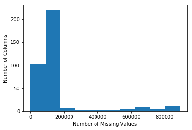

```python
# Investigate patterns in the amount of missing data in each column.
plt.hist(azdias_clean.isna().sum())
plt.ylabel('Number of Columns')
plt.xlabel('Number of Missing Values')
plt.show()
```

```python
# Remove the outlier columns which have > 200000 missing values
missing__more_200000 = [col for col in azdias_clean.columns if (azdias_clean[col].isna().sum() > 200000)]
print(missing__more_200000)
azdias_clean.drop(missing__more_200000, axis=1, inplace=True)
```

```
['AGER_TYP', 'ALTER_HH', 'ALTER_KIND1', 'ALTER_KIND2', 'ALTER_KIND3', 'ALTER_KIND4', 'ALTERSKATEGORIE_FEIN', 'D19_BANKEN_ANZ_12', 'D19_BANKEN_ANZ_24', 'D19_BANKEN_DATUM', 'D19_BANKEN_OFFLINE_DATUM', 'D19_BANKEN_ONLINE_DATUM', 'D19_BANKEN_ONLINE_QUOTE_12', 'D19_GESAMT_ANZ_12', 'D19_GESAMT_ANZ_24', 'D…
```

```python
azdias_clean.shape
```

```
(891221, 321)
```

The azdias dataframe originally had 366 columns and now has 321 columns, meaning that 45 columns (12%) were dropped from the dataframe based on having >200000 NaNs. Many of these columns start with "D19" which have to do with transaction activity.

#### Step 1.1.3: Assess Missing Data in Each Row

Now, we'll perform a similar assessment for the rows of the dataset. How much data is missing in each row? As with the columns, we should see some groups of points that have a very different numbers of missing values. Divide the data into two subsets: one for data points that are above some threshold for missing values, and a second subset for points below that threshold.

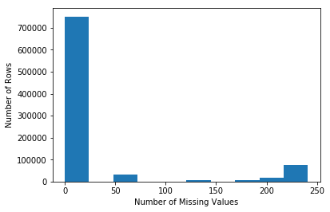

```python
# How much data is missing in each row of the dataset?
missing_row = azdias_clean.isnull().sum(axis=1)
plt.hist(missing_row)
plt.ylabel('Number of Rows')
plt.xlabel('Number of Missing Values')
plt.show()
```

```python
azdias_clean.shape
```

```
(891221, 321)
```

```python
# Select rows which contain equal or less than 10 missing values per row
few_missing = azdias_clean[azdias_clean.isnull().sum(axis=1) <= 10].reset_index(drop=True)
few_missing.shape
```

```
(746760, 321)
```

```python
azdias_clean = few_missing
```

The azdias dataframe originally had 891221 rows and now has 746760 rows, meaning that 144461 rows (16%) were dropped from the dataframe based on having > 10 NaNs.

## Step 1.2: Select and Re-Encode Features

Information from Term 1: Since the unsupervised learning techniques to be used will only work on data that is encoded numerically, you need to make a few encoding changes or additional assumptions to be able to make progress. In addition, while almost all of the values in the dataset are encoded using numbers, not all of them represent numeric values. Check the third column of the feature summary (`feat_info`) for a summary of types of measurement.

- For numeric and interval data, these features can be kept without changes.
- Most of the variables in the dataset are ordinal in nature. While ordinal values may technically be non-linear in spacing, make the simplifying assumption that the ordinal variables can be treated as being interval in nature (that is, kept without any changes).
- Special handling may be necessary for the remaining two variable types: categorical, and 'mixed'.

In this project we don't have the type of each attributes, therefore I manually looked through the Attributes excel sheet and noted down which columns looked like either categorical or mixed and store them into the variable "categorical" below.

#### Step 1.2.1: Re-Encode Categorical Features

From Term 1: For categorical data, you would ordinarily need to encode the levels as dummy variables. Depending on the number of categories, perform one of the following:

- For binary (two-level) categoricals that take numeric values, you can keep them without needing to do anything.
- There is one binary variable that takes on non-numeric values. For this one, you need to re-encode the values as numbers or create a dummy variable.
- For multi-level categoricals (three or more values), you can choose to encode the values using multiple dummy variables (e.g. via [OneHotEncoder](http://scikit-learn.org/stable/modules/generated/sklearn.preprocessing.OneHotEncoder.html)), or (to keep things straightforward) just drop them from the analysis. As always, document your choices in the Discussion section.

```python
categorical = ['AGER_TYP', 'ANREDE_KZ', 'BIP_FLAG', 'CAMEO_DEU_2015', 'CAMEO_DEUINTL_2015', 'CJT_GESAMTTYP',
'D19_KONSUMTYP', 'D19_KK_KUNDENTYP', 'FINANZTYP', 'GEBAEUDETYP', 'GEBAEUDETYP_RASTER', 'GFK_URLAUBERTYP',
'HAUSHALTSSTRUKTUR', 'HEALTH_TYP', 'KBA05_HERSTTEMP', 'KBA05_MAXHERST', 'KBA05_MODTEMP', 'LP_FAMILIE_FEIN',
'LP_FAMILIE_GROB', 'LP_LEBENSPHASE_FEIN', 'LP_LEBENSPHASE_GROB', 'LP_STATUS_FEIN', 'LP_STATUS_GROB',
'NATIONALITAET_KZ', 'OST_WEST_KZ', 'PRAEGENDE_JUGENDJAHRE', 'SHOPPER_TYP', 'SOHO_FLAG', 'TITEL_KZ', 'VERS_TYP']
```

```python
# Assess categorical variables: which are binary, which are multi-level, and
# which one needs to be re-encoded?

# For every column which is encoded as "categorical" in the feat_info dataset
# print the value counts

binary_feature = []
multi_level_feature=[]
for feature in categorical:
    if feature in azdias_clean.columns:
        if (len(azdias_clean[feature].unique())==2):
            binary_feature.append(feature)
        elif (len(azdias_clean[feature].unique())>2):
            multi_level_feature.append(feature)

print('Binary features are: {}'.format(binary_feature))
print('Multi-level features are: {}'.format(multi_level_feature))
```

```
Binary features are: ['ANREDE_KZ', 'OST_WEST_KZ']
Multi-level features are: ['CAMEO_DEU_2015', 'CJT_GESAMTTYP', 'FINANZTYP', 'GEBAEUDETYP', 'GEBAEUDETYP_RASTER', 'GFK_URLAUBERTYP', 'HEALTH_TYP', 'KBA05_HERSTTEMP', 'KBA05_MAXHERST', 'KBA05_MODTEMP', 'LP_FAMILIE_FEIN', 'LP_FAMILIE_GROB', 'LP_LEBENSPHASE_FEIN', 'LP_LEBENSPHASE_GROB', 'LP_STATUS_FEIN',…
```

```python
# Print the values of binary features
for feature in binary_feature:
    print('Unique values for {} are {}'.format(feature, azdias_clean[feature].unique()))
```

```
Unique values for ANREDE_KZ are [ 2.  1.]
Unique values for OST_WEST_KZ are ['W' 'O']
```

```python
# The only binary categorical variable that does not take
# integer values is OST_WEST_KZ which uses either W or O
# will be re-encoded with 1 and 0.  Other binary categorical
# variables will be list as is.
new_values = {'W': 0, 'O': 1}
azdias_clean = azdias_clean.replace({'OST_WEST_KZ':new_values})
azdias_clean['OST_WEST_KZ'].unique()
```

```
array([0, 1])
```

```python
# If column has less than 10 levels, re-encode using dummy variables.
# If column has equal to or more than 10 different values, drop for simplicity.
cols_to_drop = []
cols_to_dummy = []
for feature in multi_level_feature:
    if (len(azdias_clean[feature].unique())<10):
        cols_to_dummy.append(feature)
    else:
        cols_to_drop.append(feature)

print('Features to drop are: {}'.format(cols_to_drop))
print('Features to dummy are: {}'.format(cols_to_dummy))
```

```
Features to drop are: ['CAMEO_DEU_2015', 'GFK_URLAUBERTYP', 'LP_FAMILIE_FEIN', 'LP_LEBENSPHASE_FEIN', 'LP_LEBENSPHASE_GROB', 'LP_STATUS_FEIN', 'PRAEGENDE_JUGENDJAHRE']
Features to dummy are: ['CJT_GESAMTTYP', 'FINANZTYP', 'GEBAEUDETYP', 'GEBAEUDETYP_RASTER', 'HEALTH_TYP', 'KBA05_HERSTTEMP', 'KBA05_MAXHERST', 'KBA05_MODTEMP', 'LP_FAMILIE_GROB', 'LP_STATUS_GROB', 'NATIONALITAET_KZ', 'SHOPPER_TYP', 'TITEL_KZ', 'VERS_TYP']
```

```python
# Drop features with >=10 values
azdias_clean=azdias_clean.drop(cols_to_drop, axis=1)
```

```python
# Create dummy variables for columns with less than 10
# unique values then drop the original columns
for col in cols_to_dummy:
    dummy = pd.get_dummies(azdias_clean[col], prefix = col)
    azdias_clean = pd.concat([azdias_clean, dummy], axis = 1)

azdias_clean.drop(cols_to_dummy, axis=1, inplace = True)
azdias_clean.shape
```

```
(746760, 372)
```

### Step 1.3: Create a Cleaning Function

Guide from Term 1: Even though we've finished cleaning up the general population demographics data, it's important to look ahead to the future and realize that you'll need to perform the same cleaning steps on the customer demographics data. create function to execute the main feature selection, encoding, and re-engineering steps we performed above. Then, when it comes to looking at the customer data in Step 3, we can just run this function on that DataFrame to get the trimmed dataset in a single step.

```python
def clean_data(df, unknown):
    """
    Perform feature trimming, re-encoding, and engineering for demographics
    data

    INPUT: Demographics DataFrame
    OUTPUT: Trimmed and cleaned demographics DataFrame
    """

    # Put in code here to execute all main cleaning steps:
    # convert missing value codes into NaNs, ...
    feat_names = unknown.Attribute.tolist()
    for col in range(df.shape[1]):
        col_name=df.columns[col]
        if col_name in feat_names:
            nan_list=unknown.loc[unknown['Attribute'] == col_name, 'Value'].iloc[0]
            na_idx = df.loc[:, col_name].isin(nan_list)
            df.loc[na_idx, col_name] = np.NaN

    # remove selected columns, ...
    # These columns were the ones above that had
    # > 200000 missing values in the azdias dataframe
    cols_to_drop = ['AGER_TYP', 'ALTER_HH', 'ALTER_KIND1', 'ALTER_KIND2', 'ALTER_KIND3',
                    'ALTER_KIND4', 'ALTERSKATEGORIE_FEIN', 'D19_BANKEN_ANZ_12', 'D19_BANKEN_ANZ_24',
                    'D19_BANKEN_DATUM', 'D19_BANKEN_OFFLINE_DATUM', 'D19_BANKEN_ONLINE_DATUM',
                    'D19_BANKEN_ONLINE_QUOTE_12', 'D19_GESAMT_ANZ_12', 'D19_GESAMT_ANZ_24',
                    'D19_GESAMT_DATUM', 'D19_GESAMT_OFFLINE_DATUM', 'D19_GESAMT_ONLINE_DATUM',
                    'D19_GESAMT_ONLINE_QUOTE_12', 'D19_KONSUMTYP', 'D19_LETZTER_KAUF_BRANCHE',
                    'D19_LOTTO', 'D19_SOZIALES', 'D19_TELKO_ANZ_12', 'D19_TELKO_ANZ_24',
                    'D19_TELKO_DATUM', 'D19_TELKO_OFFLINE_DATUM', 'D19_TELKO_ONLINE_DATUM',
                    'D19_TELKO_ONLINE_QUOTE_12', 'D19_VERSAND_ANZ_12', 'D19_VERSAND_ANZ_24',
                    'D19_VERSAND_DATUM', 'D19_VERSAND_OFFLINE_DATUM', 'D19_VERSAND_ONLINE_DATUM',
                    'D19_VERSAND_ONLINE_QUOTE_12', 'D19_VERSI_ANZ_12', 'D19_VERSI_ANZ_24',
                    'D19_VERSI_ONLINE_QUOTE_12', 'EXTSEL992', 'KBA05_ANTG1', 'KBA05_ANTG2',
                    'KBA05_ANTG3', 'KBA05_ANTG4', 'KBA05_MAXVORB', 'KK_KUNDENTYP']
    df.drop(cols_to_drop, axis=1, inplace = True)

    # remove selected rows, ...
    # Rows which have >10 missing values
    few_missing = df[df.isnull().sum(axis=1) <= 10].reset_index(drop=True)
    df = few_missing

    # select, re-encode, and engineer column values
    df.loc[df['OST_WEST_KZ']=='W','OST_WEST_KZ']=0
    df.loc[df['OST_WEST_KZ']=='O','OST_WEST_KZ']=1

    cols_to_dummy = ['CJT_GESAMTTYP', 'FINANZTYP', 'GEBAEUDETYP', 'GEBAEUDETYP_RASTER',
                     'HEALTH_TYP', 'KBA05_HERSTTEMP', 'KBA05_MAXHERST', 'KBA05_MODTEMP',
                     'LP_FAMILIE_GROB', 'LP_STATUS_GROB', 'NATIONALITAET_KZ', 'SHOPPER_TYP',
                     'TITEL_KZ', 'VERS_TYP']

    for col in cols_to_dummy:
        dummy = pd.get_dummies(df[col], prefix = col)
        df = pd.concat([df, dummy], axis = 1)

    df.drop(cols_to_dummy, axis=1, inplace = True)

    cols_to_drop = ['CAMEO_DEU_2015', 'GFK_URLAUBERTYP', 'LP_FAMILIE_FEIN',
                    'LP_LEBENSPHASE_FEIN', 'LP_LEBENSPHASE_GROB', 'LP_STATUS_FEIN',
                    'PRAEGENDE_JUGENDJAHRE']

    df.drop(cols_to_drop, axis=1, inplace = True)

    # Return the cleaned dataframe.
    return df
```

```python
# copy the dataframe
customers_clean = customers.copy()
```

```python
# View the first few lines of the customers dataframe
customers_clean.head()
```

|  | LNR | AGER_TYP | AKT_DAT_KL | ALTER_HH | ALTER_KIND1 | ALTER_KIND2 | ALTER_KIND3 | ALTER_KIND4 | ALTERSKATEGORIE_FEIN | ANZ_HAUSHALTE_AKTIV | ... | VK_ZG11 | W_KEIT_KIND_HH | WOHNDAUER_2008 | WOHNLAGE | ZABEOTYP | PRODUCT_GROUP | CUSTOMER_GROUP | ONLINE_PURCHASE | ANREDE_KZ | ALTERSKATEGORIE_GROB |
| --- | --- | --- | --- | --- | --- | --- | --- | --- | --- | --- | --- | --- | --- | --- | --- | --- | --- | --- | --- | --- | --- |
| 0 | 9626 | 2 | 1.0 | 10.0 | NaN | NaN | NaN | NaN | 10.0 | 1.0 | ... | 2.0 | 6.0 | 9.0 | 7.0 | 3 | COSMETIC_AND_FOOD | MULTI_BUYER | 0 | 1 | 4 |
| 1 | 9628 | -1 | 9.0 | 11.0 | NaN | NaN | NaN | NaN | NaN | NaN | ... | 3.0 | 0.0 | 9.0 | NaN | 3 | FOOD | SINGLE_BUYER | 0 | 1 | 4 |
| 2 | 143872 | -1 | 1.0 | 6.0 | NaN | NaN | NaN | NaN | 0.0 | 1.0 | ... | 11.0 | 6.0 | 9.0 | 2.0 | 3 | COSMETIC_AND_FOOD | MULTI_BUYER | 0 | 2 | 4 |
| 3 | 143873 | 1 | 1.0 | 8.0 | NaN | NaN | NaN | NaN | 8.0 | 0.0 | ... | 2.0 | NaN | 9.0 | 7.0 | 1 | COSMETIC | MULTI_BUYER | 0 | 1 | 4 |
| 4 | 143874 | -1 | 1.0 | 20.0 | NaN | NaN | NaN | NaN | 14.0 | 7.0 | ... | 4.0 | 2.0 | 9.0 | 3.0 | 1 | FOOD | MULTI_BUYER | 0 | 1 | 3 |

5 rows × 369 columns

```python
# number of Customers rows' and columns'
customers_clean.shape
```

```
(191652, 369)
```

```python
# Investigate the CUSTOMER_GROUP column
customers_clean['CUSTOMER_GROUP'].value_counts()
```

```
MULTI_BUYER     132238
SINGLE_BUYER     59414
Name: CUSTOMER_GROUP, dtype: int64
```

```python
# Investigate the ONLINE_PURCHASE column
customers_clean['ONLINE_PURCHASE'].value_counts()
```

```
0    174356
1     17296
Name: ONLINE_PURCHASE, dtype: int64
```

```python
# Investigate the PRODUCT_GROUP column
customers_clean['PRODUCT_GROUP'].value_counts()
```

```
COSMETIC_AND_FOOD    100860
FOOD                  47382
COSMETIC              43410
Name: PRODUCT_GROUP, dtype: int64
```

```python
# how many NaNs value in the 3 extra columns?
customers_clean['CUSTOMER_GROUP'].count(), customers_clean['ONLINE_PURCHASE'].count(), customers_clean['PRODUCT_GROUP'].count()
```

```
(191652, 191652, 191652)
```

```python
# Reload unknowns object as saved after above analysis
unknown = pickle.load(open("unknown.pickle", "rb"))
```

```python
# Run the clean_data function on the azdias dataset
customers_clean = clean_data(customers_clean, unknown)
```

```python
# Determine the shape of the customers dataframe after cleaning
customers_clean.shape
```

```
(132100, 373)
```

```python
# View the first few lines of the customers dataframe after cleaning
customers_clean.head()
```

|  | LNR | AKT_DAT_KL | ANZ_HAUSHALTE_AKTIV | ANZ_HH_TITEL | ANZ_KINDER | ANZ_PERSONEN | ANZ_STATISTISCHE_HAUSHALTE | ANZ_TITEL | ARBEIT | BALLRAUM | ... | SHOPPER_TYP_1.0 | SHOPPER_TYP_2.0 | SHOPPER_TYP_3.0 | TITEL_KZ_0.0 | TITEL_KZ_1.0 | TITEL_KZ_3.0 | TITEL_KZ_4.0 | TITEL_KZ_5.0 | VERS_TYP_1.0 | VERS_TYP_2.0 |
| --- | --- | --- | --- | --- | --- | --- | --- | --- | --- | --- | --- | --- | --- | --- | --- | --- | --- | --- | --- | --- | --- |
| 0 | 9626 | 1.0 | 1.0 | 0.0 | 0.0 | 2.0 | 1.0 | 0.0 | 1.0 | 3.0 | ... | 0 | 0 | 1 | 1 | 0 | 0 | 0 | 0 | 1 | 0 |
| 1 | 143872 | 1.0 | 1.0 | 0.0 | 0.0 | 1.0 | 1.0 | 0.0 | 3.0 | 7.0 | ... | 1 | 0 | 0 | 1 | 0 | 0 | 0 | 0 | 0 | 1 |
| 2 | 143873 | 1.0 | 0.0 | NaN | 0.0 | 0.0 | 1.0 | 0.0 | 1.0 | 7.0 | ... | 0 | 0 | 0 | 1 | 0 | 0 | 0 | 0 | 1 | 0 |
| 3 | 143874 | 1.0 | 7.0 | 0.0 | 0.0 | 4.0 | 7.0 | 0.0 | 3.0 | 3.0 | ... | 1 | 0 | 0 | 1 | 0 | 0 | 0 | 0 | 0 | 1 |
| 4 | 143888 | 1.0 | 1.0 | 0.0 | 0.0 | 2.0 | 1.0 | 0.0 | 3.0 | 7.0 | ... | 1 | 0 | 0 | 1 | 0 | 0 | 0 | 0 | 0 | 1 |

5 rows × 373 columns

```python
customers_clean.columns.tolist()
```

```
['LNR',
 'AKT_DAT_KL',
 'ANZ_HAUSHALTE_AKTIV',
 'ANZ_HH_TITEL',
 'ANZ_KINDER',
 'ANZ_PERSONEN',
 'ANZ_STATISTISCHE_HAUSHALTE',
 'ANZ_TITEL',
 'ARBEIT',
 'BALLRAUM',
 'CAMEO_DEUG_2015',
 'CAMEO_INTL_2015',
 'CJT_KATALOGNUTZER',
 'CJT_TYP_1',
 'CJT_TYP_2',
 'CJT_TYP_3',
 'CJT_TYP_4',
 'CJT_TYP_5',
 'CJT_TYP_6',
 'D19_BANKEN_DIREKT',
 'D19_BANKEN_GROSS',
 'D19_BANKEN_LOKAL',
 'D19_BANKEN_REST',
 'D19_BEKLEIDUNG_GEH',
 'D19_BEKLEIDUNG_REST',
 'D19_BILDUNG',
 'D19_BIO_OEKO',
 'D19_BUCH_CD',
 'D19_DIGIT_SERV',
 'D19_DROGERIEARTIKEL',
 'D19_ENERGIE',
 'D19_FREIZEIT',
 'D19_GARTEN',
 'D19_HANDWERK',
 'D19_HAUS_DEKO',
 'D19_KINDERARTIKEL',
 'D19_KONSUMTYP_MAX',
 'D19_KOSMETIK',
 'D19_LEBENSMITTEL',
 'D19_NAHRUNGSERGAENZUNG',
```

[output cut: 318 more lines]

```
 'NATIONALITAET_KZ_0.0',
 'NATIONALITAET_KZ_1.0',
 'NATIONALITAET_KZ_2.0',
 'NATIONALITAET_KZ_3.0',
 'SHOPPER_TYP_0.0',
 'SHOPPER_TYP_1.0',
 'SHOPPER_TYP_2.0',
 'SHOPPER_TYP_3.0',
 'TITEL_KZ_0.0',
 'TITEL_KZ_1.0',
 'TITEL_KZ_3.0',
 'TITEL_KZ_4.0',
 'TITEL_KZ_5.0',
 'VERS_TYP_1.0',
 'VERS_TYP_2.0']
```

```python
# Determine the columns that are in the cleaned customers dataframe
# but not the cleaned azdias dataframe (these 3 are expected)
customers_clean.columns[~customers_clean.columns.isin(azdias_clean.columns)]
```

```
Index(['PRODUCT_GROUP', 'CUSTOMER_GROUP', 'ONLINE_PURCHASE'], dtype='object')
```

```python
# Determine the columns that are in the cleaned azdias dataframe
# but not the cleaned cutomers dataframe (these 3 are expected)
azdias_clean.columns[~azdias_clean.columns.isin(customers_clean.columns)]
```

```
Index(['GEBAEUDETYP_5.0', 'TITEL_KZ_2.0'], dtype='object')
```

```python
# Find index of the GEBAEUDETYP_5.0 and TITEL_KZ_2.0 columns in the azdias dataframe
column_GEB_index = azdias_clean.columns.get_loc("GEBAEUDETYP_5.0")
column_TIT_index = azdias_clean.columns.get_loc("TITEL_KZ_2.0")
column_GEB_index, column_TIT_index
```

```
(316, 366)
```

```python
# Insert a column called GEBAEUDETYP_5.0 at index = 316
# Insert a column called TITEL_KZ_2.0 at index = 366
# with all values = 0
customers_clean.insert(loc=column_GEB_index, column='GEBAEUDETYP_5.0', value=0)
customers_clean.insert(loc=column_TIT_index, column='TITEL_KZ_2.0', value=0)
```

```python
customers_clean.shape[1], azdias_clean.shape[1]
```

```
(375, 372)
```

```python
# Dump the azdias dataframe to a pickle object since it takes up so much room in memory.
pickle.dump(azdias_clean, open("azdias_clean.pickle", "wb"))

# Dump the customers dataframe to a pickle object to use for later.
pickle.dump(customers_clean, open("customers_clean.pickle", "wb"))
```

## Step 2: Feature Transformation

### 2.1 Apply Feature Scaling

Guide from Term1: Before we apply dimensionality reduction techniques to the data, we need to perform feature scaling so that the principal component vectors are not influenced by the natural differences in scale for features. Starting from this part of the project, we'll want to keep an eye on the [API reference page for sklearn](http://scikit-learn.org/stable/modules/classes.html) to help you navigate to all of the classes and functions that you'll need. In this substep, you'll need to check the following:

- sklearn requires that data not have missing values in order for its estimators to work properly. So, before applying the scaler to your data, make sure that you've cleaned the DataFrame of the remaining missing values. This can be as simple as just removing all data points with missing data, or applying an [Imputer](http://scikit-learn.org/stable/modules/generated/sklearn.preprocessing.Imputer.html) to replace all missing values. You might also try a more complicated procedure where you temporarily remove missing values in order to compute the scaling parameters before re-introducing those missing values and applying imputation. Think about how much missing data you have and what possible effects each approach might have on your analysis, and justify your decision in the discussion section below.
- For the actual scaling function, a [StandardScaler](http://scikit-learn.org/stable/modules/generated/sklearn.preprocessing.StandardScaler.html) instance is suggested, scaling each feature to mean 0 and standard deviation 1.
- For these classes, you can make use of the `.fit_transform()` method to both fit a procedure to the data as well as apply the transformation to the data at the same time. Don't forget to keep the fit sklearn objects handy, since you'll be applying them to the customer demographics data towards the end of the project.

```python
# Reload cleaned azdias object as saved after above analysis (may need to rerun imports)
azdias_clean = pickle.load(open("azdias_clean.pickle", "rb"))

# Reload cleaned customers object as saved after above analysis
customers_clean = pickle.load(open("customers_clean.pickle", "rb"))
```

```python
for col in azdias_clean.columns:
    print("feature {}, has the following unique values: {}", col, azdias_clean[col].unique())
```

[output not shown]

[output cut: 387 more lines]

```
feature {}, has the following unique values: {} NATIONALITAET_KZ_1.0 [1 0]
feature {}, has the following unique values: {} NATIONALITAET_KZ_2.0 [0 1]
feature {}, has the following unique values: {} NATIONALITAET_KZ_3.0 [0 1]
feature {}, has the following unique values: {} SHOPPER_TYP_0.0 [0 1]
feature {}, has the following unique values: {} SHOPPER_TYP_1.0 [0 1]
feature {}, has the following unique values: {} SHOPPER_TYP_2.0 [0 1]
feature {}, has the following unique values: {} SHOPPER_TYP_3.0 [1 0]
feature {}, has the following unique values: {} TITEL_KZ_0.0 [1 0]
feature {}, has the following unique values: {} TITEL_KZ_1.0 [0 1]
feature {}, has the following unique values: {} TITEL_KZ_2.0 [0 1]
feature {}, has the following unique values: {} TITEL_KZ_3.0 [0 1]
feature {}, has the following unique values: {} TITEL_KZ_4.0 [0 1]
feature {}, has the following unique values: {} TITEL_KZ_5.0 [0 1]
feature {}, has the following unique values: {} VERS_TYP_1.0 [0 1]
feature {}, has the following unique values: {} VERS_TYP_2.0 [1 0]
```

```python
# The imputer does not work at this stage because the columns CAMEO_DEUG_2015 and CAMEO_INTL_2015
# have string values of "X" and "XX". EINGEFUEGT_AM has a string issue.
# Remove these columns for simplicity.
del azdias_clean['CAMEO_DEUG_2015']
del azdias_clean['CAMEO_INTL_2015']
del azdias_clean['EINGEFUEGT_AM']
del customers_clean['CAMEO_DEUG_2015']
del customers_clean['CAMEO_INTL_2015']
del customers_clean['EINGEFUEGT_AM']
```

```python
azdias_clean.shape, customers_clean.shape
```

```
((746760, 369), (132100, 372))
```

```python
# Make a new dataframe to hold the 3 extra columns of the customers dataset in case we need
# them for later. Then, remove them from the dataframe
customers_extra_cols = customers_clean[['PRODUCT_GROUP', 'CUSTOMER_GROUP', 'ONLINE_PURCHASE']]
customers_clean.drop(customers_extra_cols, axis=1, inplace=True)
```

```python
azdias_clean.shape, customers_clean.shape
```

```
((746760, 369), (132100, 369))
```

```python
# Impute the missing values using the median
imputer = Imputer(strategy='median')
azdias_clean = pd.DataFrame(imputer.fit_transform(azdias_clean), columns = azdias_clean.columns)
customers_clean = pd.DataFrame(imputer.transform(customers_clean), columns = customers_clean.columns)
```

```python
# View number of NaNs per column of the azdias_clean df
azdias_clean.isna().sum()
```

```
LNR                           0
AKT_DAT_KL                    0
ANZ_HAUSHALTE_AKTIV           0
ANZ_HH_TITEL                  0
ANZ_KINDER                    0
ANZ_PERSONEN                  0
ANZ_STATISTISCHE_HAUSHALTE    0
ANZ_TITEL                     0
ARBEIT                        0
BALLRAUM                      0
CJT_KATALOGNUTZER             0
CJT_TYP_1                     0
CJT_TYP_2                     0
CJT_TYP_3                     0
CJT_TYP_4                     0
CJT_TYP_5                     0
CJT_TYP_6                     0
D19_BANKEN_DIREKT             0
D19_BANKEN_GROSS              0
D19_BANKEN_LOKAL              0
D19_BANKEN_REST               0
D19_BEKLEIDUNG_GEH            0
D19_BEKLEIDUNG_REST           0
D19_BILDUNG                   0
D19_BIO_OEKO                  0
D19_BUCH_CD                   0
D19_DIGIT_SERV                0
D19_DROGERIEARTIKEL           0
D19_ENERGIE                   0
D19_FREIZEIT                  0
                             ..
KBA05_MODTEMP_4.0             0
KBA05_MODTEMP_5.0             0
KBA05_MODTEMP_6.0             0
LP_FAMILIE_GROB_0.0           0
LP_FAMILIE_GROB_1.0           0
LP_FAMILIE_GROB_2.0           0
LP_FAMILIE_GROB_3.0           0
LP_FAMILIE_GROB_4.0           0
LP_FAMILIE_GROB_5.0           0
LP_STATUS_GROB_1.0            0
LP_STATUS_GROB_2.0            0
LP_STATUS_GROB_3.0            0
LP_STATUS_GROB_4.0            0
LP_STATUS_GROB_5.0            0
NATIONALITAET_KZ_0.0          0
NATIONALITAET_KZ_1.0          0
NATIONALITAET_KZ_2.0          0
NATIONALITAET_KZ_3.0          0
SHOPPER_TYP_0.0               0
SHOPPER_TYP_1.0               0
SHOPPER_TYP_2.0               0
SHOPPER_TYP_3.0               0
TITEL_KZ_0.0                  0
TITEL_KZ_1.0                  0
TITEL_KZ_2.0                  0
TITEL_KZ_3.0                  0
TITEL_KZ_4.0                  0
TITEL_KZ_5.0                  0
VERS_TYP_1.0                  0
VERS_TYP_2.0                  0
Length: 369, dtype: int64
```

```python
# View number of NaNs per column of the customers_clean df
customers_clean.isna().sum()
```

```
LNR                           0
AKT_DAT_KL                    0
ANZ_HAUSHALTE_AKTIV           0
ANZ_HH_TITEL                  0
ANZ_KINDER                    0
ANZ_PERSONEN                  0
ANZ_STATISTISCHE_HAUSHALTE    0
ANZ_TITEL                     0
ARBEIT                        0
BALLRAUM                      0
CJT_KATALOGNUTZER             0
CJT_TYP_1                     0
CJT_TYP_2                     0
CJT_TYP_3                     0
CJT_TYP_4                     0
CJT_TYP_5                     0
CJT_TYP_6                     0
D19_BANKEN_DIREKT             0
D19_BANKEN_GROSS              0
D19_BANKEN_LOKAL              0
D19_BANKEN_REST               0
D19_BEKLEIDUNG_GEH            0
D19_BEKLEIDUNG_REST           0
D19_BILDUNG                   0
D19_BIO_OEKO                  0
D19_BUCH_CD                   0
D19_DIGIT_SERV                0
D19_DROGERIEARTIKEL           0
D19_ENERGIE                   0
D19_FREIZEIT                  0
                             ..
KBA05_MODTEMP_4.0             0
KBA05_MODTEMP_5.0             0
KBA05_MODTEMP_6.0             0
LP_FAMILIE_GROB_0.0           0
LP_FAMILIE_GROB_1.0           0
LP_FAMILIE_GROB_2.0           0
LP_FAMILIE_GROB_3.0           0
LP_FAMILIE_GROB_4.0           0
LP_FAMILIE_GROB_5.0           0
LP_STATUS_GROB_1.0            0
LP_STATUS_GROB_2.0            0
LP_STATUS_GROB_3.0            0
LP_STATUS_GROB_4.0            0
LP_STATUS_GROB_5.0            0
NATIONALITAET_KZ_0.0          0
NATIONALITAET_KZ_1.0          0
NATIONALITAET_KZ_2.0          0
NATIONALITAET_KZ_3.0          0
SHOPPER_TYP_0.0               0
SHOPPER_TYP_1.0               0
SHOPPER_TYP_2.0               0
TITEL_KZ_2.0                  0
SHOPPER_TYP_3.0               0
TITEL_KZ_0.0                  0
TITEL_KZ_1.0                  0
TITEL_KZ_3.0                  0
TITEL_KZ_4.0                  0
TITEL_KZ_5.0                  0
VERS_TYP_1.0                  0
VERS_TYP_2.0                  0
Length: 369, dtype: int64
```

```python
# Apply feature scaling to the general population demographics data.
scaler = StandardScaler()
azdias_clean = pd.DataFrame(scaler.fit_transform(azdias_clean), columns = azdias_clean.columns)
customers_clean = pd.DataFrame(scaler.transform(customers_clean), columns = customers_clean.columns)
```

```python
# View the first few lines of the azdias dataset after scaling
azdias_clean.head()
```

|  | LNR | AKT_DAT_KL | ANZ_HAUSHALTE_AKTIV | ANZ_HH_TITEL | ANZ_KINDER | ANZ_PERSONEN | ANZ_STATISTISCHE_HAUSHALTE | ANZ_TITEL | ARBEIT | BALLRAUM | ... | SHOPPER_TYP_2.0 | SHOPPER_TYP_3.0 | TITEL_KZ_0.0 | TITEL_KZ_1.0 | TITEL_KZ_2.0 | TITEL_KZ_3.0 | TITEL_KZ_4.0 | TITEL_KZ_5.0 | VERS_TYP_1.0 | VERS_TYP_2.0 |
| --- | --- | --- | --- | --- | --- | --- | --- | --- | --- | --- | --- | --- | --- | --- | --- | --- | --- | --- | --- | --- | --- |
| 0 | 1.060026 | 1.246445 | 0.158383 | -0.128384 | -0.29658 | 0.234784 | 0.291471 | -0.060465 | -0.185725 | 0.851958 | ... | -0.600886 | 1.893731 | 0.051207 | -0.048605 | -0.002004 | -0.007676 | -0.008425 | -0.01116 | -0.902986 | 0.991254 |
| 1 | 1.060045 | 1.246445 | 0.094585 | -0.128384 | -0.29658 | -0.625756 | -0.055501 | -0.060465 | -0.185725 | -0.975108 | ... | 1.664209 | -0.528058 | 0.051207 | -0.048605 | -0.002004 | -0.007676 | -0.008425 | -0.01116 | 1.107437 | -1.008824 |
| 2 | 1.060049 | -0.944531 | -0.479599 | -0.128384 | -0.29658 | -1.486295 | -0.402473 | -0.060465 | -1.192165 | -0.061575 | ... | -0.600886 | -0.528058 | 0.051207 | -0.048605 | -0.002004 | -0.007676 | -0.008425 | -0.01116 | 1.107437 | -1.008824 |
| 3 | 1.060107 | -0.944531 | -0.352003 | -0.128384 | -0.29658 | 1.955862 | -0.333078 | -0.060465 | 0.820714 | -0.975108 | ... | 1.664209 | -0.528058 | 0.051207 | -0.048605 | -0.002004 | -0.007676 | -0.008425 | -0.01116 | -0.902986 | 0.991254 |
| 4 | 1.060119 | -0.944531 | -0.224406 | -0.128384 | -0.29658 | -0.625756 | -0.402473 | -0.060465 | -1.192165 | 0.851958 | ... | -0.600886 | -0.528058 | 0.051207 | -0.048605 | -0.002004 | -0.007676 | -0.008425 | -0.01116 | -0.902986 | 0.991254 |

5 rows × 369 columns

```python
# View the first few lines of the customers dataset after scaling
customers_clean.head()
```

|  | LNR | AKT_DAT_KL | ANZ_HAUSHALTE_AKTIV | ANZ_HH_TITEL | ANZ_KINDER | ANZ_PERSONEN | ANZ_STATISTISCHE_HAUSHALTE | ANZ_TITEL | ARBEIT | BALLRAUM | ... | SHOPPER_TYP_2.0 | TITEL_KZ_2.0 | SHOPPER_TYP_3.0 | TITEL_KZ_0.0 | TITEL_KZ_1.0 | TITEL_KZ_3.0 | TITEL_KZ_4.0 | TITEL_KZ_5.0 | VERS_TYP_1.0 | VERS_TYP_2.0 |
| --- | --- | --- | --- | --- | --- | --- | --- | --- | --- | --- | --- | --- | --- | --- | --- | --- | --- | --- | --- | --- | --- |
| 0 | -2.430223 | -0.944531 | -0.479599 | -0.128384 | -0.29658 | 0.234784 | -0.471867 | -0.060465 | -2.198604 | -0.518342 | ... | -0.600886 | -0.528058 | 0.051207 | 20.574145 | -0.002004 | -0.007676 | -0.008425 | -0.01116 | 1.107437 | -1.008824 |
| 1 | -1.909954 | -0.944531 | -0.479599 | -0.128384 | -0.29658 | -0.625756 | -0.471867 | -0.060465 | -0.185725 | 1.308725 | ... | -0.600886 | -0.528058 | -19.528584 | 20.574145 | -0.002004 | -0.007676 | -0.008425 | -0.01116 | -0.902986 | 0.991254 |
| 2 | -1.909950 | -0.944531 | -0.543397 | -0.128384 | -0.29658 | -1.486295 | -0.471867 | -0.060465 | -2.198604 | 1.308725 | ... | -0.600886 | -0.528058 | -19.528584 | 20.574145 | -0.002004 | -0.007676 | -0.008425 | -0.01116 | 1.107437 | -1.008824 |
| 3 | -1.909946 | -0.944531 | -0.096810 | -0.128384 | -0.29658 | 1.955862 | -0.055501 | -0.060465 | -0.185725 | -0.518342 | ... | -0.600886 | -0.528058 | -19.528584 | 20.574145 | -0.002004 | -0.007676 | -0.008425 | -0.01116 | -0.902986 | 0.991254 |
| 4 | -1.909892 | -0.944531 | -0.479599 | -0.128384 | -0.29658 | 0.234784 | -0.471867 | -0.060465 | -0.185725 | 1.308725 | ... | -0.600886 | -0.528058 | -19.528584 | 20.574145 | -0.002004 | -0.007676 | -0.008425 | -0.01116 | -0.902986 | 0.991254 |

5 rows × 369 columns

The nan were imputed using the median value per column. The median was chosen, instead of the mean, because:

- it is more robust against outliers.
- all of the numeric variables are intergers in this case, means will bring float number into the dataset.

```python
# Dump the azdias dataframe to a pickle object since it takes up so much room in memory.
pickle.dump(azdias_clean, open("azdias_final.pickle", "wb"))

# Dump the customers dataframe to a pickle object to use for later.
pickle.dump(customers_clean, open("customers_final.pickle", "wb"))
```

## Part 1: Customer Segmentation Report

The main bulk of your analysis will come in this part of the project. Here, you should use unsupervised learning techniques to describe the relationship between the demographics of the company's existing customers and the general population of Germany. By the end of this part, you should be able to describe parts of the general population that are more likely to be part of the mail-order company's main customer base, and which parts of the general population are less so.

```python
# Reload cleaned azdias object as saved after above analysis
azdias_final = pickle.load(open("azdias_final.pickle", "rb"))

# Reload cleaned customers object as saved after above analysis
customers_final = pickle.load(open("customers_final.pickle", "rb"))
```

### Step 2.2: Perform Dimensionality Reduction

From Term 1: On your scaled data, you are now ready to apply dimensionality reduction techniques.

- Use sklearn's [PCA](http://scikit-learn.org/stable/modules/generated/sklearn.decomposition.PCA.html) class to apply principal component analysis on the data, thus finding the vectors of maximal variance in the data. To start, you should not set any parameters (so all components are computed) or set a number of components that is at least half the number of features (so there's enough features to see the general trend in variability).
- Check out the ratio of variance explained by each principal component as well as the cumulative variance explained. Try plotting the cumulative or sequential values using matplotlib's [`plot()`](https://matplotlib.org/api/_as_gen/matplotlib.pyplot.plot.html) function. Based on what you find, select a value for the number of transformed features you'll retain for the clustering part of the project.
- Once you've made a choice for the number of components to keep, make sure you re-fit a PCA instance to perform the decided-on transformation.

```python
# Apply PCA Function to the data.
def do_pca(n_components, data):
    '''
    Transforms data using PCA to create n_components, and provides back the results of the
    transformation.

    INPUT: n_components - int - the number of principal components to create
           data - the data you would like to transform

    OUTPUT: pca - the pca object created after fitting the data
            X_pca - the transformed X matrix with new number of components
    '''
    pca = PCA(n_components)
    X_pca = pca.fit_transform(data)
    return pca, X_pca
```

```python
# Investigate the variance accounted for by each principal component.
def scree_plot(pca):
    num_components = len(pca.explained_variance_ratio_)
    ind = np.arange(num_components)
    vals = pca.explained_variance_ratio_

    plt.figure(figsize=(10, 6))
    ax = plt.subplot(111)
    cumvals = np.cumsum(vals)
    ax.bar(ind, vals)
    ax.plot(ind, cumvals)
    for i in range(num_components):
        ax.annotate(r"%s%%" % ((str(vals[i]*100)[:4])), (ind[i]+0.2, vals[i]), va="bottom", ha="center", fontsize=12)

    ax.xaxis.set_tick_params(width=0)
    ax.yaxis.set_tick_params(width=2, length=12)

    ax.set_xlabel("Principal Component")
    ax.set_ylabel("Variance Explained (%)")
    plt.title('Explained Variance Per Principal Component')
```

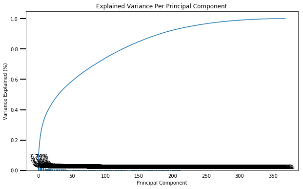

```python
# Apply PCA Function to the data.
pca, X_pca = do_pca(None, azdias_final)
scree_plot(pca)
```

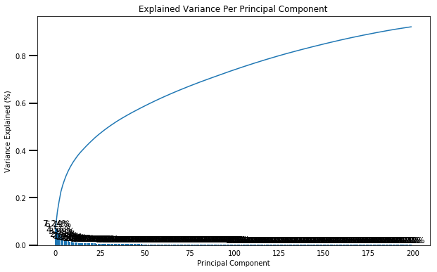

```python
# Re-apply PCA to the data while selecting for number of components to retain.
pca, X_pca = do_pca(200, azdias_final)
scree_plot(pca)
```

I choose 200 components for the next step for the analysis.When n_components equals 200, the variance explained is close to 90%.

### Step 2.3: Interpret Principal Components

Information from Term1: Now that we have our transformed principal components, it's a nice idea to check out the weight of each variable on the first few components to see if they can be interpreted in some fashion.

As a reminder, each principal component is a unit vector that points in the direction of highest variance (after accounting for the variance captured by earlier principal components). The further a weight is from zero, the more the principal component is in the direction of the corresponding feature. If two features have large weights of the same sign (both positive or both negative), then increases in one tend expect to be associated with increases in the other. To contrast, features with different signs can be expected to show a negative correlation: increases in one variable should result in a decrease in the other.

- To investigate the features, you should map each weight to their corresponding feature name, then sort the features according to weight. The most interesting features for each principal component, then, will be those at the beginning and end of the sorted list. Use the data dictionary document to help you understand these most prominent features, their relationships, and what a positive or negative value on the principal component might indicate.
- You should investigate and interpret feature associations from the first three principal components in this substep. To help facilitate this, you should write a function that you can call at any time to print the sorted list of feature weights, for the *i*-th principal component. This might come in handy in the next step of the project, when you interpret the tendencies of the discovered clusters.

```python
# The pca_results function was taken from the class notes and altered

def pca_results(full_dataset, pca, component_number):
    '''
    Create a DataFrame of the PCA results
    Includes dimension feature weights and explained variance
    Visualizes the PCA results where the figure shows the top
    3 negative and positive features.
    '''

    # Dimension indexing
    dimensions = dimensions = ['Dimension {}'.format(i) for i in range(1,len(pca.components_)+1)]

    # PCA components
    components = pd.DataFrame(np.round(pca.components_, 4), columns = full_dataset.keys())
    components.index = dimensions

    # PCA explained variance
    ratios = pca.explained_variance_ratio_.reshape(len(pca.components_), 1)
    variance_ratios = pd.DataFrame(np.round(ratios, 4), columns = ['Explained Variance'])
    variance_ratios.index = dimensions

    # Create a bar plot visualization for the figure (top and bottom 3 columns)
    fig, ax = plt.subplots(figsize = (6,3))

    # Plot the feature weights as a function of the components
    components.iloc[component_number-1, :].sort_values().iloc[[0, 1, 2, -3, -2, -1]].plot(ax = ax, kind = 'bar');
    ax.set_ylabel("Feature Weights")
    ax.set_xticklabels(components.iloc[component_number-1, :].sort_values().index, rotation=90)

    # Return a concatenated DataFrame
    return pd.concat([variance_ratios, components], axis = 1)
```

|  | Explained Variance | LNR | AKT_DAT_KL | ANZ_HAUSHALTE_AKTIV | ANZ_HH_TITEL | ANZ_KINDER | ANZ_PERSONEN | ANZ_STATISTISCHE_HAUSHALTE | ANZ_TITEL | ARBEIT | ... | SHOPPER_TYP_2.0 | SHOPPER_TYP_3.0 | TITEL_KZ_0.0 | TITEL_KZ_1.0 | TITEL_KZ_2.0 | TITEL_KZ_3.0 | TITEL_KZ_4.0 | TITEL_KZ_5.0 | VERS_TYP_1.0 | VERS_TYP_2.0 |
| --- | --- | --- | --- | --- | --- | --- | --- | --- | --- | --- | --- | --- | --- | --- | --- | --- | --- | --- | --- | --- | --- |
| Dimension 1 | 0.0724 | 0.0062 | 0.0074 | 0.0224 | 0.0109 | -0.0084 | -0.0099 | 0.0278 | 0.0021 | -0.0067 | ... | -0.0067 | 0.0061 | -0.0023 | 0.0019 | 0.0010 | 0.0010 | 0.0014 | 0.0003 | -0.0075 | 0.0068 |
| Dimension 2 | 0.0679 | -0.0239 | 0.0647 | 0.0860 | 0.0218 | -0.0213 | -0.0685 | 0.0837 | -0.0020 | 0.0998 | ... | 0.0234 | -0.0197 | 0.0000 | 0.0003 | -0.0001 | -0.0006 | 0.0001 | -0.0010 | -0.0220 | 0.0125 |
| Dimension 3 | 0.0457 | -0.0932 | -0.0068 | -0.0062 | -0.0218 | -0.0037 | 0.0012 | -0.0038 | -0.0115 | 0.0565 | ... | 0.0059 | -0.0079 | 0.0099 | -0.0095 | -0.0000 | -0.0021 | -0.0011 | -0.0015 | 0.0165 | -0.0106 |
| Dimension 4 | 0.0400 | 0.0181 | 0.0455 | -0.0187 | -0.0182 | 0.0730 | 0.0464 | -0.0210 | -0.0095 | -0.0382 | ... | 0.0235 | -0.0652 | 0.0111 | -0.0102 | -0.0003 | -0.0023 | -0.0026 | -0.0030 | 0.0135 | -0.0159 |
| Dimension 5 | 0.0271 | -0.0650 | -0.1159 | 0.0110 | 0.0126 | 0.0641 | 0.1509 | 0.0108 | 0.0138 | 0.0792 | ... | -0.0051 | 0.0364 | -0.0079 | 0.0070 | -0.0000 | 0.0013 | 0.0022 | 0.0033 | 0.0053 | 0.0106 |
| Dimension 6 | 0.0221 | -0.1177 | 0.0490 | 0.0134 | 0.0120 | -0.0187 | -0.0575 | 0.0159 | 0.0008 | 0.0611 | ... | -0.0133 | 0.0022 | -0.0016 | 0.0013 | -0.0002 | 0.0004 | 0.0010 | 0.0007 | 0.0150 | -0.0135 |
| Dimension 7 | 0.0198 | -0.0084 | -0.0032 | -0.0052 | 0.0009 | -0.0294 | -0.0024 | -0.0062 | 0.0087 | -0.0035 | ... | -0.0972 | -0.0709 | -0.0124 | 0.0118 | 0.0005 | 0.0035 | 0.0032 | 0.0004 | -0.0067 | 0.0170 |
| Dimension 8 | 0.0167 | -0.0270 | -0.0185 | 0.0207 | 0.0153 | 0.0099 | 0.0180 | 0.0185 | 0.0065 | -0.0891 | ... | 0.0117 | 0.0001 | -0.0067 | 0.0069 | -0.0010 | -0.0003 | 0.0003 | 0.0009 | 0.0154 | -0.0182 |
| Dimension 9 | 0.0150 | 0.0711 | -0.0088 | 0.0475 | 0.0008 | 0.0094 | 0.0208 | 0.0459 | -0.0103 | -0.0080 | ... | 0.0016 | -0.0127 | 0.0099 | -0.0095 | 0.0002 | -0.0012 | -0.0011 | -0.0023 | -0.0160 | 0.0086 |
| Dimension 10 | 0.0135 | -0.0243 | 0.0129 | -0.0303 | 0.0169 | -0.0116 | -0.0324 | -0.0299 | 0.0140 | 0.0127 | ... | -0.0123 | 0.0179 | -0.0130 | 0.0122 | -0.0003 | 0.0024 | 0.0027 | 0.0026 | 0.0091 | -0.0013 |
| Dimension 11 | 0.0122 | -0.0656 | 0.0042 | 0.0304 | 0.0282 | 0.0073 | 0.0080 | 0.0315 | 0.0190 | 0.0289 | ... | -0.0140 | 0.0168 | -0.0182 | 0.0170 | 0.0008 | 0.0041 | 0.0033 | 0.0038 | 0.0056 | -0.0101 |
| Dimension 12 | 0.0110 | 0.0268 | -0.0182 | 0.1437 | 0.0542 | 0.0009 | 0.0227 | 0.1449 | -0.0021 | -0.0455 | ... | -0.0148 | 0.0037 | 0.0018 | -0.0018 | -0.0010 | 0.0007 | 0.0002 | -0.0013 | 0.0028 | -0.0175 |
| Dimension 13 | 0.0106 | -0.0010 | -0.0066 | 0.0253 | 0.0234 | -0.0061 | -0.0121 | 0.0240 | 0.0087 | -0.0158 | ... | 0.0254 | -0.0234 | -0.0105 | 0.0101 | 0.0019 | 0.0016 | 0.0009 | 0.0019 | -0.0142 | 0.0193 |
| Dimension 14 | 0.0096 | -0.0942 | 0.0019 | 0.1043 | 0.0789 | -0.0026 | -0.0327 | 0.1049 | 0.0593 | -0.0595 | ... | 0.0197 | -0.0204 | -0.0625 | 0.0600 | 0.0015 | 0.0069 | 0.0092 | 0.0132 | -0.0214 | 0.0464 |
| Dimension 15 | 0.0088 | 0.0477 | 0.0038 | 0.1010 | 0.0887 | -0.0155 | 0.0013 | 0.1029 | 0.0572 | -0.1221 | ... | -0.0844 | 0.0733 | -0.0607 | 0.0580 | 0.0037 | 0.0079 | 0.0110 | 0.0112 | 0.0765 | -0.1052 |
| Dimension 16 | 0.0082 | -0.0150 | 0.0326 | 0.0353 | 0.0857 | -0.0081 | 0.0727 | 0.0355 | 0.1943 | -0.0183 | ... | -0.0600 | 0.0334 | -0.2073 | 0.1967 | 0.0083 | 0.0275 | 0.0359 | 0.0461 | 0.0899 | -0.1561 |
| Dimension 17 | 0.0081 | 0.0212 | -0.0349 | 0.0958 | 0.0406 | 0.0153 | -0.0978 | 0.0960 | -0.0433 | -0.0649 | ... | 0.0477 | 0.0058 | 0.0427 | -0.0401 | -0.0029 | -0.0073 | -0.0076 | -0.0100 | -0.0728 | 0.1610 |
| Dimension 18 | 0.0080 | 0.0365 | 0.0127 | -0.0621 | -0.0009 | -0.0050 | 0.0284 | -0.0633 | 0.0693 | -0.0248 | ... | -0.0028 | -0.0004 | -0.0740 | 0.0707 | 0.0016 | 0.0107 | 0.0113 | 0.0155 | 0.0358 | -0.0536 |
| Dimension 19 | 0.0077 | -0.0046 | 0.0064 | 0.0438 | 0.1567 | 0.0154 | 0.0148 | 0.0454 | 0.4011 | 0.0413 | ... | 0.0470 | -0.0282 | -0.4380 | 0.4172 | 0.0201 | 0.0543 | 0.0739 | 0.0949 | -0.0466 | 0.0703 |
| Dimension 20 | 0.0075 | 0.0428 | 0.0083 | -0.0541 | 0.0150 | -0.0490 | -0.0115 | -0.0550 | 0.1400 | 0.0219 | ... | 0.0770 | -0.0951 | -0.1533 | 0.1468 | 0.0070 | 0.0180 | 0.0217 | 0.0337 | -0.2279 | 0.2467 |
| Dimension 21 | 0.0072 | -0.0094 | -0.0182 | -0.0652 | -0.0083 | -0.0318 | -0.0459 | -0.0643 | 0.0809 | 0.0141 | ... | -0.0046 | 0.0504 | -0.0893 | 0.0841 | 0.0044 | 0.0105 | 0.0161 | 0.0230 | 0.0788 | -0.0341 |
| Dimension 22 | 0.0071 | -0.0512 | 0.0579 | 0.1149 | 0.0137 | 0.0059 | 0.1435 | 0.1130 | -0.0839 | 0.0509 | ... | 0.0457 | -0.0893 | 0.0990 | -0.0942 | -0.0023 | -0.0139 | -0.0144 | -0.0229 | -0.1619 | 0.1021 |
| Dimension 23 | 0.0070 | 0.0598 | -0.0123 | -0.0187 | -0.0010 | 0.0985 | 0.0118 | -0.0188 | 0.0680 | -0.0040 | ... | 0.0062 | -0.0791 | -0.0782 | 0.0751 | 0.0031 | 0.0090 | 0.0110 | 0.0164 | -0.1058 | 0.0256 |
| Dimension 24 | 0.0066 | -0.0481 | -0.0743 | -0.0008 | 0.0150 | -0.0232 | -0.1397 | -0.0021 | 0.0691 | 0.1228 | ... | -0.0401 | 0.0245 | -0.0860 | 0.0816 | 0.0058 | 0.0125 | 0.0141 | 0.0190 | 0.1216 | -0.1453 |
| Dimension 25 | 0.0064 | -0.0309 | -0.0153 | -0.0532 | -0.0137 | 0.0018 | -0.0422 | -0.0559 | 0.0224 | 0.0395 | ... | -0.0300 | -0.0684 | -0.0271 | 0.0258 | -0.0010 | 0.0041 | 0.0051 | 0.0055 | -0.1917 | 0.1179 |
| Dimension 26 | 0.0061 | 0.0008 | -0.0068 | 0.0560 | 0.0425 | 0.0009 | -0.0054 | 0.0547 | 0.0872 | -0.1130 | ... | -0.0370 | 0.0352 | -0.0986 | 0.0924 | 0.0047 | 0.0142 | 0.0189 | 0.0250 | -0.1065 | 0.1040 |
| Dimension 27 | 0.0060 | 0.0233 | -0.0197 | 0.0303 | 0.0118 | -0.0434 | -0.0506 | 0.0296 | 0.0543 | -0.0108 | ... | 0.0978 | -0.0095 | -0.0673 | 0.0628 | 0.0021 | 0.0124 | 0.0138 | 0.0158 | 0.2736 | -0.1989 |
| Dimension 28 | 0.0059 | 0.0038 | 0.0839 | -0.0560 | -0.0315 | -0.2192 | -0.0544 | -0.0551 | 0.0043 | 0.0242 | ... | -0.0150 | -0.0200 | -0.0040 | 0.0038 | 0.0006 | 0.0012 | -0.0007 | 0.0014 | -0.1350 | 0.1527 |
| Dimension 29 | 0.0057 | 0.0001 | -0.0022 | 0.1623 | 0.0862 | -0.0546 | -0.0488 | 0.1636 | -0.0422 | 0.0207 | ... | 0.0395 | 0.0039 | 0.0493 | -0.0471 | -0.0009 | -0.0074 | -0.0073 | -0.0102 | 0.0510 | -0.0370 |
| Dimension 30 | 0.0055 | 0.0165 | -0.0397 | -0.0638 | -0.0394 | -0.0574 | -0.0978 | -0.0657 | 0.0041 | -0.0502 | ... | 0.0398 | -0.1099 | -0.0128 | 0.0122 | 0.0001 | 0.0040 | 0.0039 | -0.0003 | -0.0001 | -0.0419 |
| ... | ... | ... | ... | ... | ... | ... | ... | ... | ... | ... | ... | ... | ... | ... | ... | ... | ... | ... | ... | ... | ... |
| Dimension 171 | 0.0015 | 0.0322 | -0.0431 | 0.0030 | -0.0133 | 0.0023 | 0.0115 | 0.0028 | 0.0179 | 0.0038 | ... | 0.0111 | -0.0090 | 0.0101 | -0.0085 | -0.0025 | -0.0049 | -0.0060 | -0.0013 | 0.0046 | -0.0002 |
| Dimension 172 | 0.0015 | -0.0601 | -0.0614 | -0.0485 | 0.0964 | 0.0390 | -0.0170 | -0.0482 | 0.0122 | -0.0025 | ... | 0.0234 | -0.0186 | 0.0113 | -0.0108 | -0.0005 | 0.0029 | -0.0033 | -0.0042 | -0.0005 | -0.0041 |
| Dimension 173 | 0.0015 | -0.0404 | 0.1499 | -0.0573 | 0.0768 | -0.0249 | 0.0044 | -0.0563 | 0.0009 | 0.0461 | ... | -0.0377 | 0.0296 | 0.0057 | -0.0046 | -0.0015 | -0.0042 | -0.0054 | 0.0011 | -0.0281 | 0.0250 |
| Dimension 174 | 0.0015 | 0.0792 | 0.0464 | -0.0256 | 0.0341 | 0.0040 | -0.0007 | -0.0238 | 0.0189 | 0.0250 | ... | -0.0133 | -0.0044 | 0.0109 | -0.0105 | -0.0017 | -0.0025 | 0.0014 | -0.0030 | 0.0014 | 0.0003 |
| Dimension 175 | 0.0015 | -0.0114 | -0.0829 | -0.0197 | 0.0019 | -0.0060 | 0.0032 | -0.0195 | 0.0078 | -0.0117 | ... | 0.0070 | -0.0019 | -0.0005 | -0.0001 | -0.0001 | 0.0019 | 0.0018 | 0.0001 | 0.0217 | -0.0225 |
| Dimension 176 | 0.0015 | -0.1147 | -0.1896 | 0.0314 | -0.0238 | 0.0377 | 0.0373 | 0.0270 | -0.0193 | 0.0016 | ... | 0.0193 | -0.0069 | -0.0192 | 0.0184 | 0.0008 | 0.0017 | 0.0036 | 0.0041 | 0.0078 | 0.0072 |
| Dimension 177 | 0.0015 | -0.1145 | -0.0170 | 0.0039 | -0.0138 | -0.0242 | 0.0451 | 0.0018 | 0.0220 | 0.0602 | ... | -0.0082 | 0.0145 | 0.0100 | -0.0094 | -0.0009 | 0.0015 | -0.0001 | -0.0057 | 0.0140 | 0.0070 |
| Dimension 178 | 0.0015 | -0.2404 | -0.0411 | -0.0291 | 0.0602 | -0.0392 | 0.0009 | -0.0282 | 0.0050 | 0.0750 | ... | -0.0142 | 0.0045 | 0.0054 | -0.0050 | -0.0012 | 0.0019 | -0.0029 | -0.0020 | -0.0115 | 0.0096 |
| Dimension 179 | 0.0015 | 0.1285 | 0.0751 | -0.0001 | -0.0110 | -0.0256 | -0.0198 | -0.0000 | 0.0174 | -0.0143 | ... | 0.0122 | -0.0307 | 0.0098 | -0.0099 | 0.0034 | 0.0014 | -0.0015 | -0.0024 | 0.0067 | -0.0156 |
| Dimension 180 | 0.0014 | 0.0713 | 0.0058 | -0.0123 | 0.0254 | -0.0419 | -0.0143 | -0.0123 | -0.0160 | -0.0164 | ... | 0.0195 | -0.0312 | -0.0127 | 0.0113 | 0.0006 | 0.0039 | 0.0036 | 0.0036 | 0.0042 | -0.0053 |
| Dimension 181 | 0.0014 | -0.0446 | -0.1597 | -0.0157 | 0.0268 | 0.0540 | 0.0387 | -0.0191 | 0.0032 | 0.0150 | ... | -0.0013 | -0.0103 | 0.0048 | -0.0048 | -0.0019 | 0.0036 | -0.0004 | -0.0028 | -0.0172 | 0.0296 |
| Dimension 182 | 0.0014 | 0.0518 | 0.1424 | 0.0282 | -0.0293 | 0.0717 | -0.0103 | 0.0294 | -0.0308 | -0.0118 | ... | 0.0367 | -0.0136 | -0.0102 | 0.0101 | 0.0001 | 0.0021 | 0.0006 | 0.0007 | 0.0162 | -0.0135 |
| Dimension 183 | 0.0014 | -0.0287 | -0.0267 | -0.0611 | 0.0654 | -0.1112 | 0.0529 | -0.0614 | 0.0039 | 0.0182 | ... | -0.0112 | -0.0351 | -0.0060 | 0.0047 | 0.0002 | 0.0014 | 0.0019 | 0.0048 | -0.0193 | 0.0023 |
| Dimension 184 | 0.0014 | 0.0062 | -0.2397 | -0.0340 | 0.0585 | 0.0250 | 0.0485 | -0.0344 | -0.0292 | -0.0109 | ... | 0.0020 | -0.0251 | -0.0124 | 0.0111 | 0.0037 | 0.0031 | 0.0029 | 0.0033 | -0.0278 | 0.0154 |
| Dimension 185 | 0.0014 | -0.0621 | 0.2602 | -0.0135 | 0.0203 | -0.0305 | -0.0160 | -0.0094 | -0.0234 | -0.0001 | ... | -0.0116 | -0.0067 | 0.0003 | -0.0008 | -0.0003 | 0.0017 | -0.0003 | 0.0010 | -0.0086 | -0.0142 |
| Dimension 186 | 0.0014 | -0.1188 | -0.1833 | -0.0113 | 0.0350 | 0.0216 | 0.0844 | -0.0140 | -0.0058 | 0.0077 | ... | 0.0253 | -0.0333 | 0.0014 | -0.0002 | -0.0017 | -0.0001 | -0.0064 | -0.0002 | -0.0016 | 0.0099 |
| Dimension 187 | 0.0013 | -0.0211 | -0.0177 | 0.0288 | -0.0375 | 0.1372 | 0.0520 | 0.0250 | 0.0243 | -0.0091 | ... | 0.0598 | -0.0323 | 0.0074 | -0.0073 | 0.0006 | 0.0026 | 0.0006 | -0.0044 | 0.0240 | -0.0083 |
| Dimension 188 | 0.0013 | -0.1428 | 0.0741 | 0.0297 | -0.0288 | 0.0445 | -0.0034 | 0.0300 | -0.0012 | -0.0072 | ... | 0.0084 | 0.0048 | -0.0036 | 0.0036 | -0.0038 | 0.0021 | -0.0006 | 0.0006 | 0.0054 | 0.0175 |
| Dimension 189 | 0.0013 | -0.1909 | 0.0723 | -0.0175 | 0.0262 | -0.0185 | -0.0191 | -0.0160 | -0.0120 | 0.0676 | ... | -0.0165 | 0.0112 | -0.0035 | 0.0025 | 0.0002 | 0.0015 | -0.0005 | 0.0045 | -0.0103 | 0.0071 |
| Dimension 190 | 0.0013 | 0.1330 | 0.0078 | -0.0121 | 0.0299 | 0.0043 | 0.0040 | -0.0135 | 0.0141 | -0.0502 | ... | 0.0142 | 0.0063 | 0.0121 | -0.0120 | -0.0011 | 0.0017 | -0.0022 | -0.0028 | 0.0011 | 0.0096 |
| Dimension 191 | 0.0013 | 0.1599 | -0.1876 | 0.0213 | -0.0184 | -0.0557 | 0.1296 | 0.0198 | 0.0404 | -0.0228 | ... | -0.0121 | 0.0367 | 0.0072 | -0.0069 | 0.0002 | 0.0002 | -0.0013 | -0.0020 | 0.0050 | 0.0116 |
| Dimension 192 | 0.0012 | -0.1433 | 0.0126 | 0.0020 | -0.0259 | -0.0010 | -0.0035 | 0.0005 | 0.0435 | 0.0204 | ... | 0.0025 | 0.0123 | 0.0171 | -0.0165 | -0.0013 | -0.0005 | -0.0014 | -0.0048 | -0.0027 | 0.0044 |
| Dimension 193 | 0.0012 | -0.0819 | -0.0624 | -0.0101 | 0.0199 | 0.0765 | 0.0387 | -0.0091 | -0.0248 | -0.0232 | ... | -0.0149 | 0.0301 | -0.0059 | 0.0055 | 0.0004 | 0.0008 | 0.0013 | 0.0012 | -0.0077 | 0.0222 |
| Dimension 194 | 0.0012 | -0.0084 | -0.1333 | 0.0120 | -0.0029 | -0.0361 | 0.1172 | 0.0124 | -0.0001 | 0.0088 | ... | -0.0352 | 0.0514 | -0.0037 | 0.0040 | -0.0005 | -0.0009 | 0.0029 | -0.0018 | 0.0020 | 0.0127 |
| Dimension 195 | 0.0012 | -0.0917 | -0.0249 | -0.0407 | 0.0345 | 0.0402 | 0.0148 | -0.0405 | -0.0312 | -0.0403 | ... | 0.0244 | 0.0031 | -0.0078 | 0.0074 | 0.0004 | 0.0003 | 0.0004 | 0.0028 | -0.0038 | -0.0023 |
| Dimension 196 | 0.0012 | 0.0458 | -0.0281 | 0.0069 | -0.0076 | 0.0015 | 0.0250 | 0.0028 | 0.0302 | 0.0173 | ... | -0.0041 | 0.0350 | 0.0103 | -0.0101 | -0.0018 | -0.0008 | 0.0009 | -0.0029 | -0.0013 | -0.0105 |
| Dimension 197 | 0.0011 | -0.1034 | 0.0472 | -0.0084 | -0.0120 | 0.2783 | -0.0619 | -0.0064 | 0.0008 | -0.0060 | ... | 0.0256 | -0.0260 | -0.0011 | 0.0017 | -0.0006 | -0.0009 | 0.0012 | -0.0022 | 0.0082 | 0.0003 |
| Dimension 198 | 0.0011 | 0.0545 | 0.0913 | -0.0014 | 0.0157 | 0.2236 | -0.1111 | -0.0015 | -0.0097 | -0.0191 | ... | -0.0361 | 0.0505 | -0.0021 | 0.0022 | -0.0015 | 0.0005 | -0.0009 | 0.0008 | -0.0127 | 0.0386 |
| Dimension 199 | 0.0011 | -0.0560 | 0.0345 | 0.0184 | 0.0006 | -0.0222 | 0.0021 | 0.0147 | 0.0028 | -0.0017 | ... | 0.0017 | 0.0014 | 0.0001 | 0.0002 | -0.0008 | 0.0003 | -0.0010 | -0.0006 | -0.0133 | -0.0027 |
| Dimension 200 | 0.0011 | 0.0003 | 0.0027 | -0.0016 | 0.0270 | 0.3956 | -0.1129 | -0.0011 | -0.0238 | 0.0178 | ... | 0.0236 | -0.0089 | -0.0118 | 0.0110 | 0.0037 | 0.0023 | 0.0027 | 0.0021 | 0.0245 | -0.0341 |

200 rows × 370 columns

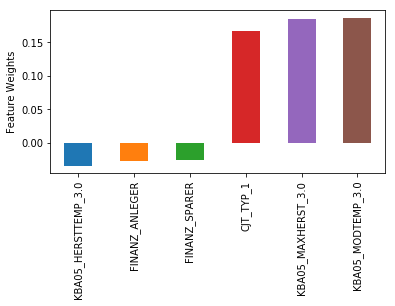

```python
# Map weights for the first principal component to corresponding feature names
# and then print the linked values, sorted by weight.
pca_results(azdias_final, pca, component_number = 1)
```

|  | Explained Variance | LNR | AKT_DAT_KL | ANZ_HAUSHALTE_AKTIV | ANZ_HH_TITEL | ANZ_KINDER | ANZ_PERSONEN | ANZ_STATISTISCHE_HAUSHALTE | ANZ_TITEL | ARBEIT | ... | SHOPPER_TYP_2.0 | SHOPPER_TYP_3.0 | TITEL_KZ_0.0 | TITEL_KZ_1.0 | TITEL_KZ_2.0 | TITEL_KZ_3.0 | TITEL_KZ_4.0 | TITEL_KZ_5.0 | VERS_TYP_1.0 | VERS_TYP_2.0 |
| --- | --- | --- | --- | --- | --- | --- | --- | --- | --- | --- | --- | --- | --- | --- | --- | --- | --- | --- | --- | --- | --- |
| Dimension 1 | 0.0724 | 0.0062 | 0.0074 | 0.0224 | 0.0109 | -0.0084 | -0.0099 | 0.0278 | 0.0021 | -0.0067 | ... | -0.0067 | 0.0061 | -0.0023 | 0.0019 | 0.0010 | 0.0010 | 0.0014 | 0.0003 | -0.0075 | 0.0068 |
| Dimension 2 | 0.0679 | -0.0239 | 0.0647 | 0.0860 | 0.0218 | -0.0213 | -0.0685 | 0.0837 | -0.0020 | 0.0998 | ... | 0.0234 | -0.0197 | 0.0000 | 0.0003 | -0.0001 | -0.0006 | 0.0001 | -0.0010 | -0.0220 | 0.0125 |
| Dimension 3 | 0.0457 | -0.0932 | -0.0068 | -0.0062 | -0.0218 | -0.0037 | 0.0012 | -0.0038 | -0.0115 | 0.0565 | ... | 0.0059 | -0.0079 | 0.0099 | -0.0095 | -0.0000 | -0.0021 | -0.0011 | -0.0015 | 0.0165 | -0.0106 |
| Dimension 4 | 0.0400 | 0.0181 | 0.0455 | -0.0187 | -0.0182 | 0.0730 | 0.0464 | -0.0210 | -0.0095 | -0.0382 | ... | 0.0235 | -0.0652 | 0.0111 | -0.0102 | -0.0003 | -0.0023 | -0.0026 | -0.0030 | 0.0135 | -0.0159 |
| Dimension 5 | 0.0271 | -0.0650 | -0.1159 | 0.0110 | 0.0126 | 0.0641 | 0.1509 | 0.0108 | 0.0138 | 0.0792 | ... | -0.0051 | 0.0364 | -0.0079 | 0.0070 | -0.0000 | 0.0013 | 0.0022 | 0.0033 | 0.0053 | 0.0106 |
| Dimension 6 | 0.0221 | -0.1177 | 0.0490 | 0.0134 | 0.0120 | -0.0187 | -0.0575 | 0.0159 | 0.0008 | 0.0611 | ... | -0.0133 | 0.0022 | -0.0016 | 0.0013 | -0.0002 | 0.0004 | 0.0010 | 0.0007 | 0.0150 | -0.0135 |
| Dimension 7 | 0.0198 | -0.0084 | -0.0032 | -0.0052 | 0.0009 | -0.0294 | -0.0024 | -0.0062 | 0.0087 | -0.0035 | ... | -0.0972 | -0.0709 | -0.0124 | 0.0118 | 0.0005 | 0.0035 | 0.0032 | 0.0004 | -0.0067 | 0.0170 |
| Dimension 8 | 0.0167 | -0.0270 | -0.0185 | 0.0207 | 0.0153 | 0.0099 | 0.0180 | 0.0185 | 0.0065 | -0.0891 | ... | 0.0117 | 0.0001 | -0.0067 | 0.0069 | -0.0010 | -0.0003 | 0.0003 | 0.0009 | 0.0154 | -0.0182 |
| Dimension 9 | 0.0150 | 0.0711 | -0.0088 | 0.0475 | 0.0008 | 0.0094 | 0.0208 | 0.0459 | -0.0103 | -0.0080 | ... | 0.0016 | -0.0127 | 0.0099 | -0.0095 | 0.0002 | -0.0012 | -0.0011 | -0.0023 | -0.0160 | 0.0086 |
| Dimension 10 | 0.0135 | -0.0243 | 0.0129 | -0.0303 | 0.0169 | -0.0116 | -0.0324 | -0.0299 | 0.0140 | 0.0127 | ... | -0.0123 | 0.0179 | -0.0130 | 0.0122 | -0.0003 | 0.0024 | 0.0027 | 0.0026 | 0.0091 | -0.0013 |
| Dimension 11 | 0.0122 | -0.0656 | 0.0042 | 0.0304 | 0.0282 | 0.0073 | 0.0080 | 0.0315 | 0.0190 | 0.0289 | ... | -0.0140 | 0.0168 | -0.0182 | 0.0170 | 0.0008 | 0.0041 | 0.0033 | 0.0038 | 0.0056 | -0.0101 |
| Dimension 12 | 0.0110 | 0.0268 | -0.0182 | 0.1437 | 0.0542 | 0.0009 | 0.0227 | 0.1449 | -0.0021 | -0.0455 | ... | -0.0148 | 0.0037 | 0.0018 | -0.0018 | -0.0010 | 0.0007 | 0.0002 | -0.0013 | 0.0028 | -0.0175 |
| Dimension 13 | 0.0106 | -0.0010 | -0.0066 | 0.0253 | 0.0234 | -0.0061 | -0.0121 | 0.0240 | 0.0087 | -0.0158 | ... | 0.0254 | -0.0234 | -0.0105 | 0.0101 | 0.0019 | 0.0016 | 0.0009 | 0.0019 | -0.0142 | 0.0193 |
| Dimension 14 | 0.0096 | -0.0942 | 0.0019 | 0.1043 | 0.0789 | -0.0026 | -0.0327 | 0.1049 | 0.0593 | -0.0595 | ... | 0.0197 | -0.0204 | -0.0625 | 0.0600 | 0.0015 | 0.0069 | 0.0092 | 0.0132 | -0.0214 | 0.0464 |
| Dimension 15 | 0.0088 | 0.0477 | 0.0038 | 0.1010 | 0.0887 | -0.0155 | 0.0013 | 0.1029 | 0.0572 | -0.1221 | ... | -0.0844 | 0.0733 | -0.0607 | 0.0580 | 0.0037 | 0.0079 | 0.0110 | 0.0112 | 0.0765 | -0.1052 |
| Dimension 16 | 0.0082 | -0.0150 | 0.0326 | 0.0353 | 0.0857 | -0.0081 | 0.0727 | 0.0355 | 0.1943 | -0.0183 | ... | -0.0600 | 0.0334 | -0.2073 | 0.1967 | 0.0083 | 0.0275 | 0.0359 | 0.0461 | 0.0899 | -0.1561 |
| Dimension 17 | 0.0081 | 0.0212 | -0.0349 | 0.0958 | 0.0406 | 0.0153 | -0.0978 | 0.0960 | -0.0433 | -0.0649 | ... | 0.0477 | 0.0058 | 0.0427 | -0.0401 | -0.0029 | -0.0073 | -0.0076 | -0.0100 | -0.0728 | 0.1610 |
| Dimension 18 | 0.0080 | 0.0365 | 0.0127 | -0.0621 | -0.0009 | -0.0050 | 0.0284 | -0.0633 | 0.0693 | -0.0248 | ... | -0.0028 | -0.0004 | -0.0740 | 0.0707 | 0.0016 | 0.0107 | 0.0113 | 0.0155 | 0.0358 | -0.0536 |
| Dimension 19 | 0.0077 | -0.0046 | 0.0064 | 0.0438 | 0.1567 | 0.0154 | 0.0148 | 0.0454 | 0.4011 | 0.0413 | ... | 0.0470 | -0.0282 | -0.4380 | 0.4172 | 0.0201 | 0.0543 | 0.0739 | 0.0949 | -0.0466 | 0.0703 |
| Dimension 20 | 0.0075 | 0.0428 | 0.0083 | -0.0541 | 0.0150 | -0.0490 | -0.0115 | -0.0550 | 0.1400 | 0.0219 | ... | 0.0770 | -0.0951 | -0.1533 | 0.1468 | 0.0070 | 0.0180 | 0.0217 | 0.0337 | -0.2279 | 0.2467 |
| Dimension 21 | 0.0072 | -0.0094 | -0.0182 | -0.0652 | -0.0083 | -0.0318 | -0.0459 | -0.0643 | 0.0809 | 0.0141 | ... | -0.0046 | 0.0504 | -0.0893 | 0.0841 | 0.0044 | 0.0105 | 0.0161 | 0.0230 | 0.0788 | -0.0341 |
| Dimension 22 | 0.0071 | -0.0512 | 0.0579 | 0.1149 | 0.0137 | 0.0059 | 0.1435 | 0.1130 | -0.0839 | 0.0509 | ... | 0.0457 | -0.0893 | 0.0990 | -0.0942 | -0.0023 | -0.0139 | -0.0144 | -0.0229 | -0.1619 | 0.1021 |
| Dimension 23 | 0.0070 | 0.0598 | -0.0123 | -0.0187 | -0.0010 | 0.0985 | 0.0118 | -0.0188 | 0.0680 | -0.0040 | ... | 0.0062 | -0.0791 | -0.0782 | 0.0751 | 0.0031 | 0.0090 | 0.0110 | 0.0164 | -0.1058 | 0.0256 |
| Dimension 24 | 0.0066 | -0.0481 | -0.0743 | -0.0008 | 0.0150 | -0.0232 | -0.1397 | -0.0021 | 0.0691 | 0.1228 | ... | -0.0401 | 0.0245 | -0.0860 | 0.0816 | 0.0058 | 0.0125 | 0.0141 | 0.0190 | 0.1216 | -0.1453 |
| Dimension 25 | 0.0064 | -0.0309 | -0.0153 | -0.0532 | -0.0137 | 0.0018 | -0.0422 | -0.0559 | 0.0224 | 0.0395 | ... | -0.0300 | -0.0684 | -0.0271 | 0.0258 | -0.0010 | 0.0041 | 0.0051 | 0.0055 | -0.1917 | 0.1179 |
| Dimension 26 | 0.0061 | 0.0008 | -0.0068 | 0.0560 | 0.0425 | 0.0009 | -0.0054 | 0.0547 | 0.0872 | -0.1130 | ... | -0.0370 | 0.0352 | -0.0986 | 0.0924 | 0.0047 | 0.0142 | 0.0189 | 0.0250 | -0.1065 | 0.1040 |
| Dimension 27 | 0.0060 | 0.0233 | -0.0197 | 0.0303 | 0.0118 | -0.0434 | -0.0506 | 0.0296 | 0.0543 | -0.0108 | ... | 0.0978 | -0.0095 | -0.0673 | 0.0628 | 0.0021 | 0.0124 | 0.0138 | 0.0158 | 0.2736 | -0.1989 |
| Dimension 28 | 0.0059 | 0.0038 | 0.0839 | -0.0560 | -0.0315 | -0.2192 | -0.0544 | -0.0551 | 0.0043 | 0.0242 | ... | -0.0150 | -0.0200 | -0.0040 | 0.0038 | 0.0006 | 0.0012 | -0.0007 | 0.0014 | -0.1350 | 0.1527 |
| Dimension 29 | 0.0057 | 0.0001 | -0.0022 | 0.1623 | 0.0862 | -0.0546 | -0.0488 | 0.1636 | -0.0422 | 0.0207 | ... | 0.0395 | 0.0039 | 0.0493 | -0.0471 | -0.0009 | -0.0074 | -0.0073 | -0.0102 | 0.0510 | -0.0370 |
| Dimension 30 | 0.0055 | 0.0165 | -0.0397 | -0.0638 | -0.0394 | -0.0574 | -0.0978 | -0.0657 | 0.0041 | -0.0502 | ... | 0.0398 | -0.1099 | -0.0128 | 0.0122 | 0.0001 | 0.0040 | 0.0039 | -0.0003 | -0.0001 | -0.0419 |
| ... | ... | ... | ... | ... | ... | ... | ... | ... | ... | ... | ... | ... | ... | ... | ... | ... | ... | ... | ... | ... | ... |
| Dimension 171 | 0.0015 | 0.0322 | -0.0431 | 0.0030 | -0.0133 | 0.0023 | 0.0115 | 0.0028 | 0.0179 | 0.0038 | ... | 0.0111 | -0.0090 | 0.0101 | -0.0085 | -0.0025 | -0.0049 | -0.0060 | -0.0013 | 0.0046 | -0.0002 |
| Dimension 172 | 0.0015 | -0.0601 | -0.0614 | -0.0485 | 0.0964 | 0.0390 | -0.0170 | -0.0482 | 0.0122 | -0.0025 | ... | 0.0234 | -0.0186 | 0.0113 | -0.0108 | -0.0005 | 0.0029 | -0.0033 | -0.0042 | -0.0005 | -0.0041 |
| Dimension 173 | 0.0015 | -0.0404 | 0.1499 | -0.0573 | 0.0768 | -0.0249 | 0.0044 | -0.0563 | 0.0009 | 0.0461 | ... | -0.0377 | 0.0296 | 0.0057 | -0.0046 | -0.0015 | -0.0042 | -0.0054 | 0.0011 | -0.0281 | 0.0250 |
| Dimension 174 | 0.0015 | 0.0792 | 0.0464 | -0.0256 | 0.0341 | 0.0040 | -0.0007 | -0.0238 | 0.0189 | 0.0250 | ... | -0.0133 | -0.0044 | 0.0109 | -0.0105 | -0.0017 | -0.0025 | 0.0014 | -0.0030 | 0.0014 | 0.0003 |
| Dimension 175 | 0.0015 | -0.0114 | -0.0829 | -0.0197 | 0.0019 | -0.0060 | 0.0032 | -0.0195 | 0.0078 | -0.0117 | ... | 0.0070 | -0.0019 | -0.0005 | -0.0001 | -0.0001 | 0.0019 | 0.0018 | 0.0001 | 0.0217 | -0.0225 |
| Dimension 176 | 0.0015 | -0.1147 | -0.1896 | 0.0314 | -0.0238 | 0.0377 | 0.0373 | 0.0270 | -0.0193 | 0.0016 | ... | 0.0193 | -0.0069 | -0.0192 | 0.0184 | 0.0008 | 0.0017 | 0.0036 | 0.0041 | 0.0078 | 0.0072 |
| Dimension 177 | 0.0015 | -0.1145 | -0.0170 | 0.0039 | -0.0138 | -0.0242 | 0.0451 | 0.0018 | 0.0220 | 0.0602 | ... | -0.0082 | 0.0145 | 0.0100 | -0.0094 | -0.0009 | 0.0015 | -0.0001 | -0.0057 | 0.0140 | 0.0070 |
| Dimension 178 | 0.0015 | -0.2404 | -0.0411 | -0.0291 | 0.0602 | -0.0392 | 0.0009 | -0.0282 | 0.0050 | 0.0750 | ... | -0.0142 | 0.0045 | 0.0054 | -0.0050 | -0.0012 | 0.0019 | -0.0029 | -0.0020 | -0.0115 | 0.0096 |
| Dimension 179 | 0.0015 | 0.1285 | 0.0751 | -0.0001 | -0.0110 | -0.0256 | -0.0198 | -0.0000 | 0.0174 | -0.0143 | ... | 0.0122 | -0.0307 | 0.0098 | -0.0099 | 0.0034 | 0.0014 | -0.0015 | -0.0024 | 0.0067 | -0.0156 |
| Dimension 180 | 0.0014 | 0.0713 | 0.0058 | -0.0123 | 0.0254 | -0.0419 | -0.0143 | -0.0123 | -0.0160 | -0.0164 | ... | 0.0195 | -0.0312 | -0.0127 | 0.0113 | 0.0006 | 0.0039 | 0.0036 | 0.0036 | 0.0042 | -0.0053 |
| Dimension 181 | 0.0014 | -0.0446 | -0.1597 | -0.0157 | 0.0268 | 0.0540 | 0.0387 | -0.0191 | 0.0032 | 0.0150 | ... | -0.0013 | -0.0103 | 0.0048 | -0.0048 | -0.0019 | 0.0036 | -0.0004 | -0.0028 | -0.0172 | 0.0296 |
| Dimension 182 | 0.0014 | 0.0518 | 0.1424 | 0.0282 | -0.0293 | 0.0717 | -0.0103 | 0.0294 | -0.0308 | -0.0118 | ... | 0.0367 | -0.0136 | -0.0102 | 0.0101 | 0.0001 | 0.0021 | 0.0006 | 0.0007 | 0.0162 | -0.0135 |
| Dimension 183 | 0.0014 | -0.0287 | -0.0267 | -0.0611 | 0.0654 | -0.1112 | 0.0529 | -0.0614 | 0.0039 | 0.0182 | ... | -0.0112 | -0.0351 | -0.0060 | 0.0047 | 0.0002 | 0.0014 | 0.0019 | 0.0048 | -0.0193 | 0.0023 |
| Dimension 184 | 0.0014 | 0.0062 | -0.2397 | -0.0340 | 0.0585 | 0.0250 | 0.0485 | -0.0344 | -0.0292 | -0.0109 | ... | 0.0020 | -0.0251 | -0.0124 | 0.0111 | 0.0037 | 0.0031 | 0.0029 | 0.0033 | -0.0278 | 0.0154 |
| Dimension 185 | 0.0014 | -0.0621 | 0.2602 | -0.0135 | 0.0203 | -0.0305 | -0.0160 | -0.0094 | -0.0234 | -0.0001 | ... | -0.0116 | -0.0067 | 0.0003 | -0.0008 | -0.0003 | 0.0017 | -0.0003 | 0.0010 | -0.0086 | -0.0142 |
| Dimension 186 | 0.0014 | -0.1188 | -0.1833 | -0.0113 | 0.0350 | 0.0216 | 0.0844 | -0.0140 | -0.0058 | 0.0077 | ... | 0.0253 | -0.0333 | 0.0014 | -0.0002 | -0.0017 | -0.0001 | -0.0064 | -0.0002 | -0.0016 | 0.0099 |
| Dimension 187 | 0.0013 | -0.0211 | -0.0177 | 0.0288 | -0.0375 | 0.1372 | 0.0520 | 0.0250 | 0.0243 | -0.0091 | ... | 0.0598 | -0.0323 | 0.0074 | -0.0073 | 0.0006 | 0.0026 | 0.0006 | -0.0044 | 0.0240 | -0.0083 |
| Dimension 188 | 0.0013 | -0.1428 | 0.0741 | 0.0297 | -0.0288 | 0.0445 | -0.0034 | 0.0300 | -0.0012 | -0.0072 | ... | 0.0084 | 0.0048 | -0.0036 | 0.0036 | -0.0038 | 0.0021 | -0.0006 | 0.0006 | 0.0054 | 0.0175 |
| Dimension 189 | 0.0013 | -0.1909 | 0.0723 | -0.0175 | 0.0262 | -0.0185 | -0.0191 | -0.0160 | -0.0120 | 0.0676 | ... | -0.0165 | 0.0112 | -0.0035 | 0.0025 | 0.0002 | 0.0015 | -0.0005 | 0.0045 | -0.0103 | 0.0071 |
| Dimension 190 | 0.0013 | 0.1330 | 0.0078 | -0.0121 | 0.0299 | 0.0043 | 0.0040 | -0.0135 | 0.0141 | -0.0502 | ... | 0.0142 | 0.0063 | 0.0121 | -0.0120 | -0.0011 | 0.0017 | -0.0022 | -0.0028 | 0.0011 | 0.0096 |
| Dimension 191 | 0.0013 | 0.1599 | -0.1876 | 0.0213 | -0.0184 | -0.0557 | 0.1296 | 0.0198 | 0.0404 | -0.0228 | ... | -0.0121 | 0.0367 | 0.0072 | -0.0069 | 0.0002 | 0.0002 | -0.0013 | -0.0020 | 0.0050 | 0.0116 |
| Dimension 192 | 0.0012 | -0.1433 | 0.0126 | 0.0020 | -0.0259 | -0.0010 | -0.0035 | 0.0005 | 0.0435 | 0.0204 | ... | 0.0025 | 0.0123 | 0.0171 | -0.0165 | -0.0013 | -0.0005 | -0.0014 | -0.0048 | -0.0027 | 0.0044 |
| Dimension 193 | 0.0012 | -0.0819 | -0.0624 | -0.0101 | 0.0199 | 0.0765 | 0.0387 | -0.0091 | -0.0248 | -0.0232 | ... | -0.0149 | 0.0301 | -0.0059 | 0.0055 | 0.0004 | 0.0008 | 0.0013 | 0.0012 | -0.0077 | 0.0222 |
| Dimension 194 | 0.0012 | -0.0084 | -0.1333 | 0.0120 | -0.0029 | -0.0361 | 0.1172 | 0.0124 | -0.0001 | 0.0088 | ... | -0.0352 | 0.0514 | -0.0037 | 0.0040 | -0.0005 | -0.0009 | 0.0029 | -0.0018 | 0.0020 | 0.0127 |
| Dimension 195 | 0.0012 | -0.0917 | -0.0249 | -0.0407 | 0.0345 | 0.0402 | 0.0148 | -0.0405 | -0.0312 | -0.0403 | ... | 0.0244 | 0.0031 | -0.0078 | 0.0074 | 0.0004 | 0.0003 | 0.0004 | 0.0028 | -0.0038 | -0.0023 |
| Dimension 196 | 0.0012 | 0.0458 | -0.0281 | 0.0069 | -0.0076 | 0.0015 | 0.0250 | 0.0028 | 0.0302 | 0.0173 | ... | -0.0041 | 0.0350 | 0.0103 | -0.0101 | -0.0018 | -0.0008 | 0.0009 | -0.0029 | -0.0013 | -0.0105 |
| Dimension 197 | 0.0011 | -0.1034 | 0.0472 | -0.0084 | -0.0120 | 0.2783 | -0.0619 | -0.0064 | 0.0008 | -0.0060 | ... | 0.0256 | -0.0260 | -0.0011 | 0.0017 | -0.0006 | -0.0009 | 0.0012 | -0.0022 | 0.0082 | 0.0003 |
| Dimension 198 | 0.0011 | 0.0545 | 0.0913 | -0.0014 | 0.0157 | 0.2236 | -0.1111 | -0.0015 | -0.0097 | -0.0191 | ... | -0.0361 | 0.0505 | -0.0021 | 0.0022 | -0.0015 | 0.0005 | -0.0009 | 0.0008 | -0.0127 | 0.0386 |
| Dimension 199 | 0.0011 | -0.0560 | 0.0345 | 0.0184 | 0.0006 | -0.0222 | 0.0021 | 0.0147 | 0.0028 | -0.0017 | ... | 0.0017 | 0.0014 | 0.0001 | 0.0002 | -0.0008 | 0.0003 | -0.0010 | -0.0006 | -0.0133 | -0.0027 |
| Dimension 200 | 0.0011 | 0.0003 | 0.0027 | -0.0016 | 0.0270 | 0.3956 | -0.1129 | -0.0011 | -0.0238 | 0.0178 | ... | 0.0236 | -0.0089 | -0.0118 | 0.0110 | 0.0037 | 0.0023 | 0.0027 | 0.0021 | 0.0245 | -0.0341 |

200 rows × 370 columns

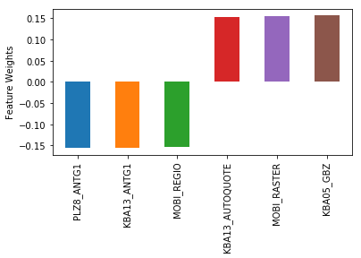

```python
# Map weights for the second principal component to corresponding feature names
# and then print the linked values, sorted by weight.
pca_results(azdias_final, pca, component_number = 2)
```

|  | Explained Variance | LNR | AKT_DAT_KL | ANZ_HAUSHALTE_AKTIV | ANZ_HH_TITEL | ANZ_KINDER | ANZ_PERSONEN | ANZ_STATISTISCHE_HAUSHALTE | ANZ_TITEL | ARBEIT | ... | SHOPPER_TYP_2.0 | SHOPPER_TYP_3.0 | TITEL_KZ_0.0 | TITEL_KZ_1.0 | TITEL_KZ_2.0 | TITEL_KZ_3.0 | TITEL_KZ_4.0 | TITEL_KZ_5.0 | VERS_TYP_1.0 | VERS_TYP_2.0 |
| --- | --- | --- | --- | --- | --- | --- | --- | --- | --- | --- | --- | --- | --- | --- | --- | --- | --- | --- | --- | --- | --- |
| Dimension 1 | 0.0724 | 0.0062 | 0.0074 | 0.0224 | 0.0109 | -0.0084 | -0.0099 | 0.0278 | 0.0021 | -0.0067 | ... | -0.0067 | 0.0061 | -0.0023 | 0.0019 | 0.0010 | 0.0010 | 0.0014 | 0.0003 | -0.0075 | 0.0068 |
| Dimension 2 | 0.0679 | -0.0239 | 0.0647 | 0.0860 | 0.0218 | -0.0213 | -0.0685 | 0.0837 | -0.0020 | 0.0998 | ... | 0.0234 | -0.0197 | 0.0000 | 0.0003 | -0.0001 | -0.0006 | 0.0001 | -0.0010 | -0.0220 | 0.0125 |
| Dimension 3 | 0.0457 | -0.0932 | -0.0068 | -0.0062 | -0.0218 | -0.0037 | 0.0012 | -0.0038 | -0.0115 | 0.0565 | ... | 0.0059 | -0.0079 | 0.0099 | -0.0095 | -0.0000 | -0.0021 | -0.0011 | -0.0015 | 0.0165 | -0.0106 |
| Dimension 4 | 0.0400 | 0.0181 | 0.0455 | -0.0187 | -0.0182 | 0.0730 | 0.0464 | -0.0210 | -0.0095 | -0.0382 | ... | 0.0235 | -0.0652 | 0.0111 | -0.0102 | -0.0003 | -0.0023 | -0.0026 | -0.0030 | 0.0135 | -0.0159 |
| Dimension 5 | 0.0271 | -0.0650 | -0.1159 | 0.0110 | 0.0126 | 0.0641 | 0.1509 | 0.0108 | 0.0138 | 0.0792 | ... | -0.0051 | 0.0364 | -0.0079 | 0.0070 | -0.0000 | 0.0013 | 0.0022 | 0.0033 | 0.0053 | 0.0106 |
| Dimension 6 | 0.0221 | -0.1177 | 0.0490 | 0.0134 | 0.0120 | -0.0187 | -0.0575 | 0.0159 | 0.0008 | 0.0611 | ... | -0.0133 | 0.0022 | -0.0016 | 0.0013 | -0.0002 | 0.0004 | 0.0010 | 0.0007 | 0.0150 | -0.0135 |
| Dimension 7 | 0.0198 | -0.0084 | -0.0032 | -0.0052 | 0.0009 | -0.0294 | -0.0024 | -0.0062 | 0.0087 | -0.0035 | ... | -0.0972 | -0.0709 | -0.0124 | 0.0118 | 0.0005 | 0.0035 | 0.0032 | 0.0004 | -0.0067 | 0.0170 |
| Dimension 8 | 0.0167 | -0.0270 | -0.0185 | 0.0207 | 0.0153 | 0.0099 | 0.0180 | 0.0185 | 0.0065 | -0.0891 | ... | 0.0117 | 0.0001 | -0.0067 | 0.0069 | -0.0010 | -0.0003 | 0.0003 | 0.0009 | 0.0154 | -0.0182 |
| Dimension 9 | 0.0150 | 0.0711 | -0.0088 | 0.0475 | 0.0008 | 0.0094 | 0.0208 | 0.0459 | -0.0103 | -0.0080 | ... | 0.0016 | -0.0127 | 0.0099 | -0.0095 | 0.0002 | -0.0012 | -0.0011 | -0.0023 | -0.0160 | 0.0086 |
| Dimension 10 | 0.0135 | -0.0243 | 0.0129 | -0.0303 | 0.0169 | -0.0116 | -0.0324 | -0.0299 | 0.0140 | 0.0127 | ... | -0.0123 | 0.0179 | -0.0130 | 0.0122 | -0.0003 | 0.0024 | 0.0027 | 0.0026 | 0.0091 | -0.0013 |
| Dimension 11 | 0.0122 | -0.0656 | 0.0042 | 0.0304 | 0.0282 | 0.0073 | 0.0080 | 0.0315 | 0.0190 | 0.0289 | ... | -0.0140 | 0.0168 | -0.0182 | 0.0170 | 0.0008 | 0.0041 | 0.0033 | 0.0038 | 0.0056 | -0.0101 |
| Dimension 12 | 0.0110 | 0.0268 | -0.0182 | 0.1437 | 0.0542 | 0.0009 | 0.0227 | 0.1449 | -0.0021 | -0.0455 | ... | -0.0148 | 0.0037 | 0.0018 | -0.0018 | -0.0010 | 0.0007 | 0.0002 | -0.0013 | 0.0028 | -0.0175 |
| Dimension 13 | 0.0106 | -0.0010 | -0.0066 | 0.0253 | 0.0234 | -0.0061 | -0.0121 | 0.0240 | 0.0087 | -0.0158 | ... | 0.0254 | -0.0234 | -0.0105 | 0.0101 | 0.0019 | 0.0016 | 0.0009 | 0.0019 | -0.0142 | 0.0193 |
| Dimension 14 | 0.0096 | -0.0942 | 0.0019 | 0.1043 | 0.0789 | -0.0026 | -0.0327 | 0.1049 | 0.0593 | -0.0595 | ... | 0.0197 | -0.0204 | -0.0625 | 0.0600 | 0.0015 | 0.0069 | 0.0092 | 0.0132 | -0.0214 | 0.0464 |
| Dimension 15 | 0.0088 | 0.0477 | 0.0038 | 0.1010 | 0.0887 | -0.0155 | 0.0013 | 0.1029 | 0.0572 | -0.1221 | ... | -0.0844 | 0.0733 | -0.0607 | 0.0580 | 0.0037 | 0.0079 | 0.0110 | 0.0112 | 0.0765 | -0.1052 |
| Dimension 16 | 0.0082 | -0.0150 | 0.0326 | 0.0353 | 0.0857 | -0.0081 | 0.0727 | 0.0355 | 0.1943 | -0.0183 | ... | -0.0600 | 0.0334 | -0.2073 | 0.1967 | 0.0083 | 0.0275 | 0.0359 | 0.0461 | 0.0899 | -0.1561 |
| Dimension 17 | 0.0081 | 0.0212 | -0.0349 | 0.0958 | 0.0406 | 0.0153 | -0.0978 | 0.0960 | -0.0433 | -0.0649 | ... | 0.0477 | 0.0058 | 0.0427 | -0.0401 | -0.0029 | -0.0073 | -0.0076 | -0.0100 | -0.0728 | 0.1610 |
| Dimension 18 | 0.0080 | 0.0365 | 0.0127 | -0.0621 | -0.0009 | -0.0050 | 0.0284 | -0.0633 | 0.0693 | -0.0248 | ... | -0.0028 | -0.0004 | -0.0740 | 0.0707 | 0.0016 | 0.0107 | 0.0113 | 0.0155 | 0.0358 | -0.0536 |
| Dimension 19 | 0.0077 | -0.0046 | 0.0064 | 0.0438 | 0.1567 | 0.0154 | 0.0148 | 0.0454 | 0.4011 | 0.0413 | ... | 0.0470 | -0.0282 | -0.4380 | 0.4172 | 0.0201 | 0.0543 | 0.0739 | 0.0949 | -0.0466 | 0.0703 |
| Dimension 20 | 0.0075 | 0.0428 | 0.0083 | -0.0541 | 0.0150 | -0.0490 | -0.0115 | -0.0550 | 0.1400 | 0.0219 | ... | 0.0770 | -0.0951 | -0.1533 | 0.1468 | 0.0070 | 0.0180 | 0.0217 | 0.0337 | -0.2279 | 0.2467 |
| Dimension 21 | 0.0072 | -0.0094 | -0.0182 | -0.0652 | -0.0083 | -0.0318 | -0.0459 | -0.0643 | 0.0809 | 0.0141 | ... | -0.0046 | 0.0504 | -0.0893 | 0.0841 | 0.0044 | 0.0105 | 0.0161 | 0.0230 | 0.0788 | -0.0341 |
| Dimension 22 | 0.0071 | -0.0512 | 0.0579 | 0.1149 | 0.0137 | 0.0059 | 0.1435 | 0.1130 | -0.0839 | 0.0509 | ... | 0.0457 | -0.0893 | 0.0990 | -0.0942 | -0.0023 | -0.0139 | -0.0144 | -0.0229 | -0.1619 | 0.1021 |
| Dimension 23 | 0.0070 | 0.0598 | -0.0123 | -0.0187 | -0.0010 | 0.0985 | 0.0118 | -0.0188 | 0.0680 | -0.0040 | ... | 0.0062 | -0.0791 | -0.0782 | 0.0751 | 0.0031 | 0.0090 | 0.0110 | 0.0164 | -0.1058 | 0.0256 |
| Dimension 24 | 0.0066 | -0.0481 | -0.0743 | -0.0008 | 0.0150 | -0.0232 | -0.1397 | -0.0021 | 0.0691 | 0.1228 | ... | -0.0401 | 0.0245 | -0.0860 | 0.0816 | 0.0058 | 0.0125 | 0.0141 | 0.0190 | 0.1216 | -0.1453 |
| Dimension 25 | 0.0064 | -0.0309 | -0.0153 | -0.0532 | -0.0137 | 0.0018 | -0.0422 | -0.0559 | 0.0224 | 0.0395 | ... | -0.0300 | -0.0684 | -0.0271 | 0.0258 | -0.0010 | 0.0041 | 0.0051 | 0.0055 | -0.1917 | 0.1179 |
| Dimension 26 | 0.0061 | 0.0008 | -0.0068 | 0.0560 | 0.0425 | 0.0009 | -0.0054 | 0.0547 | 0.0872 | -0.1130 | ... | -0.0370 | 0.0352 | -0.0986 | 0.0924 | 0.0047 | 0.0142 | 0.0189 | 0.0250 | -0.1065 | 0.1040 |
| Dimension 27 | 0.0060 | 0.0233 | -0.0197 | 0.0303 | 0.0118 | -0.0434 | -0.0506 | 0.0296 | 0.0543 | -0.0108 | ... | 0.0978 | -0.0095 | -0.0673 | 0.0628 | 0.0021 | 0.0124 | 0.0138 | 0.0158 | 0.2736 | -0.1989 |
| Dimension 28 | 0.0059 | 0.0038 | 0.0839 | -0.0560 | -0.0315 | -0.2192 | -0.0544 | -0.0551 | 0.0043 | 0.0242 | ... | -0.0150 | -0.0200 | -0.0040 | 0.0038 | 0.0006 | 0.0012 | -0.0007 | 0.0014 | -0.1350 | 0.1527 |
| Dimension 29 | 0.0057 | 0.0001 | -0.0022 | 0.1623 | 0.0862 | -0.0546 | -0.0488 | 0.1636 | -0.0422 | 0.0207 | ... | 0.0395 | 0.0039 | 0.0493 | -0.0471 | -0.0009 | -0.0074 | -0.0073 | -0.0102 | 0.0510 | -0.0370 |
| Dimension 30 | 0.0055 | 0.0165 | -0.0397 | -0.0638 | -0.0394 | -0.0574 | -0.0978 | -0.0657 | 0.0041 | -0.0502 | ... | 0.0398 | -0.1099 | -0.0128 | 0.0122 | 0.0001 | 0.0040 | 0.0039 | -0.0003 | -0.0001 | -0.0419 |
| ... | ... | ... | ... | ... | ... | ... | ... | ... | ... | ... | ... | ... | ... | ... | ... | ... | ... | ... | ... | ... | ... |
| Dimension 171 | 0.0015 | 0.0322 | -0.0431 | 0.0030 | -0.0133 | 0.0023 | 0.0115 | 0.0028 | 0.0179 | 0.0038 | ... | 0.0111 | -0.0090 | 0.0101 | -0.0085 | -0.0025 | -0.0049 | -0.0060 | -0.0013 | 0.0046 | -0.0002 |
| Dimension 172 | 0.0015 | -0.0601 | -0.0614 | -0.0485 | 0.0964 | 0.0390 | -0.0170 | -0.0482 | 0.0122 | -0.0025 | ... | 0.0234 | -0.0186 | 0.0113 | -0.0108 | -0.0005 | 0.0029 | -0.0033 | -0.0042 | -0.0005 | -0.0041 |
| Dimension 173 | 0.0015 | -0.0404 | 0.1499 | -0.0573 | 0.0768 | -0.0249 | 0.0044 | -0.0563 | 0.0009 | 0.0461 | ... | -0.0377 | 0.0296 | 0.0057 | -0.0046 | -0.0015 | -0.0042 | -0.0054 | 0.0011 | -0.0281 | 0.0250 |
| Dimension 174 | 0.0015 | 0.0792 | 0.0464 | -0.0256 | 0.0341 | 0.0040 | -0.0007 | -0.0238 | 0.0189 | 0.0250 | ... | -0.0133 | -0.0044 | 0.0109 | -0.0105 | -0.0017 | -0.0025 | 0.0014 | -0.0030 | 0.0014 | 0.0003 |
| Dimension 175 | 0.0015 | -0.0114 | -0.0829 | -0.0197 | 0.0019 | -0.0060 | 0.0032 | -0.0195 | 0.0078 | -0.0117 | ... | 0.0070 | -0.0019 | -0.0005 | -0.0001 | -0.0001 | 0.0019 | 0.0018 | 0.0001 | 0.0217 | -0.0225 |
| Dimension 176 | 0.0015 | -0.1147 | -0.1896 | 0.0314 | -0.0238 | 0.0377 | 0.0373 | 0.0270 | -0.0193 | 0.0016 | ... | 0.0193 | -0.0069 | -0.0192 | 0.0184 | 0.0008 | 0.0017 | 0.0036 | 0.0041 | 0.0078 | 0.0072 |
| Dimension 177 | 0.0015 | -0.1145 | -0.0170 | 0.0039 | -0.0138 | -0.0242 | 0.0451 | 0.0018 | 0.0220 | 0.0602 | ... | -0.0082 | 0.0145 | 0.0100 | -0.0094 | -0.0009 | 0.0015 | -0.0001 | -0.0057 | 0.0140 | 0.0070 |
| Dimension 178 | 0.0015 | -0.2404 | -0.0411 | -0.0291 | 0.0602 | -0.0392 | 0.0009 | -0.0282 | 0.0050 | 0.0750 | ... | -0.0142 | 0.0045 | 0.0054 | -0.0050 | -0.0012 | 0.0019 | -0.0029 | -0.0020 | -0.0115 | 0.0096 |
| Dimension 179 | 0.0015 | 0.1285 | 0.0751 | -0.0001 | -0.0110 | -0.0256 | -0.0198 | -0.0000 | 0.0174 | -0.0143 | ... | 0.0122 | -0.0307 | 0.0098 | -0.0099 | 0.0034 | 0.0014 | -0.0015 | -0.0024 | 0.0067 | -0.0156 |
| Dimension 180 | 0.0014 | 0.0713 | 0.0058 | -0.0123 | 0.0254 | -0.0419 | -0.0143 | -0.0123 | -0.0160 | -0.0164 | ... | 0.0195 | -0.0312 | -0.0127 | 0.0113 | 0.0006 | 0.0039 | 0.0036 | 0.0036 | 0.0042 | -0.0053 |
| Dimension 181 | 0.0014 | -0.0446 | -0.1597 | -0.0157 | 0.0268 | 0.0540 | 0.0387 | -0.0191 | 0.0032 | 0.0150 | ... | -0.0013 | -0.0103 | 0.0048 | -0.0048 | -0.0019 | 0.0036 | -0.0004 | -0.0028 | -0.0172 | 0.0296 |
| Dimension 182 | 0.0014 | 0.0518 | 0.1424 | 0.0282 | -0.0293 | 0.0717 | -0.0103 | 0.0294 | -0.0308 | -0.0118 | ... | 0.0367 | -0.0136 | -0.0102 | 0.0101 | 0.0001 | 0.0021 | 0.0006 | 0.0007 | 0.0162 | -0.0135 |
| Dimension 183 | 0.0014 | -0.0287 | -0.0267 | -0.0611 | 0.0654 | -0.1112 | 0.0529 | -0.0614 | 0.0039 | 0.0182 | ... | -0.0112 | -0.0351 | -0.0060 | 0.0047 | 0.0002 | 0.0014 | 0.0019 | 0.0048 | -0.0193 | 0.0023 |
| Dimension 184 | 0.0014 | 0.0062 | -0.2397 | -0.0340 | 0.0585 | 0.0250 | 0.0485 | -0.0344 | -0.0292 | -0.0109 | ... | 0.0020 | -0.0251 | -0.0124 | 0.0111 | 0.0037 | 0.0031 | 0.0029 | 0.0033 | -0.0278 | 0.0154 |
| Dimension 185 | 0.0014 | -0.0621 | 0.2602 | -0.0135 | 0.0203 | -0.0305 | -0.0160 | -0.0094 | -0.0234 | -0.0001 | ... | -0.0116 | -0.0067 | 0.0003 | -0.0008 | -0.0003 | 0.0017 | -0.0003 | 0.0010 | -0.0086 | -0.0142 |
| Dimension 186 | 0.0014 | -0.1188 | -0.1833 | -0.0113 | 0.0350 | 0.0216 | 0.0844 | -0.0140 | -0.0058 | 0.0077 | ... | 0.0253 | -0.0333 | 0.0014 | -0.0002 | -0.0017 | -0.0001 | -0.0064 | -0.0002 | -0.0016 | 0.0099 |
| Dimension 187 | 0.0013 | -0.0211 | -0.0177 | 0.0288 | -0.0375 | 0.1372 | 0.0520 | 0.0250 | 0.0243 | -0.0091 | ... | 0.0598 | -0.0323 | 0.0074 | -0.0073 | 0.0006 | 0.0026 | 0.0006 | -0.0044 | 0.0240 | -0.0083 |
| Dimension 188 | 0.0013 | -0.1428 | 0.0741 | 0.0297 | -0.0288 | 0.0445 | -0.0034 | 0.0300 | -0.0012 | -0.0072 | ... | 0.0084 | 0.0048 | -0.0036 | 0.0036 | -0.0038 | 0.0021 | -0.0006 | 0.0006 | 0.0054 | 0.0175 |
| Dimension 189 | 0.0013 | -0.1909 | 0.0723 | -0.0175 | 0.0262 | -0.0185 | -0.0191 | -0.0160 | -0.0120 | 0.0676 | ... | -0.0165 | 0.0112 | -0.0035 | 0.0025 | 0.0002 | 0.0015 | -0.0005 | 0.0045 | -0.0103 | 0.0071 |
| Dimension 190 | 0.0013 | 0.1330 | 0.0078 | -0.0121 | 0.0299 | 0.0043 | 0.0040 | -0.0135 | 0.0141 | -0.0502 | ... | 0.0142 | 0.0063 | 0.0121 | -0.0120 | -0.0011 | 0.0017 | -0.0022 | -0.0028 | 0.0011 | 0.0096 |
| Dimension 191 | 0.0013 | 0.1599 | -0.1876 | 0.0213 | -0.0184 | -0.0557 | 0.1296 | 0.0198 | 0.0404 | -0.0228 | ... | -0.0121 | 0.0367 | 0.0072 | -0.0069 | 0.0002 | 0.0002 | -0.0013 | -0.0020 | 0.0050 | 0.0116 |
| Dimension 192 | 0.0012 | -0.1433 | 0.0126 | 0.0020 | -0.0259 | -0.0010 | -0.0035 | 0.0005 | 0.0435 | 0.0204 | ... | 0.0025 | 0.0123 | 0.0171 | -0.0165 | -0.0013 | -0.0005 | -0.0014 | -0.0048 | -0.0027 | 0.0044 |
| Dimension 193 | 0.0012 | -0.0819 | -0.0624 | -0.0101 | 0.0199 | 0.0765 | 0.0387 | -0.0091 | -0.0248 | -0.0232 | ... | -0.0149 | 0.0301 | -0.0059 | 0.0055 | 0.0004 | 0.0008 | 0.0013 | 0.0012 | -0.0077 | 0.0222 |
| Dimension 194 | 0.0012 | -0.0084 | -0.1333 | 0.0120 | -0.0029 | -0.0361 | 0.1172 | 0.0124 | -0.0001 | 0.0088 | ... | -0.0352 | 0.0514 | -0.0037 | 0.0040 | -0.0005 | -0.0009 | 0.0029 | -0.0018 | 0.0020 | 0.0127 |
| Dimension 195 | 0.0012 | -0.0917 | -0.0249 | -0.0407 | 0.0345 | 0.0402 | 0.0148 | -0.0405 | -0.0312 | -0.0403 | ... | 0.0244 | 0.0031 | -0.0078 | 0.0074 | 0.0004 | 0.0003 | 0.0004 | 0.0028 | -0.0038 | -0.0023 |
| Dimension 196 | 0.0012 | 0.0458 | -0.0281 | 0.0069 | -0.0076 | 0.0015 | 0.0250 | 0.0028 | 0.0302 | 0.0173 | ... | -0.0041 | 0.0350 | 0.0103 | -0.0101 | -0.0018 | -0.0008 | 0.0009 | -0.0029 | -0.0013 | -0.0105 |
| Dimension 197 | 0.0011 | -0.1034 | 0.0472 | -0.0084 | -0.0120 | 0.2783 | -0.0619 | -0.0064 | 0.0008 | -0.0060 | ... | 0.0256 | -0.0260 | -0.0011 | 0.0017 | -0.0006 | -0.0009 | 0.0012 | -0.0022 | 0.0082 | 0.0003 |
| Dimension 198 | 0.0011 | 0.0545 | 0.0913 | -0.0014 | 0.0157 | 0.2236 | -0.1111 | -0.0015 | -0.0097 | -0.0191 | ... | -0.0361 | 0.0505 | -0.0021 | 0.0022 | -0.0015 | 0.0005 | -0.0009 | 0.0008 | -0.0127 | 0.0386 |
| Dimension 199 | 0.0011 | -0.0560 | 0.0345 | 0.0184 | 0.0006 | -0.0222 | 0.0021 | 0.0147 | 0.0028 | -0.0017 | ... | 0.0017 | 0.0014 | 0.0001 | 0.0002 | -0.0008 | 0.0003 | -0.0010 | -0.0006 | -0.0133 | -0.0027 |
| Dimension 200 | 0.0011 | 0.0003 | 0.0027 | -0.0016 | 0.0270 | 0.3956 | -0.1129 | -0.0011 | -0.0238 | 0.0178 | ... | 0.0236 | -0.0089 | -0.0118 | 0.0110 | 0.0037 | 0.0023 | 0.0027 | 0.0021 | 0.0245 | -0.0341 |

200 rows × 370 columns

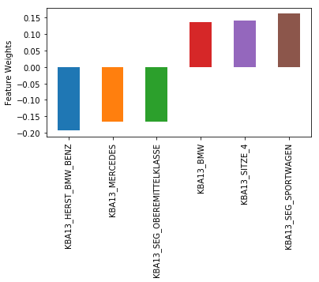

```python
# Map weights for the third principal component to corresponding feature names
# and then print the linked values, sorted by weight.
pca_results(azdias_final, pca, component_number = 3)
```

|  | Explained Variance | LNR | AKT_DAT_KL | ANZ_HAUSHALTE_AKTIV | ANZ_HH_TITEL | ANZ_KINDER | ANZ_PERSONEN | ANZ_STATISTISCHE_HAUSHALTE | ANZ_TITEL | ARBEIT | ... | SHOPPER_TYP_2.0 | SHOPPER_TYP_3.0 | TITEL_KZ_0.0 | TITEL_KZ_1.0 | TITEL_KZ_2.0 | TITEL_KZ_3.0 | TITEL_KZ_4.0 | TITEL_KZ_5.0 | VERS_TYP_1.0 | VERS_TYP_2.0 |
| --- | --- | --- | --- | --- | --- | --- | --- | --- | --- | --- | --- | --- | --- | --- | --- | --- | --- | --- | --- | --- | --- |
| Dimension 1 | 0.0724 | 0.0062 | 0.0074 | 0.0224 | 0.0109 | -0.0084 | -0.0099 | 0.0278 | 0.0021 | -0.0067 | ... | -0.0067 | 0.0061 | -0.0023 | 0.0019 | 0.0010 | 0.0010 | 0.0014 | 0.0003 | -0.0075 | 0.0068 |
| Dimension 2 | 0.0679 | -0.0239 | 0.0647 | 0.0860 | 0.0218 | -0.0213 | -0.0685 | 0.0837 | -0.0020 | 0.0998 | ... | 0.0234 | -0.0197 | 0.0000 | 0.0003 | -0.0001 | -0.0006 | 0.0001 | -0.0010 | -0.0220 | 0.0125 |
| Dimension 3 | 0.0457 | -0.0932 | -0.0068 | -0.0062 | -0.0218 | -0.0037 | 0.0012 | -0.0038 | -0.0115 | 0.0565 | ... | 0.0059 | -0.0079 | 0.0099 | -0.0095 | -0.0000 | -0.0021 | -0.0011 | -0.0015 | 0.0165 | -0.0106 |
| Dimension 4 | 0.0400 | 0.0181 | 0.0455 | -0.0187 | -0.0182 | 0.0730 | 0.0464 | -0.0210 | -0.0095 | -0.0382 | ... | 0.0235 | -0.0652 | 0.0111 | -0.0102 | -0.0003 | -0.0023 | -0.0026 | -0.0030 | 0.0135 | -0.0159 |
| Dimension 5 | 0.0271 | -0.0650 | -0.1159 | 0.0110 | 0.0126 | 0.0641 | 0.1509 | 0.0108 | 0.0138 | 0.0792 | ... | -0.0051 | 0.0364 | -0.0079 | 0.0070 | -0.0000 | 0.0013 | 0.0022 | 0.0033 | 0.0053 | 0.0106 |
| Dimension 6 | 0.0221 | -0.1177 | 0.0490 | 0.0134 | 0.0120 | -0.0187 | -0.0575 | 0.0159 | 0.0008 | 0.0611 | ... | -0.0133 | 0.0022 | -0.0016 | 0.0013 | -0.0002 | 0.0004 | 0.0010 | 0.0007 | 0.0150 | -0.0135 |
| Dimension 7 | 0.0198 | -0.0084 | -0.0032 | -0.0052 | 0.0009 | -0.0294 | -0.0024 | -0.0062 | 0.0087 | -0.0035 | ... | -0.0972 | -0.0709 | -0.0124 | 0.0118 | 0.0005 | 0.0035 | 0.0032 | 0.0004 | -0.0067 | 0.0170 |
| Dimension 8 | 0.0167 | -0.0270 | -0.0185 | 0.0207 | 0.0153 | 0.0099 | 0.0180 | 0.0185 | 0.0065 | -0.0891 | ... | 0.0117 | 0.0001 | -0.0067 | 0.0069 | -0.0010 | -0.0003 | 0.0003 | 0.0009 | 0.0154 | -0.0182 |
| Dimension 9 | 0.0150 | 0.0711 | -0.0088 | 0.0475 | 0.0008 | 0.0094 | 0.0208 | 0.0459 | -0.0103 | -0.0080 | ... | 0.0016 | -0.0127 | 0.0099 | -0.0095 | 0.0002 | -0.0012 | -0.0011 | -0.0023 | -0.0160 | 0.0086 |
| Dimension 10 | 0.0135 | -0.0243 | 0.0129 | -0.0303 | 0.0169 | -0.0116 | -0.0324 | -0.0299 | 0.0140 | 0.0127 | ... | -0.0123 | 0.0179 | -0.0130 | 0.0122 | -0.0003 | 0.0024 | 0.0027 | 0.0026 | 0.0091 | -0.0013 |
| Dimension 11 | 0.0122 | -0.0656 | 0.0042 | 0.0304 | 0.0282 | 0.0073 | 0.0080 | 0.0315 | 0.0190 | 0.0289 | ... | -0.0140 | 0.0168 | -0.0182 | 0.0170 | 0.0008 | 0.0041 | 0.0033 | 0.0038 | 0.0056 | -0.0101 |
| Dimension 12 | 0.0110 | 0.0268 | -0.0182 | 0.1437 | 0.0542 | 0.0009 | 0.0227 | 0.1449 | -0.0021 | -0.0455 | ... | -0.0148 | 0.0037 | 0.0018 | -0.0018 | -0.0010 | 0.0007 | 0.0002 | -0.0013 | 0.0028 | -0.0175 |
| Dimension 13 | 0.0106 | -0.0010 | -0.0066 | 0.0253 | 0.0234 | -0.0061 | -0.0121 | 0.0240 | 0.0087 | -0.0158 | ... | 0.0254 | -0.0234 | -0.0105 | 0.0101 | 0.0019 | 0.0016 | 0.0009 | 0.0019 | -0.0142 | 0.0193 |
| Dimension 14 | 0.0096 | -0.0942 | 0.0019 | 0.1043 | 0.0789 | -0.0026 | -0.0327 | 0.1049 | 0.0593 | -0.0595 | ... | 0.0197 | -0.0204 | -0.0625 | 0.0600 | 0.0015 | 0.0069 | 0.0092 | 0.0132 | -0.0214 | 0.0464 |
| Dimension 15 | 0.0088 | 0.0477 | 0.0038 | 0.1010 | 0.0887 | -0.0155 | 0.0013 | 0.1029 | 0.0572 | -0.1221 | ... | -0.0844 | 0.0733 | -0.0607 | 0.0580 | 0.0037 | 0.0079 | 0.0110 | 0.0112 | 0.0765 | -0.1052 |
| Dimension 16 | 0.0082 | -0.0150 | 0.0326 | 0.0353 | 0.0857 | -0.0081 | 0.0727 | 0.0355 | 0.1943 | -0.0183 | ... | -0.0600 | 0.0334 | -0.2073 | 0.1967 | 0.0083 | 0.0275 | 0.0359 | 0.0461 | 0.0899 | -0.1561 |
| Dimension 17 | 0.0081 | 0.0212 | -0.0349 | 0.0958 | 0.0406 | 0.0153 | -0.0978 | 0.0960 | -0.0433 | -0.0649 | ... | 0.0477 | 0.0058 | 0.0427 | -0.0401 | -0.0029 | -0.0073 | -0.0076 | -0.0100 | -0.0728 | 0.1610 |
| Dimension 18 | 0.0080 | 0.0365 | 0.0127 | -0.0621 | -0.0009 | -0.0050 | 0.0284 | -0.0633 | 0.0693 | -0.0248 | ... | -0.0028 | -0.0004 | -0.0740 | 0.0707 | 0.0016 | 0.0107 | 0.0113 | 0.0155 | 0.0358 | -0.0536 |
| Dimension 19 | 0.0077 | -0.0046 | 0.0064 | 0.0438 | 0.1567 | 0.0154 | 0.0148 | 0.0454 | 0.4011 | 0.0413 | ... | 0.0470 | -0.0282 | -0.4380 | 0.4172 | 0.0201 | 0.0543 | 0.0739 | 0.0949 | -0.0466 | 0.0703 |
| Dimension 20 | 0.0075 | 0.0428 | 0.0083 | -0.0541 | 0.0150 | -0.0490 | -0.0115 | -0.0550 | 0.1400 | 0.0219 | ... | 0.0770 | -0.0951 | -0.1533 | 0.1468 | 0.0070 | 0.0180 | 0.0217 | 0.0337 | -0.2279 | 0.2467 |
| Dimension 21 | 0.0072 | -0.0094 | -0.0182 | -0.0652 | -0.0083 | -0.0318 | -0.0459 | -0.0643 | 0.0809 | 0.0141 | ... | -0.0046 | 0.0504 | -0.0893 | 0.0841 | 0.0044 | 0.0105 | 0.0161 | 0.0230 | 0.0788 | -0.0341 |
| Dimension 22 | 0.0071 | -0.0512 | 0.0579 | 0.1149 | 0.0137 | 0.0059 | 0.1435 | 0.1130 | -0.0839 | 0.0509 | ... | 0.0457 | -0.0893 | 0.0990 | -0.0942 | -0.0023 | -0.0139 | -0.0144 | -0.0229 | -0.1619 | 0.1021 |
| Dimension 23 | 0.0070 | 0.0598 | -0.0123 | -0.0187 | -0.0010 | 0.0985 | 0.0118 | -0.0188 | 0.0680 | -0.0040 | ... | 0.0062 | -0.0791 | -0.0782 | 0.0751 | 0.0031 | 0.0090 | 0.0110 | 0.0164 | -0.1058 | 0.0256 |
| Dimension 24 | 0.0066 | -0.0481 | -0.0743 | -0.0008 | 0.0150 | -0.0232 | -0.1397 | -0.0021 | 0.0691 | 0.1228 | ... | -0.0401 | 0.0245 | -0.0860 | 0.0816 | 0.0058 | 0.0125 | 0.0141 | 0.0190 | 0.1216 | -0.1453 |
| Dimension 25 | 0.0064 | -0.0309 | -0.0153 | -0.0532 | -0.0137 | 0.0018 | -0.0422 | -0.0559 | 0.0224 | 0.0395 | ... | -0.0300 | -0.0684 | -0.0271 | 0.0258 | -0.0010 | 0.0041 | 0.0051 | 0.0055 | -0.1917 | 0.1179 |
| Dimension 26 | 0.0061 | 0.0008 | -0.0068 | 0.0560 | 0.0425 | 0.0009 | -0.0054 | 0.0547 | 0.0872 | -0.1130 | ... | -0.0370 | 0.0352 | -0.0986 | 0.0924 | 0.0047 | 0.0142 | 0.0189 | 0.0250 | -0.1065 | 0.1040 |
| Dimension 27 | 0.0060 | 0.0233 | -0.0197 | 0.0303 | 0.0118 | -0.0434 | -0.0506 | 0.0296 | 0.0543 | -0.0108 | ... | 0.0978 | -0.0095 | -0.0673 | 0.0628 | 0.0021 | 0.0124 | 0.0138 | 0.0158 | 0.2736 | -0.1989 |
| Dimension 28 | 0.0059 | 0.0038 | 0.0839 | -0.0560 | -0.0315 | -0.2192 | -0.0544 | -0.0551 | 0.0043 | 0.0242 | ... | -0.0150 | -0.0200 | -0.0040 | 0.0038 | 0.0006 | 0.0012 | -0.0007 | 0.0014 | -0.1350 | 0.1527 |
| Dimension 29 | 0.0057 | 0.0001 | -0.0022 | 0.1623 | 0.0862 | -0.0546 | -0.0488 | 0.1636 | -0.0422 | 0.0207 | ... | 0.0395 | 0.0039 | 0.0493 | -0.0471 | -0.0009 | -0.0074 | -0.0073 | -0.0102 | 0.0510 | -0.0370 |
| Dimension 30 | 0.0055 | 0.0165 | -0.0397 | -0.0638 | -0.0394 | -0.0574 | -0.0978 | -0.0657 | 0.0041 | -0.0502 | ... | 0.0398 | -0.1099 | -0.0128 | 0.0122 | 0.0001 | 0.0040 | 0.0039 | -0.0003 | -0.0001 | -0.0419 |
| ... | ... | ... | ... | ... | ... | ... | ... | ... | ... | ... | ... | ... | ... | ... | ... | ... | ... | ... | ... | ... | ... |
| Dimension 171 | 0.0015 | 0.0322 | -0.0431 | 0.0030 | -0.0133 | 0.0023 | 0.0115 | 0.0028 | 0.0179 | 0.0038 | ... | 0.0111 | -0.0090 | 0.0101 | -0.0085 | -0.0025 | -0.0049 | -0.0060 | -0.0013 | 0.0046 | -0.0002 |
| Dimension 172 | 0.0015 | -0.0601 | -0.0614 | -0.0485 | 0.0964 | 0.0390 | -0.0170 | -0.0482 | 0.0122 | -0.0025 | ... | 0.0234 | -0.0186 | 0.0113 | -0.0108 | -0.0005 | 0.0029 | -0.0033 | -0.0042 | -0.0005 | -0.0041 |
| Dimension 173 | 0.0015 | -0.0404 | 0.1499 | -0.0573 | 0.0768 | -0.0249 | 0.0044 | -0.0563 | 0.0009 | 0.0461 | ... | -0.0377 | 0.0296 | 0.0057 | -0.0046 | -0.0015 | -0.0042 | -0.0054 | 0.0011 | -0.0281 | 0.0250 |
| Dimension 174 | 0.0015 | 0.0792 | 0.0464 | -0.0256 | 0.0341 | 0.0040 | -0.0007 | -0.0238 | 0.0189 | 0.0250 | ... | -0.0133 | -0.0044 | 0.0109 | -0.0105 | -0.0017 | -0.0025 | 0.0014 | -0.0030 | 0.0014 | 0.0003 |
| Dimension 175 | 0.0015 | -0.0114 | -0.0829 | -0.0197 | 0.0019 | -0.0060 | 0.0032 | -0.0195 | 0.0078 | -0.0117 | ... | 0.0070 | -0.0019 | -0.0005 | -0.0001 | -0.0001 | 0.0019 | 0.0018 | 0.0001 | 0.0217 | -0.0225 |
| Dimension 176 | 0.0015 | -0.1147 | -0.1896 | 0.0314 | -0.0238 | 0.0377 | 0.0373 | 0.0270 | -0.0193 | 0.0016 | ... | 0.0193 | -0.0069 | -0.0192 | 0.0184 | 0.0008 | 0.0017 | 0.0036 | 0.0041 | 0.0078 | 0.0072 |
| Dimension 177 | 0.0015 | -0.1145 | -0.0170 | 0.0039 | -0.0138 | -0.0242 | 0.0451 | 0.0018 | 0.0220 | 0.0602 | ... | -0.0082 | 0.0145 | 0.0100 | -0.0094 | -0.0009 | 0.0015 | -0.0001 | -0.0057 | 0.0140 | 0.0070 |
| Dimension 178 | 0.0015 | -0.2404 | -0.0411 | -0.0291 | 0.0602 | -0.0392 | 0.0009 | -0.0282 | 0.0050 | 0.0750 | ... | -0.0142 | 0.0045 | 0.0054 | -0.0050 | -0.0012 | 0.0019 | -0.0029 | -0.0020 | -0.0115 | 0.0096 |
| Dimension 179 | 0.0015 | 0.1285 | 0.0751 | -0.0001 | -0.0110 | -0.0256 | -0.0198 | -0.0000 | 0.0174 | -0.0143 | ... | 0.0122 | -0.0307 | 0.0098 | -0.0099 | 0.0034 | 0.0014 | -0.0015 | -0.0024 | 0.0067 | -0.0156 |
| Dimension 180 | 0.0014 | 0.0713 | 0.0058 | -0.0123 | 0.0254 | -0.0419 | -0.0143 | -0.0123 | -0.0160 | -0.0164 | ... | 0.0195 | -0.0312 | -0.0127 | 0.0113 | 0.0006 | 0.0039 | 0.0036 | 0.0036 | 0.0042 | -0.0053 |
| Dimension 181 | 0.0014 | -0.0446 | -0.1597 | -0.0157 | 0.0268 | 0.0540 | 0.0387 | -0.0191 | 0.0032 | 0.0150 | ... | -0.0013 | -0.0103 | 0.0048 | -0.0048 | -0.0019 | 0.0036 | -0.0004 | -0.0028 | -0.0172 | 0.0296 |
| Dimension 182 | 0.0014 | 0.0518 | 0.1424 | 0.0282 | -0.0293 | 0.0717 | -0.0103 | 0.0294 | -0.0308 | -0.0118 | ... | 0.0367 | -0.0136 | -0.0102 | 0.0101 | 0.0001 | 0.0021 | 0.0006 | 0.0007 | 0.0162 | -0.0135 |
| Dimension 183 | 0.0014 | -0.0287 | -0.0267 | -0.0611 | 0.0654 | -0.1112 | 0.0529 | -0.0614 | 0.0039 | 0.0182 | ... | -0.0112 | -0.0351 | -0.0060 | 0.0047 | 0.0002 | 0.0014 | 0.0019 | 0.0048 | -0.0193 | 0.0023 |
| Dimension 184 | 0.0014 | 0.0062 | -0.2397 | -0.0340 | 0.0585 | 0.0250 | 0.0485 | -0.0344 | -0.0292 | -0.0109 | ... | 0.0020 | -0.0251 | -0.0124 | 0.0111 | 0.0037 | 0.0031 | 0.0029 | 0.0033 | -0.0278 | 0.0154 |
| Dimension 185 | 0.0014 | -0.0621 | 0.2602 | -0.0135 | 0.0203 | -0.0305 | -0.0160 | -0.0094 | -0.0234 | -0.0001 | ... | -0.0116 | -0.0067 | 0.0003 | -0.0008 | -0.0003 | 0.0017 | -0.0003 | 0.0010 | -0.0086 | -0.0142 |
| Dimension 186 | 0.0014 | -0.1188 | -0.1833 | -0.0113 | 0.0350 | 0.0216 | 0.0844 | -0.0140 | -0.0058 | 0.0077 | ... | 0.0253 | -0.0333 | 0.0014 | -0.0002 | -0.0017 | -0.0001 | -0.0064 | -0.0002 | -0.0016 | 0.0099 |
| Dimension 187 | 0.0013 | -0.0211 | -0.0177 | 0.0288 | -0.0375 | 0.1372 | 0.0520 | 0.0250 | 0.0243 | -0.0091 | ... | 0.0598 | -0.0323 | 0.0074 | -0.0073 | 0.0006 | 0.0026 | 0.0006 | -0.0044 | 0.0240 | -0.0083 |
| Dimension 188 | 0.0013 | -0.1428 | 0.0741 | 0.0297 | -0.0288 | 0.0445 | -0.0034 | 0.0300 | -0.0012 | -0.0072 | ... | 0.0084 | 0.0048 | -0.0036 | 0.0036 | -0.0038 | 0.0021 | -0.0006 | 0.0006 | 0.0054 | 0.0175 |
| Dimension 189 | 0.0013 | -0.1909 | 0.0723 | -0.0175 | 0.0262 | -0.0185 | -0.0191 | -0.0160 | -0.0120 | 0.0676 | ... | -0.0165 | 0.0112 | -0.0035 | 0.0025 | 0.0002 | 0.0015 | -0.0005 | 0.0045 | -0.0103 | 0.0071 |
| Dimension 190 | 0.0013 | 0.1330 | 0.0078 | -0.0121 | 0.0299 | 0.0043 | 0.0040 | -0.0135 | 0.0141 | -0.0502 | ... | 0.0142 | 0.0063 | 0.0121 | -0.0120 | -0.0011 | 0.0017 | -0.0022 | -0.0028 | 0.0011 | 0.0096 |
| Dimension 191 | 0.0013 | 0.1599 | -0.1876 | 0.0213 | -0.0184 | -0.0557 | 0.1296 | 0.0198 | 0.0404 | -0.0228 | ... | -0.0121 | 0.0367 | 0.0072 | -0.0069 | 0.0002 | 0.0002 | -0.0013 | -0.0020 | 0.0050 | 0.0116 |
| Dimension 192 | 0.0012 | -0.1433 | 0.0126 | 0.0020 | -0.0259 | -0.0010 | -0.0035 | 0.0005 | 0.0435 | 0.0204 | ... | 0.0025 | 0.0123 | 0.0171 | -0.0165 | -0.0013 | -0.0005 | -0.0014 | -0.0048 | -0.0027 | 0.0044 |
| Dimension 193 | 0.0012 | -0.0819 | -0.0624 | -0.0101 | 0.0199 | 0.0765 | 0.0387 | -0.0091 | -0.0248 | -0.0232 | ... | -0.0149 | 0.0301 | -0.0059 | 0.0055 | 0.0004 | 0.0008 | 0.0013 | 0.0012 | -0.0077 | 0.0222 |
| Dimension 194 | 0.0012 | -0.0084 | -0.1333 | 0.0120 | -0.0029 | -0.0361 | 0.1172 | 0.0124 | -0.0001 | 0.0088 | ... | -0.0352 | 0.0514 | -0.0037 | 0.0040 | -0.0005 | -0.0009 | 0.0029 | -0.0018 | 0.0020 | 0.0127 |
| Dimension 195 | 0.0012 | -0.0917 | -0.0249 | -0.0407 | 0.0345 | 0.0402 | 0.0148 | -0.0405 | -0.0312 | -0.0403 | ... | 0.0244 | 0.0031 | -0.0078 | 0.0074 | 0.0004 | 0.0003 | 0.0004 | 0.0028 | -0.0038 | -0.0023 |
| Dimension 196 | 0.0012 | 0.0458 | -0.0281 | 0.0069 | -0.0076 | 0.0015 | 0.0250 | 0.0028 | 0.0302 | 0.0173 | ... | -0.0041 | 0.0350 | 0.0103 | -0.0101 | -0.0018 | -0.0008 | 0.0009 | -0.0029 | -0.0013 | -0.0105 |
| Dimension 197 | 0.0011 | -0.1034 | 0.0472 | -0.0084 | -0.0120 | 0.2783 | -0.0619 | -0.0064 | 0.0008 | -0.0060 | ... | 0.0256 | -0.0260 | -0.0011 | 0.0017 | -0.0006 | -0.0009 | 0.0012 | -0.0022 | 0.0082 | 0.0003 |
| Dimension 198 | 0.0011 | 0.0545 | 0.0913 | -0.0014 | 0.0157 | 0.2236 | -0.1111 | -0.0015 | -0.0097 | -0.0191 | ... | -0.0361 | 0.0505 | -0.0021 | 0.0022 | -0.0015 | 0.0005 | -0.0009 | 0.0008 | -0.0127 | 0.0386 |
| Dimension 199 | 0.0011 | -0.0560 | 0.0345 | 0.0184 | 0.0006 | -0.0222 | 0.0021 | 0.0147 | 0.0028 | -0.0017 | ... | 0.0017 | 0.0014 | 0.0001 | 0.0002 | -0.0008 | 0.0003 | -0.0010 | -0.0006 | -0.0133 | -0.0027 |
| Dimension 200 | 0.0011 | 0.0003 | 0.0027 | -0.0016 | 0.0270 | 0.3956 | -0.1129 | -0.0011 | -0.0238 | 0.0178 | ... | 0.0236 | -0.0089 | -0.0118 | 0.0110 | 0.0037 | 0.0023 | 0.0027 | 0.0021 | 0.0245 | -0.0341 |

200 rows × 370 columns

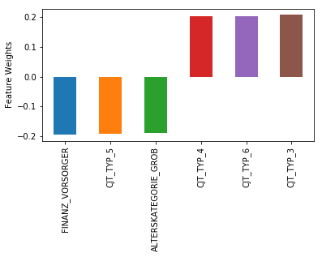

```python
# Map weights for the fourth principal component to corresponding feature names
# and then print the linked values, sorted by weight.
pca_results(azdias_final, pca, component_number = 4)
```

For each principal component or dimension, the top 3 and bottom 3 weights with their corresponding feature names will be investigated for any associations.

Dimension 1:

| Feature/value | Description | Meaning |
| --- | --- | --- |
| KBA05_HERSTTEMP_3.0/negative | development of the most common car manufacturers in the neighbourhood | stayed lower/average level |
| FINANZ_ANLEGER/negative | financial typology: investor | investor |
| FINANZ_SPARER/negative | financial typology: money saver | money saver |
| CJT_TYP_1/positive | no column description |  |
| KBA05_MAXHERST_3.0/positive | most common car manufacturer in the microcell | Ford/Opel |
| KBA05_MODTEMP_3.0/positive | development of the most common car segment in the neighbourhood | stayed lower/average level |

**Interpretation:** The first principal component is mainly related to low/average car and money saver and investor for financial typology.

Dimension 2:

| Feature/value | Description | Meaning |
| --- | --- | --- |
| PLZ8_ANTG1/negative | number of 1-2 family houses in the PLZ8 | low share |
| KBA13_ANTG1/negative | no column description |  |
| MOBI_REGIO/negative | moving patterns | very high movement |
| KBA13_AUTOQUOTE/positive | share of cars per household within the PLZ8 | more cars per household |
| MOBI_RASTER/positive | no column description |  |
| KBA05_GBZ/positive | number of buildings in the microcell | 1-2 buildings |

**Interpretation:** The second principal component is about people who aren't sharing their houses and having 1-2 houses in the same building. also, it's related to movement and cars, speacially high movement and more cars.

Dimension 3:

| Feature/value | Description | Meaning |
| --- | --- | --- |
| KBA13_HERST_BMW_BENZ/negative | share of BMW & Mercedes Benz within the PLZ8 | low |
| KBA13_MERCEDES/negative | share of MERCEDES within the PLZ8 | low |
| KBA13_SEG_OBEREMITTELKLASSE/negative | share of upper middle class cars and upper class cars (BMW5er, BMW7er etc.) | low |
| KBA13_BMW/positive | share of BMW within the PLZ8 | very low |
| KBA13_SITZE_4/positive | number of cars with less than 5 seats in the PLZ8 | very low |
| KBA13_SEG_SPORTWAGEN/positive | share of sportscars within the PLZ8 | very low |

**Interpretation:** The third principal component s primarily affected by car ownership. People who own a lot of luxury cars such as BWM and sportscars increase this component. On the other hand, people who own Mercedes cars decrease this component.

Dimension 4:

| Feature/value | Description | Meaning |
| --- | --- | --- |
| FINANZ_VORSORGER/negative | financial typology: be prepared | high |
| CJT_TYP_5/negative | no column description |  |
| ALTERSKATEGORIE_GROB/negative | age classification through prename analysis | 30 - 45 years |
| CJT_TYP_4/positive | no column description |  |
| CJT_TYP_6/positive | no column description |  |
| CJT_TYP_3/positive | no column description |  |

**Interpretation:** The fourth principal component affected by people from age 30-45 years and has high financial typology. There is also CJT_TYP features which has high affectings in this component but we don't know what does it mean.

## Step 3: Clustering

### Step 3.1: Apply Clustering to General Population

Information from Term 1: You've assessed and cleaned the demographics data, then scaled and transformed them. Now, it's time to see how the data clusters in the principal components space. In this substep, you will apply k-means clustering to the dataset and use the average within-cluster distances from each point to their assigned cluster's centroid to decide on a number of clusters to keep.

- Use sklearn's KMeans class to perform k-means clustering on the PCA-transformed data.
- Then, compute the average difference from each point to its assigned cluster's center. **Hint**: The KMeans object's `.score()` method might be useful here, but note that in sklearn, scores tend to be defined so that larger is better. Try applying it to a small, toy dataset, or use an internet search to help your understanding.
- Perform the above two steps for a number of different cluster counts. You can then see how the average distance decreases with an increasing number of clusters. However, each additional cluster provides a smaller net benefit. Use this fact to select a final number of clusters in which to group the data. **Warning**: because of the large size of the dataset, it can take a long time for the algorithm to resolve. The more clusters to fit, the longer the algorithm will take. You should test for cluster counts through at least 10 clusters to get the full picture, but you shouldn't need to test for a number of clusters above about 30.
- Once you've selected a final number of clusters to use, re-fit a KMeans instance to perform the clustering operation. Make sure that you also obtain the cluster assignments for the general demographics data, since you'll be using them in the final Step 3.3.

```python
# Over a number of different cluster counts...
# run k-means clustering on the data and...
# compute the average within-cluster distances.
def k_mean_score(data, n_cluster):
    kmeans = KMeans(n_clusters = n_cluster)
    model = kmeans.fit(data)
    score = np.abs(model.score(data))
    return score

scores = []
ks = list(range(1,17))
for k in ks:
    scores.append(k_mean_score(X_pca, k))
```

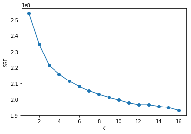

```python
# Investigate the change in within-cluster distance across number of clusters.(elbow method)
# K indicate number of clusters
# SSE indicate Sum of Squared Error
plt.plot(ks, scores, linestyle='-', marker='o')
plt.xlabel('K')
plt.ylabel('SSE')
plt.savefig('k_mean_score.png')
```

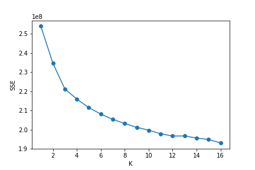

```python
# Have saved version of k_mean_score plot since it takes hours to generate
from IPython.display import Image
Image(filename='k_mean_score.png')
```

```python
# Re-fit the k-means model with the selected number of clusters and obtain
# cluster predictions for the general population demographics data.

kmeans = KMeans(n_clusters = 11)
model_11 = kmeans.fit(X_pca)
azdias_pred = model_11.predict(X_pca)
```

```python
# View first few labels predicted for the azdias dataset
azdias_pred[0:10]
```

```
array([ 0,  0,  5,  8,  5,  0,  0, 10, 10,  4], dtype=int32)
```

I decided to choose 11 because after 11 clusters, the average distance start to decrease slowely with small values.

### Step 3.2: Apply All Steps to the Customer Data

Information from Term 1: Now that you have clusters and cluster centers for the general population, it's time to see how the customer data maps on to those clusters. Take care to not confuse this for re-fitting all of the models to the customer data. Instead, you're going to use the fits from the general population to clean, transform, and cluster the customer data. In the last step of the project, you will interpret how the general population fits apply to the customer data.

```python
# PCA transformation
customers_pca = pca.transform(customers_final)
```

```python
# Predict using Kmeans model_11
customers_pred = model_11.predict(customers_pca)
```

```python
customers_pred[0:10]
```

```
array([ 3,  4,  5,  8,  3,  3,  3, 10,  3,  3], dtype=int32)
```

### Step 3.3: Compare Customer Data to Demographics Data

At this point, you have clustered data based on demographics of the general population of Germany, and seen how the customer data for a mail-order sales company maps onto those demographic clusters. In this final substep, you will compare the two cluster distributions to see where the strongest customer base for the company is.

Consider the proportion of persons in each cluster for the general population, and the proportions for the customers. If we think the company's customer base to be universal, then the cluster assignment proportions should be fairly similar between the two. If there are only particular segments of the population that are interested in the company's products, then we should see a mismatch from one to the other. If there is a higher proportion of persons in a cluster for the customer data compared to the general population (e.g. 5% of persons are assigned to a cluster for the general population, but 15% of the customer data is closest to that cluster's centroid) then that suggests the people in that cluster to be a target audience for the company. On the other hand, the proportion of the data in a cluster being larger in the general population than the customer data (e.g. only 2% of customers closest to a population centroid that captures 6% of the data) suggests that group of persons to be outside of the target demographics.

```
Text(0.5,1,'General Clusters')
```

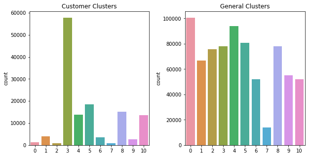

```python
# Compare the proportion of data in each cluster for the customer data to the
# proportion of data in each cluster for the general population.
figure, axs = plt.subplots(nrows=1, ncols=2, figsize = (10,5))
figure.subplots_adjust(hspace = 1, wspace=.3)

sns.countplot(customers_pred, ax=axs[0])
axs[0].set_title('Customer Clusters')
sns.countplot(azdias_pred, ax=axs[1])
axs[1].set_title('General Clusters')
```

```python
# What kinds of people are part of a cluster that is underrepresented in the
# customer data compared to the general population?
centroid_2 = model_11.cluster_centers_[2]
components_2 = list(range(1, 201))
cluster_components_2 = pd.DataFrame({'Centroid': centroid_2, 'Component': components_2})
cluster_components_2.sort_values('Centroid',ascending=False)
```

|  | Centroid | Component |
| --- | --- | --- |
| 1 | 4.781388 | 2 |
| 3 | 3.130596 | 4 |
| 8 | 0.860404 | 9 |
| 10 | 0.522284 | 11 |
| 11 | 0.348324 | 12 |
| 2 | 0.344493 | 3 |
| 22 | 0.228091 | 23 |
| 23 | 0.218937 | 24 |
| 64 | 0.201466 | 65 |
| 40 | 0.164434 | 41 |
| 52 | 0.149773 | 53 |
| 33 | 0.147337 | 34 |
| 17 | 0.118541 | 18 |
| 49 | 0.116175 | 50 |
| 83 | 0.113777 | 84 |
| 139 | 0.105958 | 140 |
| 45 | 0.091357 | 46 |
| 39 | 0.085992 | 40 |
| 20 | 0.081788 | 21 |
| 15 | 0.078279 | 16 |
| 44 | 0.072851 | 45 |
| 145 | 0.072240 | 146 |
| 32 | 0.069710 | 33 |
| 56 | 0.067573 | 57 |
| 26 | 0.063778 | 27 |
| 36 | 0.063144 | 37 |
| 111 | 0.060519 | 112 |
| 119 | 0.056664 | 120 |
| 25 | 0.055382 | 26 |
| 107 | 0.051447 | 108 |
| ... | ... | ... |
| 98 | -0.058287 | 99 |
| 29 | -0.058896 | 30 |
| 69 | -0.060348 | 70 |
| 141 | -0.060594 | 142 |
| 73 | -0.062254 | 74 |
| 114 | -0.064725 | 115 |
| 66 | -0.066699 | 67 |
| 19 | -0.066844 | 20 |
| 57 | -0.071449 | 58 |
| 68 | -0.075304 | 69 |
| 180 | -0.075865 | 181 |
| 54 | -0.077581 | 55 |
| 60 | -0.077861 | 61 |
| 95 | -0.081911 | 96 |
| 142 | -0.089758 | 143 |
| 61 | -0.109371 | 62 |
| 65 | -0.125348 | 66 |
| 55 | -0.134325 | 56 |
| 63 | -0.139450 | 64 |
| 31 | -0.145602 | 32 |
| 12 | -0.153300 | 13 |
| 38 | -0.225608 | 39 |
| 16 | -0.231756 | 17 |
| 6 | -0.335535 | 7 |
| 4 | -0.409194 | 5 |
| 9 | -0.477131 | 10 |
| 13 | -0.651651 | 14 |
| 7 | -1.266162 | 8 |
| 5 | -1.407519 | 6 |
| 0 | -1.887244 | 1 |

200 rows × 2 columns

```python
# What kinds of people are part of a cluster that is overrepresented in the
# customer data compared to the general population?
centroid_3 = model_11.cluster_centers_[3]
components_3 = list(range(1, 201))
cluster_components_3 = pd.DataFrame({'Centroid': centroid_3, 'Component': components_3})
cluster_components_3.sort_values('Centroid',ascending=False)
```

|  | Centroid | Component |
| --- | --- | --- |
| 4 | 1.432512 | 5 |
| 0 | 0.670311 | 1 |
| 33 | 0.567105 | 34 |
| 52 | 0.345909 | 53 |
| 15 | 0.262333 | 16 |
| 17 | 0.232450 | 18 |
| 55 | 0.179028 | 56 |
| 40 | 0.171729 | 41 |
| 34 | 0.167476 | 35 |
| 6 | 0.154096 | 7 |
| 41 | 0.135353 | 42 |
| 59 | 0.126931 | 60 |
| 43 | 0.117948 | 44 |
| 107 | 0.115903 | 108 |
| 8 | 0.114400 | 9 |
| 79 | 0.112607 | 80 |
| 104 | 0.108050 | 105 |
| 28 | 0.091177 | 29 |
| 20 | 0.091058 | 21 |
| 25 | 0.090890 | 26 |
| 21 | 0.089995 | 22 |
| 36 | 0.082673 | 37 |
| 139 | 0.081820 | 140 |
| 50 | 0.081802 | 51 |
| 54 | 0.077849 | 55 |
| 72 | 0.074776 | 73 |
| 42 | 0.072340 | 43 |
| 31 | 0.072101 | 32 |
| 108 | 0.070638 | 109 |
| 169 | 0.069822 | 170 |
| ... | ... | ... |
| 82 | -0.068820 | 83 |
| 164 | -0.080710 | 165 |
| 77 | -0.082319 | 78 |
| 44 | -0.083188 | 45 |
| 49 | -0.086603 | 50 |
| 66 | -0.092768 | 67 |
| 27 | -0.093535 | 28 |
| 51 | -0.094517 | 52 |
| 95 | -0.097584 | 96 |
| 65 | -0.099632 | 66 |
| 56 | -0.112977 | 57 |
| 75 | -0.114553 | 76 |
| 38 | -0.127719 | 39 |
| 62 | -0.140695 | 63 |
| 48 | -0.170763 | 49 |
| 37 | -0.182264 | 38 |
| 30 | -0.184158 | 31 |
| 13 | -0.202685 | 14 |
| 35 | -0.227738 | 36 |
| 24 | -0.253974 | 25 |
| 16 | -0.285171 | 17 |
| 22 | -0.300254 | 23 |
| 14 | -0.323913 | 15 |
| 10 | -0.352343 | 11 |
| 12 | -0.545715 | 13 |
| 11 | -0.778184 | 12 |
| 7 | -1.225836 | 8 |
| 2 | -2.439770 | 3 |
| 3 | -3.065631 | 4 |
| 1 | -4.456273 | 2 |

200 rows × 2 columns

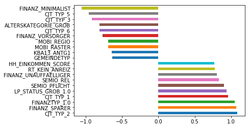

```python
def plot_scaled_comparison(df_sample, kmeans, cluster):
    X = pd.DataFrame.from_dict(dict(zip(df_sample.columns,
pca.inverse_transform(kmeans.cluster_centers_[cluster]))), orient='index').rename(
columns={0: 'feature_values'}).sort_values('feature_values', ascending=False)
    X['feature_values_abs'] = abs(X['feature_values'])
    pd.concat((X['feature_values'][:10], X['feature_values'][-10:]), axis=0).plot(kind='barh');

plot_scaled_comparison(customers_final, kmeans, 2)
```

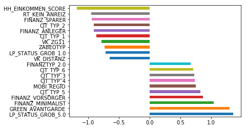

```python
plot_scaled_comparison(customers_final, kmeans, 3)
```

I find this analysis generally meaningless and uninterpretable. A more in depth analysis of the clusters would include looking at more than the highest positive and negatively weighted components but this was done for simplicity. I would be interested in running the analysis again without the religious or minded features, or somehow whittling the columns down to something more understandable.

## Part 2: Supervised Learning Model

Now that you've found which parts of the population are more likely to be customers of the mail-order company, it's time to build a prediction model. Each of the rows in the "MAILOUT" data files represents an individual that was targeted for a mailout campaign. Ideally, we should be able to use the demographic information from each individual to decide whether or not it will be worth it to include that person in the campaign.

The "MAILOUT" data has been split into two approximately equal parts, each with almost 43 000 data rows. In this part, you can verify your model with the "TRAIN" partition, which includes a column, "RESPONSE", that states whether or not a person became a customer of the company following the campaign. In the next part, you'll need to create predictions on the "TEST" partition, where the "RESPONSE" column has been withheld.

```python
mailout_train = pd.read_csv('../../data/Term2/capstone/arvato_data/Udacity_MAILOUT_052018_TRAIN.csv', sep=';')
```

```python
mailout_train.head()
```

|  | LNR | AGER_TYP | AKT_DAT_KL | ALTER_HH | ALTER_KIND1 | ALTER_KIND2 | ALTER_KIND3 | ALTER_KIND4 | ALTERSKATEGORIE_FEIN | ANZ_HAUSHALTE_AKTIV | ... | VK_DHT4A | VK_DISTANZ | VK_ZG11 | W_KEIT_KIND_HH | WOHNDAUER_2008 | WOHNLAGE | ZABEOTYP | RESPONSE | ANREDE_KZ | ALTERSKATEGORIE_GROB |
| --- | --- | --- | --- | --- | --- | --- | --- | --- | --- | --- | --- | --- | --- | --- | --- | --- | --- | --- | --- | --- | --- |
| 0 | 1763 | 2 | 1.0 | 8.0 | NaN | NaN | NaN | NaN | 8.0 | 15.0 | ... | 5.0 | 2.0 | 1.0 | 6.0 | 9.0 | 3.0 | 3 | 0 | 2 | 4 |
| 1 | 1771 | 1 | 4.0 | 13.0 | NaN | NaN | NaN | NaN | 13.0 | 1.0 | ... | 1.0 | 2.0 | 1.0 | 4.0 | 9.0 | 7.0 | 1 | 0 | 2 | 3 |
| 2 | 1776 | 1 | 1.0 | 9.0 | NaN | NaN | NaN | NaN | 7.0 | 0.0 | ... | 6.0 | 4.0 | 2.0 | NaN | 9.0 | 2.0 | 3 | 0 | 1 | 4 |
| 3 | 1460 | 2 | 1.0 | 6.0 | NaN | NaN | NaN | NaN | 6.0 | 4.0 | ... | 8.0 | 11.0 | 11.0 | 6.0 | 9.0 | 1.0 | 3 | 0 | 2 | 4 |
| 4 | 1783 | 2 | 1.0 | 9.0 | NaN | NaN | NaN | NaN | 9.0 | 53.0 | ... | 2.0 | 2.0 | 1.0 | 6.0 | 9.0 | 3.0 | 3 | 0 | 1 | 3 |

5 rows × 367 columns

```python
mailout_train.shape
```

```
(42962, 367)
```

```python
# Total number of records
n_records = mailout_train.shape[0]

# Number of records where the individual became a customer
n_customer = mailout_train[mailout_train['RESPONSE'] == 1].shape[0]

# Number of records where individual did not become a customer
n_not_customer = mailout_train[mailout_train['RESPONSE'] == 0].shape[0]

# Percentage of individuals who became customers
customer_perc = (n_customer / n_records) * 100

# Print the results
print("Total number of records: {}".format(n_records))
print("Individuals who became customers: {}".format(n_customer))
print("Individuals who did not become customers: {}".format(n_not_customer))
print("Percentage of individuals who became customers: {}%".format(customer_perc))
```

```
Total number of records: 42962
Individuals who became customers: 532
Individuals who did not become customers: 42430
Percentage of individuals who became customers: 1.2383036171500394%
```

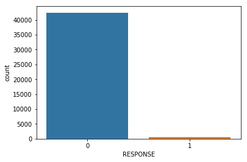

```python
sns.countplot("RESPONSE",data=mailout_train)
```

Out of all the 42,962 individuals in the mailout campaign, only 1.24% of the individuals became customers. The dataset is highly imbalanced because of the disproportionate amount of customers and non-customers.

```python
mailout_train_cleaned = clean_data(mailout_train, unknown)
```

```python
mailout_train_cleaned.shape
```

```
(33634, 371)
```

```python
# Determine the columns that are in the mailout train cleaned dataframe
# but not the cleaned cutomers dataframe (these 3 are expected)
mailout_train_cleaned.columns[~mailout_train_cleaned.columns.isin(customers_final.columns)]
```

```
Index(['CAMEO_DEUG_2015', 'CAMEO_INTL_2015', 'EINGEFUEGT_AM', 'RESPONSE'], dtype='object')
```

```python
# Determine the columns that are in the cutomers cleaned dataframe
# but not the mailout train cleaned dataframe (these 3 are expected)
customers_final.columns[~customers_final.columns.isin(mailout_train_cleaned.columns)]
```

```
Index(['GEBAEUDETYP_5.0', 'TITEL_KZ_2.0'], dtype='object')
```

```python
# As mentioned in above the columns CAMEO_DEUG_2015 and CAMEO_INTL_2015
# have string values of "X" and "XX". EINGEFUEGT_AM has a string issue.
# Remove these columns for simplicity.
del mailout_train_cleaned['CAMEO_DEUG_2015']
del mailout_train_cleaned['CAMEO_INTL_2015']
del mailout_train_cleaned['EINGEFUEGT_AM']
```

```python
# Find index of the GEBAEUDETYP_5.0 and TITEL_KZ_2.0 columns in the azdias dataframe
column_GEB_index = customers_final.columns.get_loc("GEBAEUDETYP_5.0")
column_TIT_index = customers_final.columns.get_loc("TITEL_KZ_2.0")
column_GEB_index, column_TIT_index
```

```
(310, 360)
```

```python
# Insert a column called GEBAEUDETYP_5.0 at index = 310
# Insert a column called TITEL_KZ_2.0 at index = 360
# with all values = 0
mailout_train_cleaned.insert(loc=column_GEB_index, column='GEBAEUDETYP_5.0', value=0)
mailout_train_cleaned.insert(loc=column_TIT_index, column='TITEL_KZ_2.0', value=0)
```

```python
customers_final.shape, mailout_train_cleaned.shape
```

```
((132100, 369), (33634, 370))
```

```python
# Split the data into features and target label
y = mailout_train_cleaned['RESPONSE']
X = mailout_train_cleaned.drop('RESPONSE', axis = 1)
```

```python
# impute median and scale azdias
imputer = Imputer(strategy='median')
scaler = StandardScaler()
```

```python
mailout_train_imputed = pd.DataFrame(imputer.fit_transform(X))
mailout_train_scaled = scaler.fit_transform(mailout_train_imputed)
```

```python
def classify(clf, param_grid, X_train=mailout_train_scaled, y_train=y):
    """
    Fits a classifier to its training data and prints its ROC AUC score.

    INPUT:
    - clf (classifier): classifier to fit
    - param_grid (dict): classifier parameters used with GridSearchCV
    - X_train (DataFrame): training input
    - y_train (DataFrame): training output

    OUTPUT:
    - classifier: input classifier fitted to the training data
    """

    # cv uses StratifiedKFold
    # scoring roc_auc available as parameter
    grid = GridSearchCV(estimator=clf, param_grid=param_grid, scoring='roc_auc', cv=5)
    grid.fit(X_train, y_train)
    print(grid.best_score_)

    return grid.best_estimator_
```

```python
# LogisticRegression
lor = LogisticRegression(random_state=12)
classify(lor, {})
```

```
0.641191881071
```

```
LogisticRegression(C=1.0, class_weight=None, dual=False, fit_intercept=True,
          intercept_scaling=1, max_iter=100, multi_class='ovr', n_jobs=1,
          penalty='l2', random_state=12, solver='liblinear', tol=0.0001,
          verbose=0, warm_start=False)
```

```python
# BaggingClassifier
bac = BaggingClassifier(random_state=12)
classify(bac, {})
```

```
0.542834467928
```

```
BaggingClassifier(base_estimator=None, bootstrap=True,
         bootstrap_features=False, max_features=1.0, max_samples=1.0,
         n_estimators=10, n_jobs=1, oob_score=False, random_state=12,
         verbose=0, warm_start=False)
```

```python
# RandomForestClassifier
rfc = RandomForestClassifier(random_state=12)
classify(rfc, {})
```

```
0.513360813457
```

```
RandomForestClassifier(bootstrap=True, class_weight=None, criterion='gini',
            max_depth=None, max_features='auto', max_leaf_nodes=None,
            min_impurity_decrease=0.0, min_impurity_split=None,
            min_samples_leaf=1, min_samples_split=2,
            min_weight_fraction_leaf=0.0, n_estimators=10, n_jobs=1,
            oob_score=False, random_state=12, verbose=0, warm_start=False)
```

```python
# AdaBoostClassifier
abc = AdaBoostClassifier(random_state=12)
abc_best_est = classify(abc, {})
```

```
0.682516543621
```

```python
# GradientBoostingClassifier
gbc = GradientBoostingClassifier(random_state=12)
classify(gbc, {})
```

```
0.69778592871
```

```
GradientBoostingClassifier(criterion='friedman_mse', init=None,
              learning_rate=0.1, loss='deviance', max_depth=3,
              max_features=None, max_leaf_nodes=None,
              min_impurity_decrease=0.0, min_impurity_split=None,
              min_samples_leaf=1, min_samples_split=2,
              min_weight_fraction_leaf=0.0, n_estimators=100,
              presort='auto', random_state=12, subsample=1.0, verbose=0,
              warm_start=False)
```